# Online Supplementary Material

From the manuscript: Queen pheromones have conserved effects on gene expression in ants and bees

This document was prepared in R Markdown, then translated into html using the R package `knitr`. Press the buttons labelled **Code** to show or hide the R code used to produce each table, plot or statistical result. You can also select ‘Show all code’ in the top left corner.

### Load R libraries (install first from CRAN or Bioconductor)

```r
library(GOstats) # GO term hypergeometric tests - load early so it doesn't clash with dplyr::select etc
library(WGCNA) # Gene networks - needs 'impute' dependency: source("https://bioconductor.org/biocLite.R"); biocLite("impute")
library(RSQLite) # Access SQLite databases
library(reshape2) # data tidying (melt)
library(dplyr) # data tidying
library(tidyr) # data tidying
library(stringr) # string manipulation
library(ggplot2) # for plots
library(ggrepel) # for plots
library(ggdendro) # for plots
library(gridExtra) # for plots
library(RColorBrewer) # for plots
library(ggjoy) # for plots
library(gplots) # Venn diagram
library(ecodist) # for nmds
library(MuMIn) # for model comparison
library(sva) # for ComBat function; install via source("https://bioconductor.org/biocLite.R"); biocLite("sva")
library(pander) # for nice tables
library(kableExtra) # For scrollable tables

kable.table <- function(df) {
  kable(df, "html") %>%
  kable_styling() %>%
  scroll_box(height = "300px")
}

# Open database connections (Sasha uses SQL, Luke prefers dplyr)
db <- dbConnect(SQLite(), dbname="data/queen_pheromone.db")
my_db <- src_sqlite("data/queen_pheromone.db")

# These 4 samples should NOT be used (See below). They were also removed in all non-R analyses (e.g. differential gene expression analyses using EBseq)
bad.samples <- c("lf1", "ln1", "ln12", "lf12")
```

### First let’s check for and remove strongly outlying samples

```r
  # Define a function to get gene expression data for a given set of orthologous genes. We define orthologous genes as those that are each other's reciprocal best BLAST. The bad.samples argument can be used to remove some named samples. By default this function logs the expression data (using log10). It returns a list with two elements: the first element is a matrix of expression data (rows = samples, cols = genes), and the second is a data frame giving the species-specific names of the orthologous genes
make.OGGs <- function(species, bad.samples = NULL, log.data = T){

  # set up forward mappings, e.g. "am2bt", "am2lf", "am2ln"
  forward.mappings <- paste(species[1], "2", species[2:length(species)], sep = "")
  # and reverse mappings, e.g. "bt2am", "lf2am", "ln2am"
  backward.mappings <- paste(species[2:length(species)], "2", species[1], sep = "")
  items <- list() # declare empty list

  for(i in 1:length(forward.mappings)){

    # make a table with 3 columns: first column has species 1 gene,
    # second column has species 2 gene in forward mapping,
    # third column has species 2 gene in reverse mapping (this can be NA, or different to col 2)
    # we want the rows where cols 2 and 3 are the same, indicating reciprocity in the BLAST
    focal <- left_join(
      tbl(my_db, forward.mappings[i]) %>%
        dplyr::select(-evalue), # get the two mappings and
      tbl(my_db, backward.mappings[i]) %>%
        dplyr::select(-evalue), # merge by species 1 column
      by = species[1]
    ) %>%
      collect(n=Inf) %>% as.data.frame  # collect it all and convert to df

    # Get the RBB rows, and keep the two relevant columns
    focal <- focal[!is.na(focal[,3]), ]
    items[[i]] <- focal[focal[,2] == focal[,3], 1:2]
  }
  rbbs <- items[[1]] # If 3 or 4 species, successively merge the results
  if(length(items) > 1) rbbs <- left_join(rbbs, items[[2]], by = species[1])
  if(length(items) > 2) rbbs <- left_join(rbbs, items[[3]], by = species[1])

  # Throw out species1 genes that do not have a RBB in all species
  rbbs <- rbbs[complete.cases(rbbs), ]
  names(rbbs) <- gsub("[.]x", "", names(rbbs)) # tidy the row and column names
  rownames(rbbs) <- NULL

  # Make sure the columns are ordered as in 'species'
  rbbs <- rbbs[, match(names(rbbs), species)]

  # We know have a list of the names of all the ortholgous genes in each species
  # Now we use these names to look up the gene expression data for each ortholog
  expression.tables <- paste("rsem_", species, sep = "")

  for(i in 1:length(species)){
    focal.expression <- tbl(my_db, expression.tables[i]) %>%
      collect(n=Inf) %>% as.data.frame()
    names(focal.expression)[names(focal.expression) == "gene"] <- species[i]
    rbbs <- left_join(rbbs, focal.expression, by = species[i])
  }
  gene.name.mappings <- rbbs[, names(rbbs) %in% species] # save gene name mappings in separate DF

  rownames(rbbs) <- rbbs[,1] # Use the gene names for species 1 as row names
  rbbs <- rbbs[, !(names(rbbs) %in% species)] # remove gene name columns
  rbbs <- t(as.matrix(rbbs))

  if(log.data) rbbs <- log10(1 + rbbs)
  if(!is.null(bad.samples)) rbbs <- rbbs[!(rownames(rbbs) %in% bad.samples), ]

  # Discard genes where NAs appear
  gene.name.mappings <- gene.name.mappings[!(is.na(colSums(rbbs))), ]
  rbbs <- rbbs[, !(is.na(colSums(rbbs)))]

  # discard genes where expression is zero for all samples in 1 or more species
  spp <- str_replace_all(rownames(rbbs), "[:digit:]", "")
  to.keep <- rep(TRUE, ncol(rbbs))
  for(i in 1:ncol(rbbs)){
   if(min(as.numeric(tapply(rbbs[,i], spp, sum))) == 0) to.keep[i] <- FALSE
 }
rbbs <- rbbs[, to.keep]
gene.name.mappings <- gene.name.mappings[to.keep, ]

  list(tpm = rbbs, gene.mappings = gene.name.mappings)
}
```

#### 4 of the *Lasius* samples are highly different to all of the rest

Closer inspection reveals that they have zeros for many of the transcripts, so perhaps they had low abundance libraries.

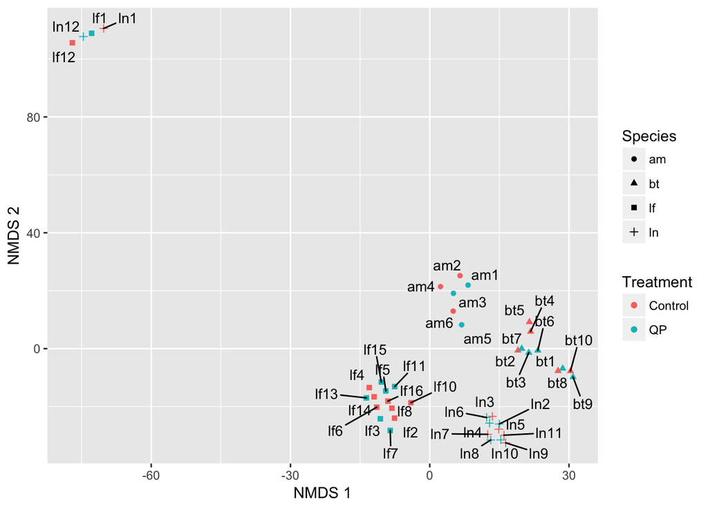

```r
set.seed(1) # nmds involves random numbers, so make this plot reproducible
expression.data <- make.OGGs(c("am", "bt", "ln", "lf"))[[1]]
treatments <- tbl(my_db, "treatments") %>% as.data.frame()

shhh <- capture.output(nmds.output <- dist(expression.data) %>% nmds())
data.frame(id = rownames(expression.data), nmds.output$conf[[length(nmds.output$conf)]], stringsAsFactors = F) %>%
  left_join(treatments, by = "id") %>%
  rename(Species = species, Treatment = treatment) %>%
  ggplot(aes(X1,X2, shape = Species)) +
  geom_point(aes(colour = Treatment)) +
  geom_text_repel(aes(label = id), size=3.6) +
  xlab("NMDS 1") + ylab("NMDS 2")
```

**Figure S1**: After reducing the transcriptome data to two axes using non-metric multidimensional scaling, four *Lasius* samples are clear outliers.

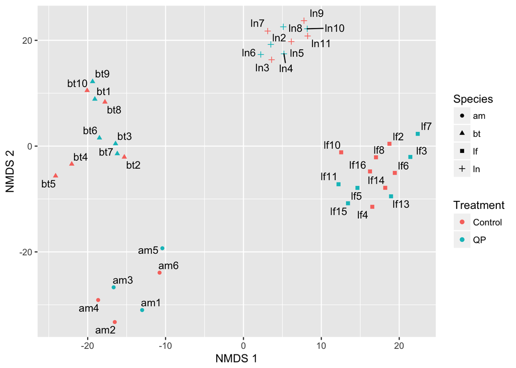

```r
set.seed(1) # nmds involves random numbers, so make this plot reproducible
expression.data <- make.OGGs(c("am", "bt", "ln", "lf"), bad.samples = bad.samples)[[1]]

shhh <- capture.output(nmds.output <- dist(expression.data) %>% nmds())
data.frame(id = rownames(expression.data),
           nmds.output$conf[[length(nmds.output$conf)]],
           stringsAsFactors = F) %>%
  left_join(treatments, by = "id") %>%
  rename(Species = species, Treatment = treatment) %>%
  ggplot(aes(X1,X2)) +
  geom_point(aes(shape = Species, colour = Treatment)) +
  geom_text_repel(aes(label = id), size=3.6) +
  xlab("NMDS 1") + ylab("NMDS 2")
```

**Figure S2**: With the four problematic samples removed, the samples cluster according to species with no obvious outliers.

## Table of sample sizes

**Table S1**: Number of sequencing libraries for each combination of species and treatment, after removing the four problematic libraries. Each library was prepared from a pool of workers, taken from the same colony.

```r
sample.size.table <- treatments[treatments$id %in% rownames(expression.data),] %>%
  group_by(species, treatment) %>%
  summarise(n = n()) %>% as.data.frame()
names(sample.size.table) <- c("Species", "Treatment", "Number of RNAseq libraries")
sample.size.table %>% pander()
```

| Species | Treatment | Number of RNAseq libraries |
| --- | --- | --- |
| am | Control | 3 |
| am | QP | 3 |
| bt | Control | 5 |
| bt | QP | 5 |
| lf | Control | 7 |
| lf | QP | 6 |
| ln | Control | 5 |
| ln | QP | 5 |

## Lists of significantly differentially expressed genes

```r
apis.de <- suppressMessages(tbl(my_db, "ebseq_padj_gene_am") %>%
  select(gene, PostFC) %>%
    left_join(tbl(my_db, "bee_names")) %>%
    collect() %>%
  mutate(PostFC = round(log2(PostFC), 3)) %>%
    select(gene, name, PostFC) %>%
    rename(Gene=gene, Name=name, Log2_FC = PostFC) %>%
    arrange(-abs(Log2_FC))) %>% as.data.frame()

bombus.de <- suppressMessages(tbl(my_db, "ebseq_padj_gene_bt") %>%
  select(gene, PostFC) %>%
    left_join(tbl(my_db, "bt2am") %>% rename(gene=bt)) %>%
    left_join(tbl(my_db, "bee_names") %>% rename(am=gene)) %>%
    collect() %>%
   mutate(PostFC = round(log2(PostFC), 3), name = replace(name, is.na(name), " "),
          am = replace(am, is.na(am), " ")) %>%
  select(gene, am, name, PostFC) %>%
    rename(Gene=gene, Apis_BLAST=am, Name=name, Log2_FC = PostFC) %>%
    arrange(-abs(Log2_FC))) %>% as.data.frame()

flavus.de <- suppressMessages(tbl(my_db, "ebseq_padj_gene_lf") %>%
  select(gene, PostFC) %>%
    left_join(tbl(my_db, "lf2am") %>% rename(gene=lf)) %>%
    left_join(tbl(my_db, "bee_names") %>% rename(am=gene)) %>%
    collect() %>%
   mutate(PostFC = round(log2(PostFC), 3), name = replace(name, is.na(name), " "),
          am = replace(am, is.na(am), " ")) %>%
  select(gene, am, name, PostFC) %>%
    rename(Gene=gene, Apis_BLAST=am, Name=name, Log2_FC = PostFC) %>%
    arrange(-abs(Log2_FC))) %>% as.data.frame()

niger.de <- suppressMessages(tbl(my_db, "ebseq_padj_gene_ln") %>%
  select(gene, PostFC) %>%
    left_join(tbl(my_db, "ln2am") %>% rename(gene=ln)) %>%
    left_join(tbl(my_db, "bee_names") %>% rename(am=gene)) %>%
    collect() %>%
   mutate(PostFC = round(log2(PostFC), 3), name = replace(name, is.na(name), " "),
          am = replace(am, is.na(am), " ")) %>%
  select(gene, am, name, PostFC) %>%
    rename(Gene=gene, Apis_BLAST=am, Name=name, Log2_FC = PostFC) %>%
    arrange(-abs(Log2_FC))) %>% as.data.frame()

names(apis.de) <- gsub("_", " ", names(apis.de))
names(bombus.de) <- gsub("_", " ", names(bombus.de))
names(flavus.de) <- gsub("_", " ", names(flavus.de))
names(niger.de) <- gsub("_", " ", names(niger.de))
```

### DE genes for *Apis mellifera*

**Table S2**: List of the 322 significantly differentially expressed genes (EBseq; p < 10<sup>-5</sup>) in *Apis mellifera*, listed in order of fold change in gene expression on a Log$_2$ scale. Positive fold change values indicate higher expression in the control, while negative values indicate higher expression in the queen pheromone treatment.

```r
kable.table(apis.de)
```

| Gene | Name | Log2 FC |
| --- | --- | --- |
| GB55204 | Major royal jelly protein 3 | 6.480 |
| GB51373 | bypass of stop codon protein 1-like | 5.385 |
| GB50604 | uncharacterized protein LOC724113 | 3.775 |
| 102655911 | uncharacterized protein LOC102655911 | -3.376 |
| GB49819 | branched-chain-amino-acid aminotransferase, cytosolic-like | 2.657 |
| 102656917 | uncharacterized LOC102656917, transcript variant X1 | 2.609 |
| GB54417 | dehydrogenase/reductase SDR family member 11-like isoform X1 | 2.242 |
| GB45565 | chymotrypsin-2 | 2.052 |
| GB53886 | protein G12-like isoform X4 | 1.983 |
| 100576536 | uncharacterized protein LOC100576536 | 1.945 |
| GB41540 | venom carboxylesterase-6-like | -1.721 |
| GB54690 | uncharacterized protein LOC408547 | -1.583 |
| GB54150 | uncharacterized protein LOC408462 | -1.560 |
| GB43639 | uncharacterized protein LOC100577506 isoform X1 | -1.557 |
| GB49548 | serine/threonine-protein phosphatase 2B catalytic subunit 3-like isoform X11 | -1.455 |
| GB49878 | probable cytochrome P450 6a14 isoformX1 | 1.393 |
| GB53414 | serine/threonine-protein kinase ICK-like isoform X2 | 1.357 |
| 102654781 | protein G12-like | 1.324 |
| 102656058 | uncharacterized protein PF11_0213-like | -1.311 |
| GB53957 | U6 snRNA-associated Sm-like protein LSm1-like | 1.276 |
| GB50413 | protein TBRG4-like isoform X1 | -1.261 |
| 102653931 | uncharacterized LOC102653931, transcript variant X2 | -1.258 |
| GB53876 | interaptin-like | -1.209 |
| GB42705 | protein archease-like | 1.184 |
| 101664701 | PI-PLC X domain-containing protein 1-like isoform X1 | 1.143 |
| GB42523 | uncharacterized LOC100577781, transcript variant X2 | -1.130 |
| 102654405 | protein G12-like | 1.115 |
| 100578075 | uncharacterized LOC100578075 | -1.110 |
| GB52251 | multifunctional protein ADE2, transcript variant X2 | 1.088 |
| GB40764 | uncharacterized protein LOC414021 isoform X7 | -1.086 |

[output cut: 292 more lines]

### DE genes for *Bombus terrestris*

**Table S3**: The single differentially expressed gene (EBseq; p < 10<sup>-5</sup>) in *Bombus terrestris*. Positive fold change values indicate higher expression in the control, while negative values indicate higher expression in the queen pheromone treatment. The second and third columns give the best BLAST hit for this gene in *A. mellifera* plus the name of the *A. mellifera* putative ortholog.

```r
kable(bombus.de, "html") %>%
  kable_styling()
```

| Gene | Apis BLAST | Name | Log2 FC |
| --- | --- | --- | --- |
| 100648170 | GB48391 | mucin-2-like | 1.071 |

### DE genes for *Lasius flavus*

**Table S4**: List of the 290 significantly differentially expressed genes (EBseq; p < 10<sup>-5</sup>) in *Lasius flavus*, listed in order of fold change in gene expression on a Log$_2$ scale. Positive fold change values indicate higher expression in the control, while negative values indicate higher expression in the queen pheromone treatment. The second and third columns give the best BLAST hit for this gene in *A. mellifera* plus the name of the *A. mellifera* putative ortholog.

```r
kable.table(flavus.de)
```

| Gene | Apis BLAST | Name | Log2 FC |
| --- | --- | --- | --- |
| TRINITY_DN19074_c0_g2 | GB43902 | hexaprenyldihydroxybenzoate methyltransferase, mitochondrial-like | 7.514 |
| TRINITY_DN2701_c0_g1 | GB52729 | aspartate–tRNA ligase, cytoplasmic | 7.481 |
| TRINITY_DN14108_c0_g2 |  |  | 7.468 |
| TRINITY_DN36041_c0_g1 |  |  | 6.629 |
| TRINITY_DN13621_c0_g1 |  |  | 6.549 |
| TRINITY_DN18780_c0_g2 |  |  | -6.440 |
| TRINITY_DN14430_c0_g1 |  |  | 6.278 |
| TRINITY_DN32671_c0_g2 |  |  | 6.121 |
| TRINITY_DN14910_c0_g1 | XP_016769216.1 |  | 5.800 |
| TRINITY_DN19071_c0_g1 |  |  | -5.776 |
| TRINITY_DN5663_c0_g2 | XP_006568418.2 |  | -5.365 |
| TRINITY_DN13527_c1_g3 |  |  | 5.259 |
| TRINITY_DN2506_c0_g2 |  |  | 5.133 |
| TRINITY_DN9902_c0_g2 |  |  | 5.069 |
| TRINITY_DN6503_c0_g3 | 551397 | 28S ribosomal protein S18a, mitochondrial isoform 2 | 5.044 |
| TRINITY_DN10699_c0_g1 |  |  | 4.901 |
| TRINITY_DN5102_c0_g1 | XP_016771437.1 |  | 4.901 |
| TRINITY_DN6994_c0_g1 |  |  | 4.859 |
| TRINITY_DN13376_c3_g2 |  |  | 4.858 |
| TRINITY_DN9565_c0_g3 | GB45250 | uncharacterized protein LOC409595 | 4.811 |
| TRINITY_DN1013_c0_g1 | GB52059 | eukaryotic translation initiation factor 4H-like isoform X1 | 4.709 |
| TRINITY_DN11616_c0_g1 |  |  | 4.696 |
| TRINITY_DN1845_c0_g2 | GB52253 | protein PRRC2C-like isoform X2 | 4.658 |
| TRINITY_DN7242_c0_g1 |  |  | -4.646 |
| TRINITY_DN31547_c0_g3 |  |  | 4.613 |
| TRINITY_DN13376_c3_g3 |  |  | 4.569 |
| TRINITY_DN6298_c0_g3 |  |  | 4.553 |
| TRINITY_DN2720_c0_g2 |  |  | -4.522 |
| TRINITY_DN2583_c0_g2 |  |  | 4.460 |
| TRINITY_DN24980_c0_g3 |  |  | -4.393 |

[output cut: 260 more lines]

### DE genes for *Lasius niger*

**Table S5**: List of the 135 significantly differentially expressed genes (EBseq; p < 10<sup>-5</sup>) in *Lasius niger*, listed in order of fold change in gene expression on a Log$_2$ scale. Positive fold change values indicate higher expression in the control, while negative values indicate higher expression in the queen pheromone treatment. The second and third columns give the best BLAST hit for this gene in *A. mellifera* plus the name of the *A. mellifera* putative ortholog.

```r
kable.table(niger.de)
```

| Gene | Apis BLAST | Name | Log2 FC |
| --- | --- | --- | --- |
| XLOC_001009 |  |  | 5.916 |
| RF55_9944 | GB55171 | major royal jelly protein 1 isoform X1 | 5.060 |
| RF55_873 | XP_016773511.1 |  | 4.638 |
| XLOC_000784 |  |  | 3.626 |
| RF55_874 | XP_016766165.1 |  | 3.550 |
| XLOC_016588 |  |  | 3.077 |
| RF55_9436 |  |  | 2.813 |
| RF55_3510 | GB53672 | failed axon connections isoform X2 | -2.471 |
| RF55_15864 |  |  | -2.439 |
| XLOC_020552 |  |  | 2.437 |
| RF55_783 |  |  | 2.206 |
| RF55_6001 |  |  | -2.150 |
| XLOC_013573 |  |  | 2.150 |
| RF55_4870 | XP_006563262.2 |  | -2.031 |
| XLOC_022706 |  |  | -1.091 |
| RF55_7689 | XP_003250465.2 |  | -1.030 |
| RF55_19841 | GB52590 | fatty acid synthase-like isoform 1 | -1.015 |
| RF55_21338 | GB52590 | fatty acid synthase-like isoform 1 | -0.923 |
| RF55_13568 | XP_006571191.2 |  | 0.882 |
| RF55_2210 | GB49869 | microsomal triglyceride transfer protein large subunit isoform X1 | -0.879 |
| RF55_6639 | GB48784 | cytochrome c | 0.779 |
| RF55_15245 | GB43617 | uncharacterized membrane protein DDB_G0293934-like isoform X1 | 0.734 |
| RF55_14443 | GB51356 | cytochrome P450 4G11 | 0.726 |
| RF55_5140 | XP_016767978.1 |  | 0.656 |
| XLOC_003947 |  |  | 0.655 |
| XLOC_019296 |  |  | -0.643 |
| XLOC_005895 |  |  | -0.625 |
| XLOC_010120 |  |  | 0.619 |
| RF55_3431 | GB47849 | pyrroline-5-carboxylate reductase 2-like isoform X2 | 0.611 |
| RF55_6542 | GB52074 | 6-phosphogluconate dehydrogenase, decarboxylating | -0.603 |

[output cut: 105 more lines]

## Genes that are differentially expressed in multiple species

In the first pair of tables, we have simply listed the genes that showed statistically significant differential expression in two or more species. This method makes few false positives, but it likely misses many of true overlaps because our study has modest power to detect differential expression.

```r
# Define a function to test whether the overlap of two sets of differentially expressed genes,
# drawn from a common pool (e.g. all the orthologs that were tested), is higher or lower than expected
# Inspiration for this code: https://stats.stackexchange.com/questions/10328/using-rs-phyper-to-get-the-probability-of-list-overlap
overlap.hypergeometric.test <- function(n.overlaps, num.sig1, num.sig2, num.genes, species){
  p.smaller <- phyper(n.overlaps, num.sig1, num.genes - num.sig1, num.sig2)
  p.higher <- 1 - phyper(n.overlaps - 1, num.sig1, num.genes - num.sig1, num.sig2)
  output <- data.frame(Species = species,
                       Test = c("Overlap is lower than expected:",
                                  "Overlap is higher than expected:"),
                       p = c(p.smaller, p.higher))
  output[output$p == min(output$p), ]
}



# Apis and flavus
af.oggs <- make.OGGs(c("am", "lf"))[[2]] # Get the orthologous gene list
n.am <- (tbl(my_db, "ebseq_padj_gene_am") %>%
           filter(gene %in% af.oggs$am) %>%
           summarise(n=n()) %>%
           as.data.frame())[1,1] # Count the number of diff expressed genes that appear in the OGG list
n.lf <- (tbl(my_db, "ebseq_padj_gene_lf") %>%
           filter(gene %in% af.oggs$lf) %>% summarise(n=n()) %>%
           as.data.frame())[1,1]
num.oggs.af <- nrow(af.oggs) # Count the orthologous genes
af.oggs <- suppressMessages(
  af.oggs %>%
    filter(am %in% (tbl(my_db, "ebseq_padj_gene_am") %>%
                      as.data.frame())[,1],
           lf %in% (tbl(my_db, "ebseq_padj_gene_lf") %>%
                      as.data.frame())[,1]) %>%
    mutate(Species = "Apis and L. flavus") %>%
    left_join(tbl(my_db, "ebseq_gene_am") %>%
                select(gene, PostFC) %>%
                rename(am=gene), copy=T) %>%
    rename(`Apis FC` = PostFC) %>%
    left_join(tbl(my_db, "ebseq_gene_lf") %>%
                select(gene, PostFC) %>%
                rename(lf=gene), copy=T) %>%
    rename(`L. flavus FC` = PostFC) %>%
    left_join(tbl(my_db, "bee_names") %>%
                rename(am=gene), copy=T))
num.overlap.af <- nrow(af.oggs) # Count the overlaps
test1 <- overlap.hypergeometric.test(num.overlap.af,
                                     n.am, n.lf,
                                     num.oggs.af,
                                     "Apis and L. flavus") # Run the hypergeometric test


# Apis and niger
an.oggs <- make.OGGs(c("am", "ln"))[[2]] # Get the orthologous gene list
n.am <- (tbl(my_db, "ebseq_padj_gene_am") %>%
           filter(gene %in% an.oggs$am) %>%
           summarise(n=n()) %>% as.data.frame())[1,1] # Count the number of diff expressed genes that appear in the OGG list
n.ln <- (tbl(my_db, "ebseq_padj_gene_ln") %>%
           filter(gene %in% an.oggs$ln) %>%
           summarise(n=n()) %>% as.data.frame())[1,1]
num.oggs.an <- nrow(an.oggs) # Count the orthologous genes
an.oggs <- suppressMessages(
  an.oggs %>%
    filter(am %in% (tbl(my_db, "ebseq_padj_gene_am") %>% as.data.frame())[,1],
           ln %in% (tbl(my_db, "ebseq_padj_gene_ln") %>% as.data.frame())[,1]) %>%
    mutate(Species = "Apis and L. niger") %>%
    left_join(tbl(my_db, "ebseq_gene_am") %>%
                select(gene, PostFC) %>%
                rename(am=gene), copy=T) %>%
    rename(`Apis FC` = PostFC) %>%
    left_join(tbl(my_db, "ebseq_gene_ln") %>%
                select(gene, PostFC) %>%
                rename(ln=gene), copy=T) %>%
    rename(`L. niger FC` = PostFC) %>%
    left_join(tbl(my_db, "bee_names") %>%
                rename(am=gene), copy=T))
num.overlap.an <- nrow(an.oggs) # Count the overlaps
test2 <- overlap.hypergeometric.test(num.overlap.an, n.am, n.ln, num.oggs.an, "Apis and L. niger") # Run the hypergeometric test

# flavus and niger
fn.oggs <- make.OGGs(c("lf", "ln"))[[2]] # Get the orthologous gene list
n.lf <- (tbl(my_db, "ebseq_padj_gene_lf") %>%
           filter(gene %in% fn.oggs$lf) %>%
           summarise(n=n()) %>% as.data.frame())[1,1] # Count the number of diff expressed genes that appear in the OGG list
n.ln <- (tbl(my_db, "ebseq_padj_gene_ln") %>%
           filter(gene %in% fn.oggs$ln) %>%
           summarise(n=n()) %>% as.data.frame())[1,1]
num.oggs.fn <- nrow(fn.oggs) # Count the orthologous genes
fn.oggs <- suppressMessages(
  fn.oggs %>% filter(ln %in% (tbl(my_db, "ebseq_padj_gene_ln") %>% as.data.frame())[,1],
                     lf %in% (tbl(my_db, "ebseq_padj_gene_lf") %>% as.data.frame())[,1]) %>%
    mutate(Species = "L. flavus and L. niger") %>%
    left_join(tbl(my_db, "ebseq_gene_lf") %>%
                select(gene, PostFC) %>%
                rename(lf=gene), copy=T) %>%
    rename(`L. flavus FC` = PostFC) %>%
    left_join(tbl(my_db, "ebseq_gene_ln") %>%
                select(gene, PostFC) %>%
                rename(ln=gene), copy=T) %>%
    rename(`L. niger FC` = PostFC) %>%
    left_join(tbl(my_db, "lf2am"), copy=T) %>%
    left_join(tbl(my_db, "bee_names") %>%
                rename(am=gene), copy=T))
num.missing <- sum(is.na(fn.oggs$name))
fn.oggs$name[is.na(fn.oggs$name)] <- paste("Unknown gene", 1:num.missing)
num.overlap.fn <- nrow(fn.oggs) # Count the overlaps
test3 <- overlap.hypergeometric.test(num.overlap.fn,
                                     n.lf, n.ln,
                                     num.oggs.fn,
                                     "L. flavus and L. niger") # Run the hypergeometric test


overlaps <- suppressMessages(
  data.frame(name = unique(c(af.oggs$name, an.oggs$name, fn.oggs$name)),
             stringsAsFactors = F) %>%
    left_join(rbind(af.oggs %>% select(name, starts_with("Apis")),
                    an.oggs %>% select(name, starts_with("Apis")))) %>%
    left_join(rbind(af.oggs %>% select(name, ends_with("flavus FC")),
                    fn.oggs %>% select(name, ends_with("flavus FC")))) %>%
    left_join(rbind(an.oggs %>% select(name, ends_with("niger FC")),
                    fn.oggs %>% select(name, ends_with("niger FC")))) %>% distinct())
overlaps <- rbind(overlaps[overlaps$name == "myosin light chain alkali-like isoform X5", ],
                  overlaps[overlaps$name != "myosin light chain alkali-like isoform X5", ])
overlaps$Consistent <- "Yes"
overlaps$Consistent[apply(overlaps[,2:4],1,min,na.rm=T)<1 & apply(overlaps[,2:4],1,max,na.rm=T)>1] <- "No"
for(i in 2:4) overlaps[,i] <- format(round(log2(overlaps[,i]), 3), nsmall = 3)
overlaps[overlaps == "    NA"] <- " "
rownames(overlaps) <- NULL

overlap.p.values <- rbind(test1, test2, test3)
rownames(overlap.p.values) <- NULL

all.overlaps <- c(af.oggs$am, an.oggs$am, fn.oggs$am[!is.na(fn.oggs$am)]) %>% unique
```

```r
kable.table(overlaps)
```

| name | Apis FC | L. flavus FC | L. niger FC | Consistent |
| --- | --- | --- | --- | --- |
| myosin light chain alkali-like isoform X5 | 0.444 | 0.372 | 0.350 | Yes |
| proteasome subunit beta type-5-like | 0.484 | -0.434 |  | No |
| probable Bax inhibitor 1 | 0.447 | -0.167 |  | No |
| intracellular protein transport protein USO1 isoform X2 | -0.684 | 0.445 |  | No |
| muscle M-line assembly protein unc-89 isoform X5 | -0.526 | 0.213 |  | No |
| transitional endoplasmic reticulum ATPase TER94 | 0.544 | -0.306 |  | No |
| actin related protein 1 | 0.762 |  | 0.083 | Yes |
| tubulin alpha-1 chain-like | 0.773 |  | -0.251 | No |
| Unknown gene 1 |  | -0.088 | 0.048 | No |
| uncharacterized protein LOC100576760 isoform X2 |  | -0.066 | -0.163 | Yes |
| myosin regulatory light chain 2 |  | 0.258 | 0.279 | Yes |
| NADP-dependent malic enzyme isoform X3 |  | 0.040 | -0.067 | No |
| transketolase isoform 1 |  | -0.248 | -0.342 | Yes |
| troponin T, skeletal muscle |  | 0.374 | 0.185 | Yes |
| uncharacterized protein LOC551958 |  | 0.511 | -0.108 | No |
| probable cytochrome P450 304a1 |  | -0.224 | 0.470 | No |
| Unknown gene 2 |  | 0.181 | 0.092 | Yes |
| WD repeat-containing protein 37-like isoform X4 |  | 0.083 | 0.407 | Yes |
| Unknown gene 3 |  | -0.131 | -0.211 | Yes |
| uncharacterized protein LOC409805 isoform X3 |  | 0.444 | 0.415 | Yes |
| ADP/ATP translocase |  | 0.054 | 0.154 | Yes |
| peroxidase isoformX2 |  | 0.104 | 0.008 | Yes |
| neurofilament heavy polypeptide-like isoform X2 |  | 0.377 | 0.069 | Yes |
| fatty acid synthase-like isoform 1 |  | -0.926 | -1.015 | Yes |
| LOW QUALITY PROTEIN: counting factor associated protein D-like |  | -0.294 | -0.097 | Yes |
| myophilin-like |  | 0.226 | 0.216 | Yes |
| Unknown gene 4 |  | 0.039 | 0.254 | Yes |
| hexaprenyldihydroxybenzoate methyltransferase, mitochondrial-like |  | 7.514 | -0.368 | No |
| arginine kinase isoform X2 |  | 0.441 | 0.141 | Yes |
| heat shock protein cognate 4 |  | -0.369 | -0.432 | Yes |
| tropomyosin-1-like |  | 0.116 | 0.393 | Yes |
| 6-phosphogluconate dehydrogenase, decarboxylating |  | -0.445 | -0.603 | Yes |
| transaldolase |  | -0.044 | 0.034 | No |
| superoxide dismutase 1 |  | -0.175 | -0.324 | Yes |
| translation elongation factor 2-like isoform 1 |  | -0.079 | 0.004 | No |
| very-long-chain enoyl-CoA reductase-like |  | -0.201 | -0.431 | Yes |
| Unknown gene 5 |  | 0.350 | 0.359 | Yes |

**Table S7**: The overlap between the lists of significantly differently expressed orthologous genes was significantly higher than expected for *L. flavus* and *L. niger*, suggesting that queen pheromone has conserved effects on gene expression between these two species (results based on a hypergeometric test). For the other two species pairs, the number of overlapping genes was not higher or lower than expected under the null hypothesis that queen pheromone affects a random set of genes in each species.

```r
pander(overlap.p.values, split.cell = 40, split.table = Inf)
```

| Species | Test | p |
| --- | --- | --- |
| Apis and L. flavus | Overlap is higher than expected: | 0.1915 |
| Apis and L. niger | Overlap is higher than expected: | 0.2616 |
| L. flavus and L. niger | Overlap is higher than expected: | 0 |

```r
most.pheromone.sensitive.genes <- function(){
  ngenes.list <- (1:5)*100 # 100 - 500
  dat <- list()
  for(i in 1: length(ngenes.list)){
    ngenes <- ngenes.list[i]

    # Get the top n genes from Apis, as ranked by the absolute value for the log-fold change in response to pheromone
    g1 <- tbl(my_db, "ebseq_gene_am") %>% collect() %>%
      select(gene, PostFC) %>%
      mutate(PostFC = log2(PostFC)) %>% left_join(tbl(my_db, "bee_names"), copy=TRUE, by = "gene") %>%
      arrange(-abs(PostFC)) %>% head(ngenes) %>% .$name %>% unique()

    # Do the same for genes from non-Apis species, and get the Apis names for the top BLAST hits in the Apis genome
    g2 <- tbl(my_db, "ebseq_gene_bt") %>%
      select(gene, PostFC) %>%
      left_join(tbl(my_db, "bt2am") %>%
                  rename(gene = bt) %>%
                  select(-evalue), by = "gene") %>%
      collect() %>% mutate(PostFC = log2(PostFC)) %>%
      arrange(-abs(PostFC)) %>%
      rename(bt = gene, gene = am) %>%
      left_join(tbl(my_db, "bee_names"), copy=TRUE, by = "gene") %>%
      filter(!is.na(name)) %>% head(ngenes) %>% .$name %>% unique()

    g3 <- tbl(my_db, "ebseq_gene_lf") %>%
      select(gene, PostFC) %>%
      left_join(tbl(my_db, "lf2am") %>%
                  rename(gene = lf) %>%
                  select(-evalue), by = "gene") %>%
      collect() %>% mutate(PostFC = log2(PostFC)) %>%
      arrange(-abs(PostFC)) %>%
      rename(lf = gene, gene = am) %>%
      left_join(tbl(my_db, "bee_names"), copy=TRUE, by = "gene") %>%
      filter(!is.na(name)) %>% head(ngenes) %>% .$name %>% unique()

    g4 <-tbl(my_db, "ebseq_gene_ln") %>%
      select(gene, PostFC) %>%
      left_join(tbl(my_db, "ln2am") %>%
                  rename(gene = ln) %>%
                  select(-evalue), by = "gene") %>%
      collect() %>% mutate(PostFC = log2(PostFC)) %>%
      arrange(-abs(PostFC)) %>%
      rename(ln = gene, gene = am) %>%
      left_join(tbl(my_db, "bee_names"), copy=TRUE, by = "gene") %>%
      filter(!is.na(name)) %>% head(ngenes) %>% .$name %>% unique()

    # Count the number of intersections, and find gene names that appear in 3 or 4 species using the venn() function
    venn.diagram <- venn(list(am=g1, bt=g2, lf=g3, ln=g4), show.plot=FALSE)
    three.plus <- attr(venn.diagram, "intersections")[str_count(names(attr(venn.diagram, "intersections")), ":") > 1] %>%
      unlist %>% unname %>% unique %>% sort
    four <- attr(venn.diagram, "intersections")[str_count(names(attr(venn.diagram, "intersections")), ":") > 2] %>%
      unlist %>% unname %>% unique %>% sort
    three <- three.plus[!(three.plus %in% four)]
    if(length(three) + length(four) > 0) dat[[i]] <- data.frame(Name = c(three, four),
                                                                count = c(rep("x3 species", length(three)),
                                                                          rep("4 species", length(four))),
                                                                nGenes = ngenes, stringsAsFactors = FALSE)
  }
  dat <- do.call("rbind", dat) %>%
    arrange(count, nGenes, Name) %>%
    distinct(paste(Name, count), .keep_all = TRUE) %>%
    select(Name, count, nGenes) %>%
    mutate(count = replace(count, count == "x3 species", "3 species"))

  names(dat) <- c("Name", "Appears in", "Size of gene set")
  dat
}
most.pheromone.sensitive.genes <- most.pheromone.sensitive.genes()
```

**Table S8**: List of genes that appear in the top *n*-most pheromone-sensitive genes for 3 or 4 species. To generate the table, we ranked genes by the absolute value of their log fold change in response to queen pheromone, then listed the gene names that appeared in 3-4 species. For non-*Apis* species, we found the gene names by comparison with the *Apis* genome by BLAST. This exercise was performed with *n* = 100, 200 … 500, and the third column lists the smallest *n* for which the gene in question appeared (for example, the gene *protein takeout-like* appeared for all 4 species when inspecting the top 200+ genes).

```r
kable(most.pheromone.sensitive.genes, "html") %>%
  kable_styling() %>%
  scroll_box(height = "300px")
```

| Name | Appears in | Size of gene set |
| --- | --- | --- |
| protein takeout-like | 4 species | 200 |
| glucose dehydrogenase [FAD, quinone] | 4 species | 300 |
| histone-lysine N-methyltransferase SETMAR-like | 4 species | 300 |
| serotonin receptor | 4 species | 500 |
| titin-like | 4 species | 500 |
| uncharacterized protein LOC102656088 | 4 species | 500 |
| histone-lysine N-methyltransferase SETMAR-like | 3 species | 200 |
| 2-oxoglutarate dehydrogenase, mitochondrial-like isoform X5 | 3 species | 300 |
| probable serine/threonine-protein kinase DDB_G0282963 isoform X4 | 3 species | 300 |
| titin-like | 3 species | 300 |
| elongation of very long chain fatty acids protein 6-like | 3 species | 400 |
| ligand-gated chloride channel homolog 3 precursor | 3 species | 400 |
| odorant receptor Or2-like | 3 species | 400 |
| putative odorant receptor 13a-like | 3 species | 400 |
| serotonin receptor | 3 species | 400 |
| trypsin-1 | 3 species | 400 |
| uncharacterized protein LOC100576902 | 3 species | 400 |
| uncharacterized protein LOC102655422 | 3 species | 400 |
| uncharacterized protein LOC102656088 | 3 species | 400 |
| metabotropic glutamate receptor 7 isoform X3 | 3 species | 500 |
| probable cytochrome P450 305a1 | 3 species | 500 |
| protein NPC2 homolog | 3 species | 500 |
| suppressor protein SRP40-like | 3 species | 500 |
| uncharacterized protein LOC100577132 | 3 species | 500 |
| uncharacterized protein LOC102656830 | 3 species | 500 |
| uncharacterized protein LOC724216 | 3 species | 500 |

## Most pheromone-sensitive genes are evolutionarily ancient

We defined a gene as “evolutionarily ancient” if it has an ortholog in at least one species from the other lineage (for example, we define ancient *A. mellifera* genes as those that have a reciprocal best BLAST hit in one or both *Lasius* species). Genes that were not detected by BLAST in the other lineage were defined as putatively lineage-specific (though many of them are likely to be conserved genes that we failed to identify as such, hence the word “putative”). Using a Chi-square test, we find that genes that are significantly differentially expressed in response to queen pheromone are more likely to be ancient than those that are not differentially exressed. This relationship holds for all three species for which we found differential expression, and for genes that were higher or lower in the pheromone treatment. The fact that we probably miscalssifed many genes as ancient vs lineage-specific means that the result is likely to be even stronger than suggested here.

```r
ancient.genes.test <- function(species){
 if(species == "am") ancient.genes <- c(make.OGGs(c("am", "lf"))[[2]]$am,
                                        make.OGGs(c("am", "ln"))[[2]]$am) %>% unique
 if(species == "bt") ancient.genes <- c(make.OGGs(c("bt", "lf"))[[2]]$bt,
                                        make.OGGs(c("bt", "ln"))[[2]]$bt) %>% unique
 if(species == "lf") ancient.genes <- c(make.OGGs(c("lf", "am"))[[2]]$lf,
                                        make.OGGs(c("lf", "bt"))[[2]]$lf) %>% unique
 if(species == "ln") ancient.genes <- c(make.OGGs(c("ln", "am"))[[2]]$ln,
                                        make.OGGs(c("ln", "bt"))[[2]]$am) %>% unique
 lab <- "Putatively bee-specific"
 if(species %in% c("lf", "ln")) lab <- "Putatively ant-specific"

 expression <- tbl(my_db, paste("ebseq_gene_", species, sep="")) %>%
   select(gene, PostFC) %>% collect() %>%
   mutate(age = lab, sig = "Non-sig") %>% as.data.frame()
 expression$age[expression$gene %in% ancient.genes] <- "Evolutionarily ancient"
 expression$sig[expression$gene %in% (tbl(my_db, paste("ebseq_padj_gene_", species, sep="")) %>%
                                        filter(PostFC < 1) %>% select(gene) %>% collect %>% .$gene)] <- "Up in QP"
 expression$sig[expression$gene %in% (tbl(my_db, paste("ebseq_padj_gene_", species, sep="")) %>%
                                        filter(PostFC > 1) %>% select(gene) %>% collect %>% .$gene)] <- "Up in Control"
  tab <- table(expression$sig, expression$age)
  chisq.test(tab) %>% print
  percent <- paste("(", (100*tab / rowSums(tab)) %>% round(1) %>% format(nsmall=1), "%)", sep = "")
  for(i in 1:2) {for(j in 1:3) tab[j,i] <- paste(tab[j,i], percent[j + (i-1)*3])}
  tab %>% pander
}
```

### *Apis mellifera*

```r
ancient.genes.test("am")
```

```
##
##  Pearson's Chi-squared test
##
## data:  tab
## X-squared = 43.581, df = 2, p-value = 3.439e-10
```

|  | Evolutionarily ancient | Putatively bee-specific |
| --- | --- | --- |
| **Non-sig** | 5461 (47.4%) | 6061 (52.6%) |
| **Up in Control** | 150 (70.1%) | 64 (29.9%) |
| **Up in QP** | 54 (50.0%) | 54 (50.0%) |

### *Lasius flavus*

```r
ancient.genes.test("lf")
```

```
##
##  Pearson's Chi-squared test
##
## data:  tab
## X-squared = 344.8, df = 2, p-value < 2.2e-16
```

|  | Evolutionarily ancient | Putatively ant-specific |
| --- | --- | --- |
| **Non-sig** | 7167 (14.4%) | 42488 (85.6%) |
| **Up in Control** | 76 (41.5%) | 107 (58.5%) |
| **Up in QP** | 72 (67.3%) | 35 (32.7%) |

### *Lasius niger*

```r
ancient.genes.test("ln")
```

```
##
##  Pearson's Chi-squared test
##
## data:  tab
## X-squared = 16.823, df = 2, p-value = 0.0002223
```

|  | Evolutionarily ancient | Putatively ant-specific |
| --- | --- | --- |
| **Non-sig** | 4524 (23.0%) | 15129 (77.0%) |
| **Up in Control** | 30 (42.9%) | 40 (57.1%) |
| **Up in QP** | 19 (29.2%) | 46 (70.8%) |

## Correlations in pheromone-sensitive gene expression across species

These tests ask if genes that are up-regulated in the queen pheromone treatment in one species are also up (or down) regulated in another. These tests used fold expression changes calculated using ebseq, after omitting the four irregular Lasius samples. The advantage of these tests is that one is not limited to the set of ‘significant’ genes, which discards a lot of information based on an arbitrary p-value threshold.

#### Define function to retrieve fold-change expression data (calculated with ebseq) for genes that are each other’s reciprocal best BLAST

```r
get.fc.for.pair.species <- function(species1, species2){
  query <- 'SELECT rbb.X AS X_gene, rbb.Y AS Y_gene, ebseq_gene_X.PostFC AS X_fc, ebseq_gene_Y.PostFC AS Y_fc FROM ebseq_gene_X
             JOIN
  (SELECT Y2X.X, Y2X.Y  FROM Y2X
  JOIN X2Y
  ON Y2X.Y = X2Y.Y AND Y2X.X = X2Y.X  ) AS rbb
  ON rbb.X = ebseq_gene_X.gene
  JOIN ebseq_gene_Y
  ON rbb.Y = ebseq_gene_Y.gene'

  query <- str_replace_all(query, "X", species1)
  query <- str_replace_all(query, "Y", species2)
  dbGetQuery(db, query)
}
```

#### Make a table and a plot of the correlations for each pair of species

**Table S9**: Results of Spearman’s rank correlations, testing whether the absolute log fold difference between pheromones treatments is correlated for a given pair of species. Positive coefficients (rho) indicate that on average, orthologous genes have similar sensitivity to queen pheromones. The p-values have been corrected for multiple testing with the Benjamini-Hochberg method.

```r
species.combinations <- t(combn(c("am", "bt", "lf", "ln"), 2))
rho <- numeric(nrow(species.combinations))
p <- numeric(nrow(species.combinations))
for(i in 1:nrow(species.combinations)){
  fc.data <- get.fc.for.pair.species(species.combinations[i, 1],
                                     species.combinations[i,2])
  fc.data[,3:4] <- fc.data[,3:4] %>% log2 %>% abs # Log the fold changes - not that it matters for Spearman's!
  results <- suppressWarnings(with(fc.data, cor.test(fc.data[,3],
                                                     fc.data[,4], method="spearman"))) # Spearman's correlation
  rho[i] <- results$estimate
  p[i] <- results$p.value
}

species.combinations <- data.frame(Species1 = species.combinations[,1],
                                   Species2  = species.combinations[,2],
                                   rho = rho,
                                   p = p.adjust(p, method = "BH"), # adjust these p-vals for multiple testing
                                   sig = " ", stringsAsFactors = F)

species.combinations[species.combinations == "am"] <- "Apis mellifera"
species.combinations[species.combinations == "bt"] <- "Bombus terrestris"
species.combinations[species.combinations == "lf"] <- "Lasius flavus"
species.combinations[species.combinations == "ln"] <- "Lasius niger"

species.combinations$sig[species.combinations$p < 0.05] <- "*"
species.combinations$sig[species.combinations$p < 0.01] <- "**"
species.combinations$sig[species.combinations$p < 0.0001] <- "***"
# Make a table
species.combinations %>% mutate(rho = format(round(rho, 3), nsmall = 3)) %>% pander
```

| Species1 | Species2 | rho | p | sig |
| --- | --- | --- | --- | --- |
| Apis mellifera | Bombus terrestris | 0.136 | 3.232e-24 | *** |
| Apis mellifera | Lasius flavus | 0.100 | 1.478e-12 | *** |
| Apis mellifera | Lasius niger | 0.077 | 1.853e-07 | *** |
| Bombus terrestris | Lasius flavus | 0.159 | 3.112e-39 | *** |
| Bombus terrestris | Lasius niger | 0.127 | 2.282e-24 | *** |
| Lasius flavus | Lasius niger | 0.194 | 3.765e-61 | *** |

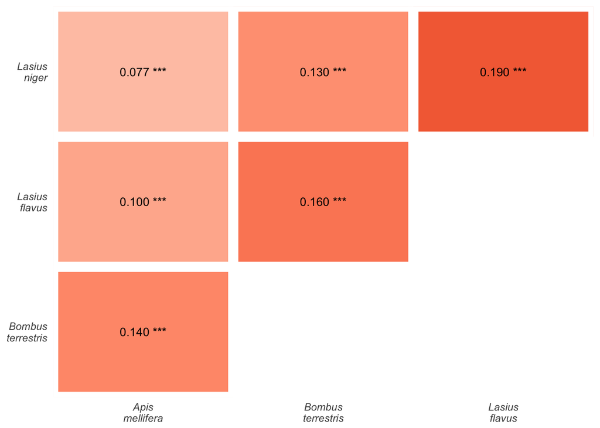

```r
# Make a figure
heat.map.figure <- species.combinations %>% ggplot(aes(Species1, Species2, fill=rho)) +
  geom_tile(colour="white", size=4) +
  scale_fill_gradient2(name = "Corr",
                       low = brewer.pal(9, "RdYlBu")[7],
                       mid = "white",
                       high = brewer.pal(9, "RdYlBu")[2]) +
  geom_text(aes(label = paste(format(signif(rho, 2), nsmall = 2), sig)), size = 3.5) +
  theme_bw() + theme(panel.grid = element_blank(),
                     panel.border = element_blank(),
                     axis.ticks = element_blank(),
                     axis.text = element_text(face = "italic"),
                     legend.position = "none") +
  xlab(NULL) + ylab(NULL) +
  scale_x_discrete(labels = c("Apis\nmellifera", "Bombus\nterrestris", "Lasius\nflavus"), expand = c(0,0)) +
  scale_y_discrete(labels = c("Bombus\nterrestris", "Lasius\nflavus", "Lasius\nniger"), expand = c(0,0))
heat.map.figure
```

```r
ggsave(heat.map.figure, file = "figures/Correlations heat map.pdf", height = 4, width=4.3)
```

## Identifying genes that splice differently following queen pheromone treatment

Many genes showed alternative splicing in all four species, with the great majority showing between 1 and 6 isoforms.

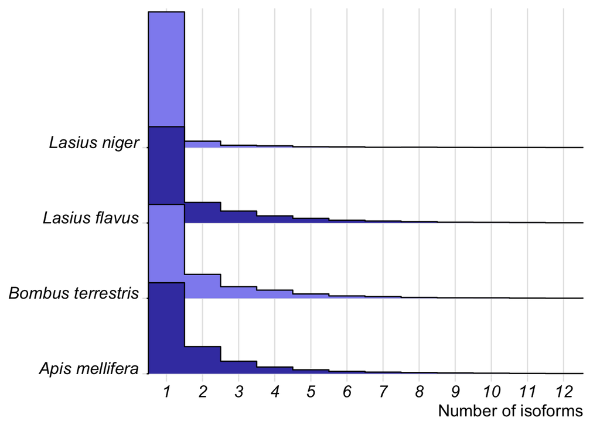

```r
rbind(my_db %>% tbl("isoforms_am") %>% collect %>% .$gene %>%
        table %>% melt %>% select(value) %>% mutate(sp = "Apis mellifera"),
      my_db %>% tbl("isoforms_bt") %>% collect %>% .$gene %>%
        table %>% melt %>% select(value) %>% mutate(sp = "Bombus terrestris"),
      my_db %>% tbl("isoforms_lf") %>% collect %>% .$gene %>%
        table %>% melt %>% select(value) %>% mutate(sp = "Lasius niger"),
      my_db %>% tbl("isoforms_ln") %>% collect %>% .$gene %>%
        table %>% melt %>% select(value) %>% mutate(sp = "Lasius flavus")) %>%
  as.data.frame() %>%
  ggplot(aes(x = value, y = sp, fill = sp)) +
  geom_joy(stat = "binline", binwidth=1) +
  coord_cartesian(xlim=c(1,12)) +
  scale_fill_cyclical(values = c("#4040B0", "#9090F0")) +
  scale_x_continuous(breaks = seq(1,12,by=1)) +
  scale_y_discrete(expand = c(0.01, 0)) +
  theme_joy() +
  xlab("Number of isoforms") + ylab(NULL) +
  theme(axis.text = element_text(face = "italic"))
```

**Figure S4**: Distribution of isoform numbers per gene for each of the four species.

```r
# Define a function to search for significantly alternatively spliced genes. We define these as genes that have at least two differentially expressed isoforms, where queen pheromone stimulates expresison of one isoform but surpresses expression of another

find.alternatively.spliced.genes <- function(species){

  # Write a database query with 'X' as a placeholder for the species name
  # We want to find genes in which at least two isoforms are differentially expressed in response to pheromones
  # Significant isoforms are listed in the ebseq_padj_isoform_X tables, so we count them and get the names of their genes
  query <- 'SELECT isoforms_X.gene, isoforms_X.isoform, PostFC FROM isoforms_X
JOIN
             (SELECT gene, COUNT(*) FROM ebseq_padj_isoform_X
             JOIN isoforms_X
             ON isoforms_X.isoform = ebseq_padj_isoform_X.isoform
             GROUP BY gene
             HAVING COUNT(*)>1 ) AS multiISO
             ON multiIso.gene = isoforms_X.gene
             JOIN ebseq_padj_isoform_X
             ON ebseq_padj_isoform_X.isoform = isoforms_X.isoform
             ORDER BY isoforms_X.gene'
  query <- str_replace_all(query, "X", species) # replace X with the species
  Splice <- dbGetQuery(db, query) # run the query

  # Find the highest and lowest fold change for the isoforms of each gene
  SpliceMin <- aggregate(Splice$PostFC, by=list(Splice$gene), FUN="min")
  SpliceMax <- aggregate(Splice$PostFC, by=list(Splice$gene), FUN="max")
  SpliceCompare <- merge(SpliceMin, SpliceMax, by = "Group.1")
  colnames(SpliceCompare) <- c("gene", "min", "max")

  # Define diff-spliced genes as those with both elevated and
  # repressed isoforms, when comparing control and pheromone-treated workers
  output <- data.frame(gene = SpliceCompare$gene[SpliceCompare$min < 1 & SpliceCompare$max > 1], stringsAsFactors = F)

  # Add the Apis mellifera ortholog, from one-way BLAST, if it's a non-Apis species
  if(species != "am"){
    orthologs <- tbl(my_db, paste(species, "2am", sep = "")) %>% select(-evalue) %>% collect(n=Inf) %>% as.data.frame()
    names(orthologs) <- c("gene", "Amel_ortholog")
    output <- left_join(output, orthologs, by = "gene")
    output <- left_join(output, tbl(my_db, "bee_names") %>%
                          rename(Amel_ortholog = gene), copy=T, by = "Amel_ortholog")
  }
  else output <- left_join(output, tbl(my_db, "bee_names"), by = "gene", copy = T)

  output[is.na(output)] <- " "

  # Remove the 'isoform X' part from the gene name, so it gives the name of the gene not the isoform
  output$name <- unlist(lapply(strsplit(output$name, split = " isoform "), function(x) x[1]))

  output <- left_join(output, SpliceCompare, by = "gene")

  output$min <- log2(output$min) # Log2 transform the fold changes
  output$max <- log2(output$max)
  output <- output %>% arrange(-(abs(min) + max)) # Arrange by effect size

  if(species == "am" | species == "bt") names(output) <- c("Gene", "Name", "Lowest FC", "Highest FC")
  else names(output) <- c("Gene", "Amel ortholog", "Name", "Lowest FC", "Highest FC")
  output
}
```

### Genes showing pheromone-induced alternative splicing in *A. mellifera*

**Table S10**: List of genes showing statistically significant pheromone-induced alternative splicing in *A. mellifera*. These genes were defined as those that have at least two isoforms that are differentially expressed following pheromone treatment with p < 10<sup>-5</sup>, and for which one isoform increases in expression while another decreases. The last two columns show the fold changes of the most down-regulated and most up-regulated isoforms, on a Log$_2$ scale.

```r
am.alt.splice <- find.alternatively.spliced.genes("am")
kable.table(am.alt.splice)
```

| Gene | Name | Lowest FC | Highest FC |
| --- | --- | --- | --- |
| GB44254 | uncharacterized protein LOC411586 | -10.2106382 | 7.3294705 |
| GB55598 | troponin I | -8.6184698 | 7.4257311 |
| GB55650 | ryanodine receptor 44F | -8.6521541 | 6.1211069 |
| GB42000 | cAMP-specific 3’,5’-cyclic phosphodiesterase, isoforms N/G | -7.8461925 | 6.4652082 |
| GB49567 | sestrin-1-like isoformX1 | -6.7384430 | 6.3303655 |
| GB46113 | uncharacterized protein LOC726188 | -6.7215768 | 6.2049532 |
| GB55237 | disco-interacting protein 2 | -6.4126080 | 5.7870758 |
| GB44556 | uncharacterized protein LOC411962 | -5.3193508 | 6.4264182 |
| GB50923 | serine-protein kinase ATM | -5.4981139 | 6.1549064 |
| GB50941 | phosphatidate phosphatase LPIN2-like | -6.1378916 | 5.3694436 |
| GB55848 | DNA ligase 1-like | -6.0254223 | 5.3645877 |
| GB42142 | nuclear hormone receptor FTZ-F1 | -6.0475859 | 5.2543590 |
| GB45259 | zinc finger protein 91-like | -5.7141149 | 5.4922565 |
| GB52595 | zinc finger and BTB domain-containing protein 20-like | -6.0058327 | 5.1479879 |
| GB55225 | sushi, von Willebrand factor type A, EGF and pentraxin domain-containing protein 1 | -3.5827048 | 7.3608415 |
| GB55102 | F-box only protein 28-like | -5.6780118 | 5.1328776 |
| GB42895 | trichohyalin-like | -6.0749616 | 4.6900449 |
| GB44373 | protein zyg-11 homolog B-like | -2.7153166 | 7.8600431 |
| GB49111 | neuropathy target esterase sws | -1.8617078 | 8.3596119 |
| GB46271 | protein BCL9 homolog | -3.1471390 | 6.9356291 |
| GB53431 | inositol hexakisphosphate kinase 2-like | -6.3417004 | 3.3365701 |
| GB44336 | protein couch potato-like | -2.1830854 | 7.3541749 |
| GB45277 | multidrug resistance-associated protein 4-like | -8.1135336 | 1.3365168 |
| GB40263 | dentin sialophosphoprotein-like | -3.0597817 | 6.2723878 |
| 725417 | uncharacterized protein LOC725417 | -2.8308639 | 6.1603441 |
| GB55517 | uncharacterized protein LOC410000 | -3.2763532 | 5.3768010 |
| GB55429 | CREB-regulated transcription coactivator 1-like | -5.3728279 | 3.1844409 |
| GB55998 | beta-1,4-N-acetylgalactosaminyltransferase bre-4 | -2.7284140 | 5.5956924 |
| GB52604 | LIM domain-binding protein 2-like | -2.2872276 | 5.8679044 |
| GB41734 | reversion-inducing-cysteine-rich protein with kazal motifs | -5.9697261 | 1.9393374 |
| GB49535 | calcium/calmodulin-dependent protein kinase II | -1.9949124 | 5.8059893 |
| GB45662 | conserved oligomeric Golgi complex subunit 4-like | -5.3583810 | 2.1410794 |
| GB40310 | uncharacterized protein LOC411575 | -0.9447237 | 6.4575407 |
| GB51117 | rho GTPase-activating protein 18-like | -0.9711563 | 6.3563951 |
| GB41129 | protein LMBR1L-like | -5.6199019 | 1.4425609 |
| GB44876 | uncharacterized protein LOC100576421 | -5.3652303 | 1.6410521 |
| GB50244 | NHL repeat-containing protein 2 | -0.9371409 | 5.9580141 |
| GB47138 | calcium-activated potassium channel slowpoke-like | -0.9035332 | 5.9504672 |
| GB50099 | uncharacterized abhydrolase domain-containing protein DDB_G0269086-like | -1.5085077 | 5.0811380 |
| GB41908 | PERQ amino acid-rich with GYF domain-containing protein CG11148-like | -1.0050181 | 5.5164280 |
| GB52999 | neurofilament heavy polypeptide-like | -2.7388052 | 3.6790149 |
| GB51651 | putative inorganic phosphate cotransporter-like | -5.4170376 | 0.9305746 |
| GB50877 | tyrosine-protein kinase Dnt | -2.5061716 | 3.1568560 |
| GB43220 | transcription termination factor 2 | -3.2229375 | 1.8337147 |
| GB40565 | ribosomal protein S6 kinase alpha-5 | -2.3132702 | 2.6623092 |
| GB55467 | neural cell adhesion molecule L1-like | -3.3341247 | 1.4565432 |
| GB48034 | protein numb-like, transcript variant X5 | -1.0127583 | 3.7699557 |
| GB55570 | transmembrane protein 53-like | -2.0692979 | 2.6556081 |
| GB49417 | PITH domain-containing protein GA19395-like | -2.1836294 | 2.2457448 |
| GB43282 | guanine nucleotide-binding protein G(q) subunit alpha-like | -2.3600303 | 2.0113196 |
| GB48573 | probable multidrug resistance-associated protein lethal(2)03659-like | -2.1285308 | 1.9867141 |
| GB50366 | uncharacterized protein LOC551450 | -0.8408050 | 1.1435481 |
| GB46121 | ubiquitin fusion degradation protein 1 homolog | -0.9511837 | 0.9182434 |
| GB52052 | venom carboxylesterase-6-like | -0.7021931 | 0.9102424 |

### Genes showing pheromone-induced alternative splicing in *L. flavus*

**Table S11**: List of genes showing statistically significant pheromone-induced alternative splicing in *L. flavus*. The table shows the same information as Table S10.

```r
lf.alt.splice<- find.alternatively.spliced.genes("lf")
kable.table(lf.alt.splice)
```

| Gene | Amel ortholog | Name | Lowest FC | Highest FC |
| --- | --- | --- | --- | --- |
| TRINITY_DN11346_c0_g1 | GB49250 | heme oxygenase | -9.1733822 | 4.2807355 |
| TRINITY_DN14030_c0_g1 | XP_016769715.1 |  | -4.5698062 | 6.1058670 |
| TRINITY_DN13728_c1_g1 | GB44606 | AMP deaminase 2-like | -5.6147192 | 4.2278104 |
| TRINITY_DN13759_c0_g1 | XP_016766389.1 |  | -3.7805082 | 5.5650278 |
| TRINITY_DN13897_c0_g1 | GB41293 | histone acetyltransferase KAT8 | -4.6420034 | 2.6858828 |
| TRINITY_DN14126_c1_g2 | GB43039 | restin homolog | -1.8789713 | 5.3598354 |
| TRINITY_DN12581_c0_g2 | XP_016767063.1 |  | -4.1075789 | 2.7973408 |
| TRINITY_DN14084_c0_g1 | XP_016772396.1 |  | -2.4056262 | 4.1607373 |
| TRINITY_DN13929_c0_g1 | GB53852 | paired amphipathic helix protein Sin3a | -2.0878837 | 4.4200505 |
| TRINITY_DN13956_c0_g1 | GB54341 | RNA-binding protein 33-like | -1.9836823 | 4.5150571 |
| TRINITY_DN13699_c0_g1 | GB41835 | sorting nexin-13-like | -2.5195188 | 3.9141700 |
| TRINITY_DN13676_c0_g1 | XP_016767354.1 |  | -3.9853775 | 2.2791646 |
| TRINITY_DN13889_c0_g1 | GB44338 | small G protein signaling modulator 3 homolog | -2.6671307 | 3.5553713 |
| TRINITY_DN11861_c1_g1 | GB43504 | neural/ectodermal development factor IMP-L2 | -2.2204311 | 3.4241368 |
| TRINITY_DN14001_c0_g2 | GB41033 | facilitated trehalose transporter Tret1-like | -3.4253663 | 2.1957523 |
| TRINITY_DN12063_c0_g1 | GB49936 | calcium uptake protein 1 homolog, mitochondrial-like | -1.9568877 | 3.6347798 |
| TRINITY_DN13321_c0_g1 | XP_016769905.1 |  | -2.8397819 | 2.7402835 |
| TRINITY_DN13931_c4_g1 | GB47270 | cytochrome P450 4C1 | -2.2502914 | 2.8866039 |
| TRINITY_DN12721_c1_g1 | GB43391 | transmembrane protein 8B-like | -2.1793408 | 2.8228945 |
| TRINITY_DN11401_c0_g1 | GB50510 | uncharacterized protein LOC409674 | -2.6928098 | 1.9864175 |
| TRINITY_DN10695_c0_g1 | XP_016773356.1 |  | -2.1193002 | 2.4882173 |
| TRINITY_DN13698_c3_g1 | GB45025 | mTERF domain-containing protein 1, mitochondrial-like | -1.9661074 | 2.5552928 |
| TRINITY_DN13919_c0_g1 | GB49593 | cytosolic carboxypeptidase-like protein 5-like | -1.6893918 | 2.7745341 |
| TRINITY_DN14156_c10_g1 | XP_016768402.1 |  | -2.0840677 | 2.3753245 |
| TRINITY_DN13974_c0_g1 | XP_016768210.1 |  | -1.5945919 | 2.7670315 |
| TRINITY_DN12596_c0_g1 | GB40801 | thioredoxin-like protein 4A-like | -1.7080464 | 2.3372385 |
| TRINITY_DN13248_c0_g1 | GB42981 | beta-1,3-glucan-binding protein | -1.6951844 | 2.3160927 |
| TRINITY_DN14247_c8_g2 | GB52590 | fatty acid synthase-like | -1.0570339 | 1.0113553 |
| TRINITY_DN10832_c0_g1 | GB54056 | serine hydroxymethyltransferase, cytosolic | -1.2534345 | 0.3609471 |
| TRINITY_DN11786_c1_g1 | GB51214 | troponin T, skeletal muscle | -0.4087698 | 0.8466319 |
| TRINITY_DN13339_c0_g1 | GB40735 | fructose-bisphosphate aldolase-like | -0.1714515 | 0.3993615 |
| TRINITY_DN13721_c8_g1 | XP_016772716.1 |  | -0.2069941 | 0.2124566 |
| TRINITY_DN13271_c0_g1 | GB40312 | choline/ethanolamine kinase-like | -0.1549773 | 0.0102486 |
| TRINITY_DN10322_c0_g1 | XP_016769014.1 |  | -0.1131430 | 0.0289235 |

### Genes showing pheromone-induced alternative splicing in *L. niger*

**Table S12**: List of genes showing statistically significant pheromone-induced alternative splicing in *L. niger*. The table shows the same information as Table S10.

```r
ln.alt.splice <- find.alternatively.spliced.genes("ln")
kable.table(ln.alt.splice)
```

| Gene | Amel ortholog | Name | Lowest FC | Highest FC |
| --- | --- | --- | --- | --- |
| RF55_752 | GB48208 | protein argonaute-2 | -3.2926101 | 6.4472781 |
| RF55_883 | XP_016770988.1 |  | -5.9073798 | 3.5987463 |
| RF55_4195 | XP_016772612.1 |  | -5.1744722 | 4.3092261 |
| RF55_412 | XP_016770021.1 |  | -3.3875926 | 5.9670345 |
| RF55_2523 | XP_016770619.1 |  | -4.7649090 | 4.0350580 |
| RF55_3907 | XP_016771611.1 |  | -4.4508904 | 3.6861314 |
| RF55_4516 | GB54906 | niemann-Pick C1 protein-like | -3.7980002 | 4.3024830 |
| RF55_2336 | GB54910 | tyrosine-protein kinase Abl-like | -3.2249951 | 4.4534584 |
| RF55_1192 | XP_016769850.1 |  | -1.9480198 | 5.7297004 |
| XLOC_016164 |  |  | -5.4972688 | 2.1282740 |
| RF55_3254 | XP_016773300.1 |  | -2.7312184 | 4.8910736 |
| RF55_1559 | XP_016768510.1 |  | -2.9908389 | 4.3225630 |
| RF55_4335 | XP_016767803.1 |  | -3.8099604 | 3.4311823 |
| RF55_6516 | GB40718 | thioredoxin reductase 1 | -3.2537489 | 3.9222290 |
| RF55_11163 | GB53163 | transient receptor potential channel pyrexia | -3.9015904 | 3.2568624 |
| RF55_1926 | XP_016766364.1 |  | -1.7898846 | 5.3146852 |
| RF55_9605 | GB42484 | aminopeptidase N-like isoformX1 | -5.0263823 | 2.0370079 |
| XLOC_003165 |  |  | -0.6701274 | 6.3901363 |
| RF55_4472 | GB43953 | cycle | -3.9049333 | 3.0344073 |
| RF55_13096 | XP_016767210.1 |  | -4.8346835 | 2.0905931 |
| RF55_9014 | GB55507 | FYVE, RhoGEF and PH domain-containing protein 4-like | -3.9205477 | 2.9639182 |
| RF55_8972 | XP_016771571.1 |  | -4.8894254 | 1.9830903 |
| RF55_4341 | XP_392463.4 |  | -3.2324663 | 3.6096634 |
| XLOC_013280 |  |  | -2.4206648 | 4.3918399 |
| RF55_2163 | GB55475 | cullin-5 | -1.9499220 | 4.8473456 |
| RF55_1574 | XP_016770060.1 |  | -0.5327703 | 6.2375585 |
| RF55_6406 | XP_016767146.1 |  | -2.0553009 | 4.6650121 |
| RF55_1819 | GB51068 | arrestin homolog | -2.3004627 | 4.3994752 |
| RF55_2357 | XP_016769793.1 |  | -4.9713497 | 1.7125669 |
| RF55_2452 | XP_016767413.1 |  | -4.9414495 | 1.6803943 |

[output cut: 94 more lines]

### There are no genes showing pheromone-sensitive splicing for *B. terrestris*

```r
find.alternatively.spliced.genes("bt")
```

```
## [1] Gene       Name       Lowest FC  Highest FC
## <0 rows> (or 0-length row.names)
```

### There is little overlap of specific pheromone-sensitive alternatively-spliced genes

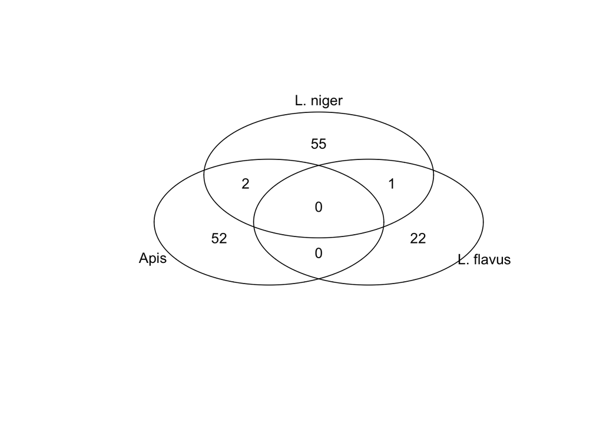

```r
lf.alt <- lf.alt.splice$Name[lf.alt.splice$Name != " "] # Exclude genes with no A. mellifera names
ln.alt <- ln.alt.splice$Name[ln.alt.splice$Name != " "]
venn(list(Apis = am.alt.splice$Name,`L. flavus` = lf.alt,`L. niger` = ln.alt))
```

## Gene co-expression network analysis

First, we define a series of functions for gene co-expression network analysis.

```r
# This function uses the ComBat function from the package 'sva' to remove variance in gene expression
# that is due to colony and species, allowing us to detect variance due to queen pheromone treatment.
# The use of ComBat in this fashion follows recommendations from the author of the WGCNA package.
remove.effects.combat <- function(expression.data){
  sampleIDs <- rownames(expression.data)
  ids <- with(treatments[match(sampleIDs, treatments$id), ],
              data.frame(
                id = sampleIDs,
                species = species,
                treatment = treatment,
                colony = paste(species, colony, sep = "")))

  modcombat <- model.matrix(~as.factor(treatment), data=ids)
  shh <- capture.output(expression.data <- ComBat(dat = t(expression.data),
                                                  batch = ids$species,
                                                  mod = modcombat,
                                                  par.prior = TRUE))
  shh <- capture.output(expression.data <- t(ComBat(dat = expression.data,
                                                    batch = ids$colony,
                                                    mod = modcombat,
                                                    par.prior = TRUE)))
  list(expression.data, ids)
}


# Build a gene coexpresison network using WGCNA package
build.network <- function(expression.data.list){
  # Pick the soft thresholding power that gives a model fit of R^2 > 0.8 for the scale-free topology model
  soft.power <- pickSoftThreshold(expression.data.list[[1]],
                                  RsquaredCut = 0.8, verbose = 0, powerVector = 1:30)
  # Use this power to generate a gene co-expression network, using the default settings
  network <- blockwiseModules(expression.data.list[[1]],
                              power = soft.power$powerEstimate,
                              networkType = "signed",
                              minModuleSize = 30,
                              verbose = 0,
                              saveTOMs = T)
  list(network, expression.data.list[[2]])
}


# By default, WGCNA gives the transcriptional modules random names like 'turqoise' or 'darkred'.
# I think it's more helpful to define the biggest module as 'Module 1', the second biggest as 'Module 2', etc
# I use the label 'Module 0' for genes that were not assigned to a module
convert.module.colors.to.names <- function(network){
  module.sizes <- table(network[[1]]$colors) %>% sort %>% rev
  module.sizes <- c(module.sizes[names(module.sizes) == "grey"],
                    module.sizes[names(module.sizes) != "grey"])
  module.mappings <- data.frame(color = names(module.sizes),
                                new.name = paste("Module",
                                                 0:(length(module.sizes)-1)), stringsAsFactors = F)
  network[[1]]$colors <- module.mappings$new.name[match(network[[1]]$colors, module.mappings$color)]
  names(network[[1]]$MEs) <- gsub("ME", "", names(network[[1]]$MEs))
  names(network[[1]]$MEs) <- module.mappings$new.name[match(names(network[[1]]$MEs),
                                                            module.mappings$color)]
  network
}


# Rearrange the data in a handy format for stats and plotting, and remove the 'Module 0', the un-assigned genes
rearrange.eigengene.data <- function(network.list){
  cbind(network.list[[2]], network.list[[1]]$MEs) %>%
    gather(Module, Eigengene, starts_with("Module")) %>%
    filter(Module != "Module 0") %>%
    rename(Species = species, Treatment = treatment) %>%
    arrange(Species, Treatment, colony, Module)
}


# Run a model selection analysis on each module. The full linear model has eigengene as the response variable, and treatment, species and treatment:species as predictors. We rank the 5 possible models using their AIC scores, and test which provides the best fit to the data (the 'delta' and 'weight' parameters reveal the difference in explantory power)
run.stats <- function(dat){

  do.one.module <- function(module, dat){
    options(na.action = "na.fail") # need to set this option when running dredge()
    full.model <- lm(Eigengene ~ Treatment * Species,
                     data = dat[dat$Module == paste("Module", module), ])
    output <- suppressMessages(dredge(full.model)) # compare full model and the four possible simpler models
    options(na.action = "na.omit") # set it back to default
    cbind(Module = module, output %>% as.data.frame()) # Add the module name to the results
  }

  stats <- do.call("rbind", # Run model selection on every module
                   lapply(1:length(unique(eigen.data$Module)), do.one.module, eigen.data))

  stats[,names(stats) %in% c("logLik", "AICc", "delta", "weight")] <-
    format(round(stats[,names(stats) %in% c("logLik", "AICc", "delta", "weight")], 2), nsmall = 2) # rounding
  rownames(stats) <- NULL
  stats <- stats[,-2] # Remove the intercept column
  stats$Module[duplicated(stats$Module)] <- " "
  model <- rep("Null model")
  model[stats$Species == "+"] <- "~ Species"
  model[stats$Treatment == "+"] <- "~ Treatment"
  model[stats$Species == "+" & stats$Treatment == "+"] <- "~ Species + Treatment"
    model[stats$`Species:Treatment` == "+"] <- "~ Species x Treatment"
  model[is.na(model)] <- "Null model"
  stats <- with(stats, data.frame(Module, Model = model,
                                  stats[,names(stats) %in% c("logLik", "AICc", "delta", "weight")]))
  stats
}
```

### Make the gene co-expression network, using the set of orthologous genes for all 4 species

```r
# The 4 bad samples get removed, then we find the orthologous genes, the data are scaled with ComBat, and then we build the network using the lowest soft-thresholding power that gives at least R^2 > 0.8 model fit
OGGs <- make.OGGs(c("am", "bt", "ln", "lf"), bad.samples = bad.samples)
network <- OGGs[[1]] %>%
  remove.effects.combat() %>%
  build.network() %>%
  convert.module.colors.to.names()
eigen.data <- network %>% rearrange.eigengene.data
```

### Simple statistics about the network

Here is the number of orthologous genes that form the network:

```r
length(network[[1]]$colors)
```

```
## [1] 3465
```

Here is the number and size of modules in the network - module 0 refers to the unassigned genes.

```r
table(network[[1]]$colors) %>% pander
```

Table continues below

| Module 0 | Module 1 | Module 2 | Module 3 | Module 4 | Module 5 | Module 6 |
| --- | --- | --- | --- | --- | --- | --- |
| 107 | 1639 | 543 | 346 | 288 | 160 | 154 |

| Module 7 | Module 8 | Module 9 |
| --- | --- | --- |
| 150 | 40 | 38 |

### Make a plot of the module eigengenes

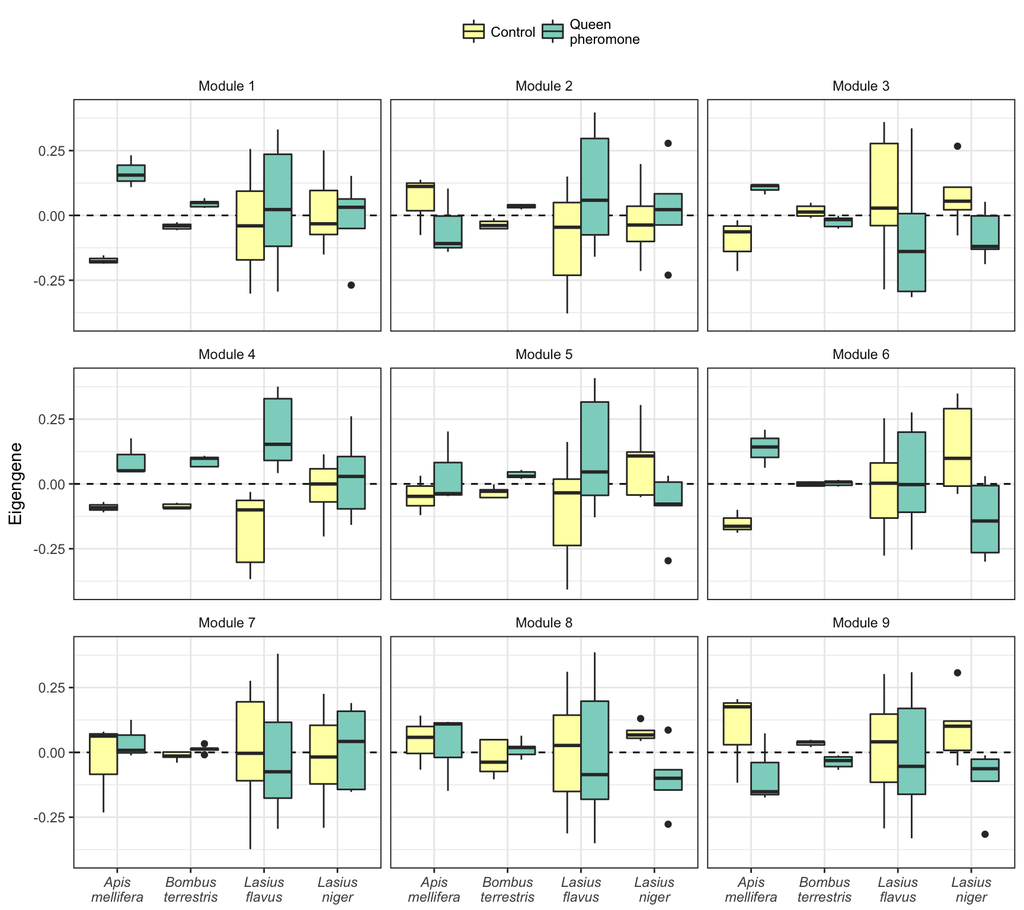

```r
# Make a plot of the module eigengenes, split by species, module and treatment
treatments.network.plot <- function(dat){
  dat %>% mutate(Treatment = replace(as.character(Treatment), Treatment == "QP", "Queen\npheromone")) %>%
    ggplot(aes(Species, Eigengene, fill = Treatment)) +
    geom_hline(yintercept = 0, linetype=2) +
    geom_boxplot() +
    facet_wrap(~Module) +
    xlab(NULL) +
    scale_x_discrete(labels = c("Apis\nmellifera", "Bombus\nterrestris", "Lasius\nflavus", "Lasius\nniger")) +
    scale_fill_brewer(name = " ", palette = "Set3", direction = -1) +
    theme_bw() +
    theme(strip.background = element_blank(),
          axis.text.x = element_text(face = "italic"),
          panel.border = element_rect(size=0.7),
          legend.position = "top")
}

eigen.data %>% treatments.network.plot()
```

```r
ggsave(eigen.data %>% treatments.network.plot(),
       file = "figures/Module eigengenes.pdf", height = 6.6, width = 8)
```

**Figure 4**: The figure shows the distribution of module eigengenes for each combination of module, species, and queen pheromone (QP) treatment. Positive values mean that the focal group has higher eigengenes, which derived from the relative expression levels of a module of genes, than the average.

### Run model selection analysis to test for treatment and species effects on eigengenes

```r
run.stats(eigen.data) %>% kable.table()
```

| Module | Model | logLik | AICc | delta | weight |
| --- | --- | --- | --- | --- | --- |
| 1 | ~ Treatment | 17.71 | -28.74 | 0.00 | 0.59 |
|  | Null model | 16.10 | -27.87 | 0.87 | 0.38 |
|  | ~ Species + Treatment | 17.72 | -20.81 | 7.93 | 0.01 |
|  | ~ Species | 16.10 | -20.39 | 8.35 | 0.01 |
|  | ~ Species x Treatment | 20.71 | -17.22 | 11.52 | 0.00 |
| 2 | ~ Treatment | 17.28 | -27.88 | 0.00 | 0.49 |
|  | Null model | 16.10 | -27.87 | 0.01 | 0.49 |
|  | ~ Species | 16.10 | -20.39 | 7.49 | 0.01 |
|  | ~ Species + Treatment | 17.29 | -19.95 | 7.93 | 0.01 |
|  | ~ Species x Treatment | 19.39 | -14.57 | 13.31 | 0.00 |
| 3 | Null model | 16.10 | -27.87 | 0.00 | 0.50 |
|  | ~ Treatment | 17.24 | -27.79 | 0.08 | 0.48 |
|  | ~ Species | 16.11 | -20.39 | 7.47 | 0.01 |
|  | ~ Species + Treatment | 17.24 | -19.85 | 8.02 | 0.01 |
|  | ~ Species x Treatment | 21.01 | -17.82 | 10.05 | 0.00 |
| 4 | ~ Treatment | 26.92 | -47.15 | 0.00 | 0.92 |
|  | ~ Species x Treatment | 33.05 | -41.89 | 5.27 | 0.07 |
|  | ~ Species + Treatment | 26.92 | -39.22 | 7.93 | 0.02 |
|  | Null model | 16.10 | -27.87 | 19.28 | 0.00 |
|  | ~ Species | 16.11 | -20.40 | 26.75 | 0.00 |
| 5 | Null model | 16.10 | -27.87 | 0.00 | 0.60 |
|  | ~ Treatment | 16.77 | -26.86 | 1.01 | 0.37 |
|  | ~ Species | 16.10 | -20.39 | 7.48 | 0.01 |
|  | ~ Species x Treatment | 21.77 | -19.33 | 8.53 | 0.01 |
|  | ~ Species + Treatment | 16.78 | -18.93 | 8.94 | 0.01 |
| 6 | Null model | 16.10 | -27.87 | 0.00 | 0.70 |
|  | ~ Treatment | 16.13 | -25.57 | 2.30 | 0.22 |
|  | ~ Species x Treatment | 23.61 | -23.00 | 4.86 | 0.06 |
|  | ~ Species | 16.11 | -20.40 | 7.47 | 0.02 |
|  | ~ Species + Treatment | 16.13 | -17.64 | 10.23 | 0.00 |
| 7 | Null model | 16.10 | -27.87 | 0.00 | 0.74 |
|  | ~ Treatment | 16.17 | -25.65 | 2.22 | 0.24 |
|  | ~ Species | 16.11 | -20.39 | 7.48 | 0.02 |
|  | ~ Species + Treatment | 16.17 | -17.72 | 10.15 | 0.00 |
|  | ~ Species x Treatment | 16.40 | -8.59 | 19.27 | 0.00 |
| 8 | Null model | 16.10 | -27.87 | 0.00 | 0.68 |
|  | ~ Treatment | 16.44 | -26.20 | 1.67 | 0.29 |
|  | ~ Species | 16.28 | -20.75 | 7.12 | 0.02 |
|  | ~ Species + Treatment | 16.63 | -18.64 | 9.23 | 0.01 |
|  | ~ Species x Treatment | 17.98 | -11.75 | 16.12 | 0.00 |
| 9 | ~ Treatment | 18.42 | -30.15 | 0.00 | 0.74 |
|  | Null model | 16.10 | -27.87 | 2.29 | 0.24 |
|  | ~ Species + Treatment | 18.42 | -22.22 | 7.93 | 0.01 |
|  | ~ Species | 16.11 | -20.39 | 9.76 | 0.01 |
|  | ~ Species x Treatment | 19.58 | -14.96 | 15.19 | 0.00 |

### Plot the correlations between all modules and the pheromone treatment

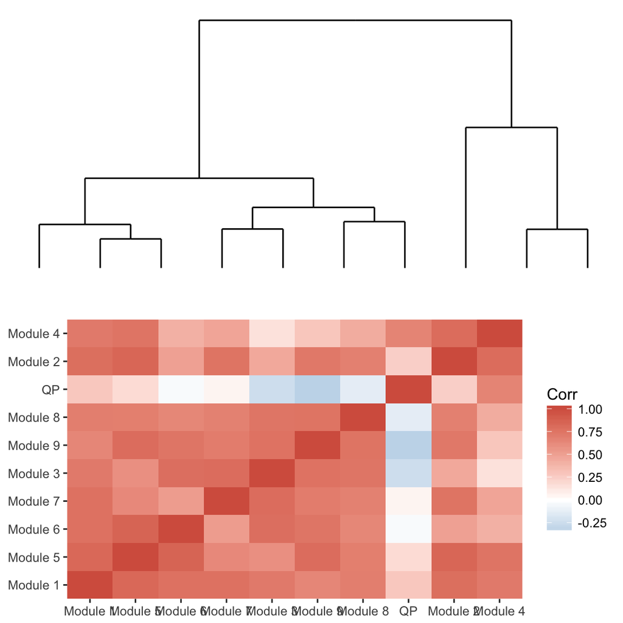

```r
meta.module.plot <- function(network){

  MET <- network[[1]]$MEs
  MET <- data.frame(QP = (network[[2]]$treatment %>% as.numeric())-1, MET) %>% dplyr::select(-Module.0)
  names(MET) <- gsub("[.]", " ", names(MET))
  cluster <- (1 - cor(MET)) %>% as.dist() %>% hclust()
  ordering <- cluster$labels[cluster$order]
  heat.map.data <- cor(MET) %>% melt %>%
    mutate(Var1 = factor(Var1, levels = ordering),
           Var2 = factor(Var2, levels = ordering)) %>%
    rename(Corr = value)
  heat.map <- heat.map.data %>% ggplot(aes(Var1, Var2, fill = Corr)) + geom_tile() +
    scale_fill_gradient2(low = brewer.pal(9, "RdBu")[8],
                         mid = "white",
                         high = brewer.pal(9, "RdBu")[2]) +
    xlab(NULL) + ylab(NULL) +
    theme_bw() +
    theme(panel.border = element_blank(),
          panel.grid = element_blank()) +
    scale_x_discrete(expand = c(0,0)) +
    scale_y_discrete(expand = c(0,0))

  dendrogram <- ggdendrogram(cluster) + theme(axis.text.x = element_blank(), axis.text.y = element_blank())

  p1 <- grid.arrange(dendrogram, heat.map)
  invisible(p1)
}

meta.plot <- meta.module.plot(network)
```

```r
ggsave(meta.plot, file = "figures/meta_module_heat_map.pdf", width = 5, height = 7.3, units = "in")
meta.plot
```

**Table S13**: Results of Spearman’s rank correlations testing for a relationship between the effect of queen pheromone on gene expression, and the connectedness of the gene. Negative values of Spearman’s Rho mean that highly pheromone-sensitive genes tend to have lower connectedness.

```r
load("blockwiseTOM-block.1.RData") # Load the TOM from the network analysis - can be used to find connectedness for each ortholog

# Get the phermonone sensitivity value for each of the OGGs, and line it up with the connectedness data
suppressMessages(dd <- OGGs[[2]] %>% left_join(tbl(my_db, "ebseq_gene_am") %>% select(gene, PostFC) %>% rename(am=gene), copy=T) %>% rename(am_FC = PostFC) %>%
  left_join(tbl(my_db, "ebseq_gene_bt") %>% select(gene, PostFC) %>%
              rename(bt=gene), copy=T) %>% rename(bt_FC = PostFC) %>%
  left_join(tbl(my_db, "ebseq_gene_lf") %>% select(gene, PostFC) %>%
              rename(lf=gene), copy=T) %>% rename(lf_FC = PostFC) %>%
  left_join(tbl(my_db, "ebseq_gene_ln") %>% select(gene, PostFC) %>%
              rename(ln=gene), copy=T) %>% rename(ln_FC = PostFC) %>%
  mutate(k = colSums(as.matrix(TOM))))

do.spearman <- function(dd, species, name){ # run spearman on each species
  test <- cor.test(dd$k, dd[, names(dd) == species] %>% log2 %>% abs, method = "spearman")  # Note that we convert the fold-change in expression with abs(log2(x)), to get pheromone sensitivity
  with(test, data.frame(Species = name, rho = estimate, p = p.value, row.names = NULL))
}

suppressWarnings(results <- rbind(do.spearman(dd, "am_FC", "Apis mellifera"),
                                  do.spearman(dd, "bt_FC", "Bombus terrestris"),
                                  do.spearman(dd, "lf_FC", "Lasius flavus"),
                                  do.spearman(dd, "ln_FC", "Lasius niger")))
rownames(results) <- NULL
pander(results)
```

| Species | rho | p |
| --- | --- | --- |
| Apis mellifera | -0.2463 | 4.834e-49 |
| Bombus terrestris | -0.2988 | 2.076e-72 |
| Lasius flavus | -0.4151 | 1.854e-144 |
| Lasius niger | -0.3159 | 4.677e-81 |

## Characteristics of pheromone-sensitive genes in *Apis*

In this section, we search for correlates of the absolute Log_2 fold change in response to pheromone (where positive values denote genes whose expression differs strongly between the control and pheromone treatment). This section makes use of data kindly provided by Soojin Yi and Brendan Hunt.

The data on queen and worker-specific gene expression come from Grozinger et al. 2007. We found that pheromone-sensitive genes tend to be over-expressed by queens relative to sterile workers. However, genes that are over-expressed by fertile workers relative to sterile workers did not tend to be more (or less) pheromone-sensitive.

The methylation level (i.e. % methylated cytosines) data come from Galbraith et al. 2016 (provided by Soojin Yi). We found a negative correlation between methylation and pheromone-sensitivity, suggesting that pheromone-sensitive genes are hypomethylated.

The CpG O/E values were calculated for the latest *A. mellifera* genome annotation. We found a positive correlation between CpG O/E and pheromone-sensitivity. High CpG is associated with lower rate of DNA methylation, again suggesting that pheromone-sensitive genes are hypomethylated.

The estimates of $\gamma$, a measure of positive and negative selection similar to dN/dS, come from Harpur et al. 2014 PNAS. There was a significant positive correlation between $\gamma$ and sensitivity to queen pheromone, suggesting that highly pheromone-sensitive genes tend to be positively selected.

The Codon adaptation index was calculated by Brendan Hunt. A high codon adaptation index denotes high codon usage bias, i.e. where certain synonymous codons are more common than others. Pheromone-sensitive genes showed low codon usage bias.

Lastly, ‘expression level’ refers to the average expression of each gene, expressed as TPM (transcripts per million) as measured by the software RSEM in the present study. Highly expressed genes tended to be less pheromone-sensitive.

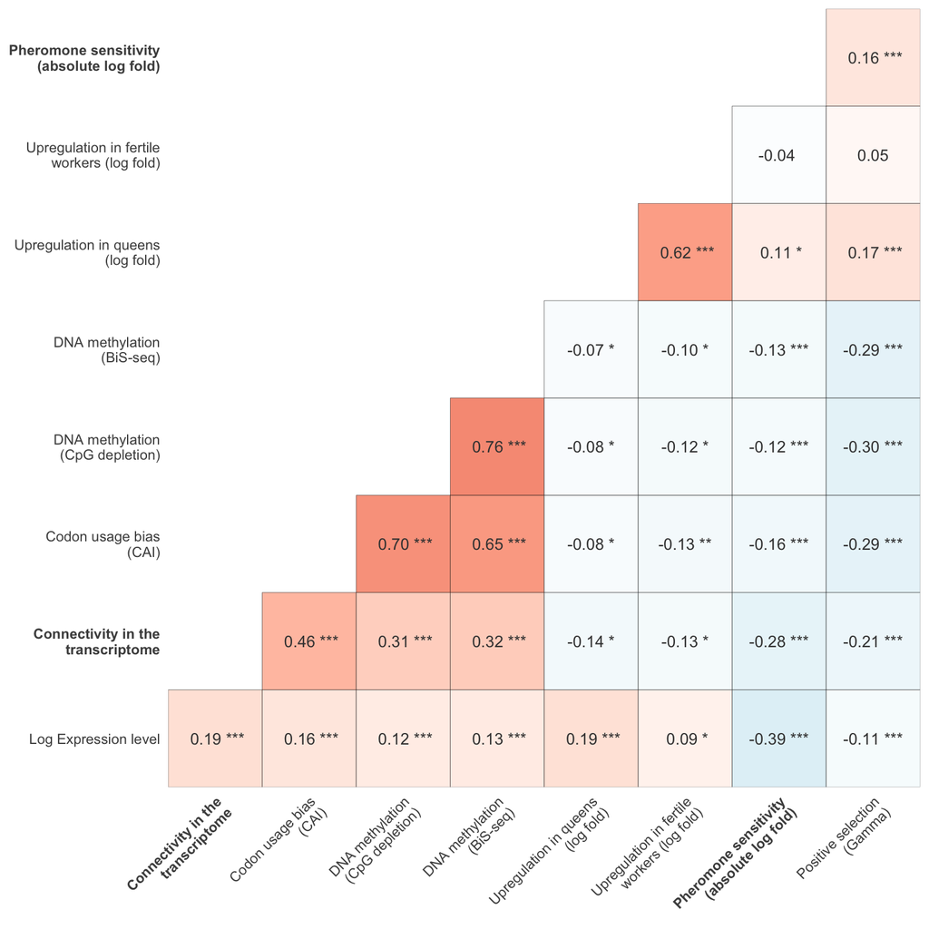

```r
# import and clean up the data provided by Brendan Hunt
hunt.data <- read.delim("data/apis_gene_comparisons/Amel_AllData_012709.txt",
                        header=T, stringsAsFactors = FALSE) %>%
  mutate(log2RW.SW = log2(RW_bagel / SW_bagel))        # calculate log fold difference in gene expression between fertile and sterile workers
entrez.tbl <- read.delim("data/apis_gene_comparisons/am.gene_info.txt", stringsAsFactors = FALSE)[,c(2,5,6)] # import table of gene names (Entrez, old Beebase, and new Beebase)
names(entrez.tbl) <- c("entrez.id", "beebase1", "beebase2")
hunt.data <- hunt.data %>%
  dplyr::select(ID, log2Q.SW, log2RW.SW, CAI, cpgOE) %>% # get gene ID and the relevant data
  rename(beebase1 = ID) %>%                              # merge based on beebase IDs
  left_join(entrez.tbl, by = "beebase1") %>%
  filter(!is.na(beebase2) & beebase2 != "-") %>%
  mutate(beebase2 = gsub("BEEBASE:", "", beebase2)) %>%
  rename(gene = beebase2) %>%
  dplyr::select(gene, log2Q.SW, log2RW.SW, CAI, cpgOE)
hunt.data <- left_join(tbl(my_db, "ebseq_gene_am") %>%       # merge Hunt's data with our phermone sensitivity data
                         dplyr::select(gene, PostFC) %>% collect(), hunt.data, by = "gene") %>%
  left_join(tbl(my_db, "bee_names") %>% collect, by = "gene")  # also add the gene names

# Import methylation data provided by Soojin Yi and Xin Wu (from Galbraith et al PNAS)
methylation <- read.csv("data/apis_gene_comparisons/apis_gene_methyl_CG_OE.csv", stringsAsFactors = FALSE)
methylation <- tbl(my_db, "ebseq_gene_am") %>% collect %>% left_join(methylation, by = "gene") %>%
  filter(!is.na(Gene_body_methylation)) %>%
  left_join(tbl(my_db, "bee_names") %>% collect(), by = "gene") %>% distinct(gene, .keep_all = T)

# Import gamma data from Harpur et al PNAS
gamma_am <- tbl(my_db, "ebseq_gene_am") %>% collect() %>%
  left_join(read.table("data/apis_gene_comparisons/harpur_etal_gamma.txt", header=TRUE, stringsAsFactors=FALSE) %>% rename(gene = Gene), by = "gene") %>%
  filter(!is.na(gamma)) %>%
  dplyr::select(gene, PostFC, gamma) %>%
  mutate(PostFC = log2(PostFC)) %>% left_join(tbl(my_db, "bee_names"), copy=TRUE, by = "gene") %>%
  arrange(-abs(PostFC))


merged <- hunt.data %>% dplyr::select(gene, PostFC, log2Q.SW, log2RW.SW, CAI) %>%
  left_join(methylation %>% dplyr::select(gene, CG_OE, Gene_body_methylation), by = "gene") %>% # merge in methylation data provided by Soojin Yi
  left_join(gamma_am %>% dplyr::select(gene, gamma), by = "gene") %>%                         # merge in gamma data from Harpur et al
  left_join(data.frame(gene = tbl(my_db, "rsem_am") %>%
                         dplyr::select(gene) %>% collect(),  # calculate overall expression level from our own data
                       expression.level = (tbl(my_db, "rsem_am") %>%
                                             dplyr::select(-gene) %>%
                                             collect %>% rowSums())), by = "gene") %>%
  left_join(dd %>% dplyr::select(am, k) %>% rename(gene=am), by = "gene") %>%
  dplyr::select(-gene) %>%
  mutate(CG_OE = -log2(CG_OE),                         # log2 CpG O/E ratio - change the sign, so that high values mean high methylation
         expression.level = log10(expression.level),   # log10 the expression level
         PostFC = abs(log2(PostFC))) %>%               # absolute log2 fold-change in response to pheromones (i.e. 'pheromone sensitivity' score)
  as.data.frame()

m.rename <- function(merged, col, new) {names(merged)[names(merged) == col] <- new; merged}
merged <- merged %>% m.rename("PostFC", "Pheromone sensitivity\n(absolute log fold)")   # re-label all the variables nicely
merged <- merged %>% m.rename("log2Q.SW", "Upregulation in queens\n(log fold)")
merged <- merged %>% m.rename("log2RW.SW", "Upregulation in fertile\nworkers (log fold)")
merged <- merged %>% m.rename("CAI", "Codon usage bias\n(CAI)")
merged <- merged %>% m.rename("CG_OE", "DNA methylation\n(CpG depletion)")
merged <- merged %>% m.rename("Gene_body_methylation", "DNA methylation\n(BiS-seq)")
merged <- merged %>% m.rename("gamma", "Positive selection\n(Gamma)")
merged <- merged %>% m.rename("expression.level", "Log Expression level")
merged <- merged %>% m.rename("k", "Connectivity in the\ntranscriptome")

reorder_cormat <- function(cormat){ # reorder a correlation matrix using hierarchical clustering
  dd <- as.dist((1-cormat)/2)
  hc <- hclust(dd)
  cormat[hc$order, hc$order]}

cormat <- reorder_cormat(cor(merged, use = 'pairwise.complete.obs'))
cormat[upper.tri(cormat)] <- NA
diag(cormat) <- NA

cor.matrix <-  (melt(cormat) %>% filter(!is.na(value)))[,1:2] %>% mutate(cor=0,p=0)
for(i in 1:nrow(cor.matrix)) cor.matrix[i, 3:4] <- cor.test(merged[, names(merged) == cor.matrix$Var1[i]], merged[, names(merged) == cor.matrix$Var2[i]])[c(4,3)] %>% unlist
cor.matrix$p <- p.adjust(cor.matrix$p, method = "BH") # apply B-H p value correction
cor.matrix$sig <- ""
cor.matrix$sig[cor.matrix$p < 0.05] <- "*"
cor.matrix$sig[cor.matrix$p < 0.001] <- "**"
cor.matrix$sig[cor.matrix$p < 0.0001] <- "***"
cor.matrix$label <- paste(format(round(cor.matrix$cor,2), nSmall =2), cor.matrix$sig)
correlation.plot <- cor.matrix %>%
  ggplot(aes(Var1, Var2, fill=cor)) +
  geom_tile(colour="grey10",alpha=0.7) +
  scale_fill_gradient2(name = "Corr",
                       low = brewer.pal(9, "RdYlBu")[7],
                       mid = "white",
                       high = brewer.pal(9, "RdYlBu")[2]) +
  geom_text(aes(label = label), colour = "grey25", size = 3.5) +
  xlab(NULL) + ylab(NULL) +
  scale_x_discrete(expand=c(0,0)) + scale_y_discrete(expand=c(0, 0)) +
  theme_minimal() + theme(axis.text.x = element_text(angle = 45, hjust = 1, face = c("bold", rep("plain", 5), "bold", "plain")),
                          axis.text.y = element_text(face = c("plain", "bold", rep("plain", 5), "bold")),
                          panel.grid = element_blank(),
                          legend.position = "none")
ggsave(correlation.plot, file = "figures/correlation_plot.pdf", width =8, height = 8)
correlation.plot
```

**Figure 5**: Correlations across genes between various parameters, for *Apis mellifera*. ‘Pheromone sensitivity’ was calculated as the absolute value of the Log$_2$ fold difference in expression between pheromone treatment and the control. The Log FC (fold change) data come from Grozinger et al. 2007 (Mol. Ecol.), and positive values denote genes that have higher expression in queens or fertile workers, relative to sterile workers. Codon usage bias was estimated by the codon adaptation index: high values indicate bias for particular synonymous codons. DNA methylation rate was estimated either by the frequency of CpGs (i.e. -log CpG O/E ratio), or from bisulphite sequencing (BiS-seq). The parameter gamma ($\gamma$) describes the form of selection, where positive values denote positive selection, and negative values purifying selection. Lastly, the expression level was calculated from our own dataset as the log transcripts per million, averaged across our 6 *Apis* libraries.

## Contrasting our *Lasius* data with results from Morandin *et al.* 2016

Morandin *et al.* 2016 (*Genome Biology* 17:43) studied whole transcriptomes from queens and workers in 16 diverse ant species, including two other species from the genus *Lasius*. Using BLAST, they grouped genes into OGGs (orthologous gene groups), and built a co-expression network using all the OGGs that were common to all 16 species (similar to the present study). Their analysis yielded 36 modules, of which many showed significant queen-worker differences in their module eigengenes. Here, we want to test whether these queen- and worker-like modules significantly overlap with the pheromone-sensitive modules in the present study.

To do this, we used BLAST to identify orthologous gens in *L. niger* and *L. flavus* that belong to one of Morandin et al.’s OGGs. We then tested for significantly-greater-than-random overlap between Morandin et al’s modules, and our own study’s modules, using hypergeometric tests.

Of all the possible module pairs, we found 6 pairs that overlapped significantly more than expected (FDR-corrected). One of these pairs included our highly pheromone-sensitive module, Module 4, which overlapped with the caste-biased Module 13 from Morandin et al. The intersecting genes include *protein take-out like*, a NAD kinase 2, a serine protease, and *histone H2A-like*.

**Table S14**: A list of the six module pairs, from Morandin *et al.* 2016 and the present study, which had significantly more genes in common than expected by chance. The p-values were calculated by running hypergeometric tests on all possible pairs of modules from the two studies, and then adjusting all the p-values using the Benjamini-Hochberg procedure.

```r
morandin.orthology <- read.csv("data/morandin_comparison_data/Morandin to Holman orthology.csv", stringsAsFactors = FALSE)
morandin.module.membership <- read.csv("data/morandin_comparison_data/Morandin module membership.csv", stringsAsFactors = FALSE)
morandin.module.caste.bias <- read.csv("data/morandin_comparison_data/Morandin module caste bias.csv", stringsAsFactors = FALSE)
# Create list of all the L. niger & L. flavus genes are are part of
# the Orthologous Gene Groups (OGGs) from Morandin et al.
# Here are the 3634 genes for which we have 1-to-1 orthologs in all 18 species:
morandin.oggs <- make.OGGs(c("ln", "lf"))[[2]] %>%
  left_join(morandin.orthology, by = "ln") %>%
  filter(!is.na(morandin.ogg)) %>%
  left_join(morandin.module.membership, by = "morandin.ogg") %>%
  left_join(tbl(my_db, "ln2am") %>%
              left_join(tbl(my_db, "bee_names"), by = c("am" = "gene")) %>%
              filter(!is.na(name)) %>% select(ln, name, am) %>%
              rename(apis.name = name) %>% collect(n=Inf), by = "ln") %>%
  left_join(morandin.module.caste.bias, by = "module") %>%
  rename(morandin.module = module) %>%
  left_join(data.frame(ln = OGGs[[2]]$ln,
                       holman.module = network[[1]]$colors,
                       stringsAsFactors = F), by = "ln") %>%
  left_join(tbl(my_db, "ebseq_gene_ln") %>%
              select(gene, PostFC) %>% collect(n=Inf) %>% rename(ln = gene), by = "ln") %>%
  rename(FC.pheromone = PostFC)
overlaps <- table(morandin.oggs$morandin.module,
                  morandin.oggs$holman.module) %>%
  melt() %>% rename(morandin.module = Var1,
                    holman.module = Var2,
                    overlaps = value) %>%
  filter(holman.module != "Module 0") %>%
  left_join(table(morandin.oggs$morandin.module) %>%
              melt() %>% rename(mor.mod.size = value),
            by = c("morandin.module" = "Var1")) %>%
  left_join(table(morandin.oggs$holman.module) %>% melt() %>%
              rename(hol.mod.size = value), by = c("holman.module" = "Var1"))

# List all the Morandin et al. modules that significantly overlap with our own modules
overlaps <- data.frame(
  overlaps,
  do.call("rbind",
          lapply(1:nrow(overlaps),
                 function(i) with(overlaps,
                                  overlap.hypergeometric.test(
                                    overlaps[i],
                                    mor.mod.size[i],
                                    hol.mod.size[i],
                                    nrow(morandin.oggs),
                                    species = "xx"))))[,2:3]) %>%
  filter(Test == "Overlap is higher than expected:") %>%
  arrange(p) %>% select(-Test) %>%
  left_join(morandin.oggs %>%
              select(morandin.module, caste.bias) %>%
              distinct(), by = "morandin.module") %>%
  mutate(p = p.adjust(p, method = "BH"),
         morandin.module = paste("Module", morandin.module)) %>%
  filter(p < 0.05)
names(overlaps) <- c("Morandin module", "Holman module", "n overlapping genes", "Size of Morandin module", "Size of Holman module", "p-value", "Caste bias of Morandin module")
overlaps %>%
  pander(split.cell = 40, split.table = Inf)
```

| Morandin module | Holman module | n overlapping genes | Size of Morandin module | Size of Holman module | p-value | Caste bias of Morandin module |
| --- | --- | --- | --- | --- | --- | --- |
| Module 32 | Module 2 | 20 | 39 | 363 | 8.886e-09 | Worker-biased |
| Module 31 | Module 1 | 69 | 161 | 969 | 0.0002602 | Queen-biased |
| Module 26 | Module 8 | 5 | 49 | 24 | 0.0005457 | Worker-biased |
| Module 32 | Module 8 | 4 | 39 | 24 | 0.003328 | Worker-biased |
| Module 13 | Module 4 | 10 | 61 | 177 | 0.01554 | Queen-biased |
| Module 10 | Module 3 | 10 | 77 | 150 | 0.02318 | Worker-biased |

A list of the genes (OGGs) that appear in the present study’s Module 4 (which is pheromone-sensitive), and also in Morandin et al.’s Module 13 (which is caste-biased).

```r
morandin.oggs %>%
  filter(morandin.module == 13, holman.module == "Module 4") %>%
  .$apis.name
```

```
##  [1] "tumor suppressor candidate 3-like"
##  [2] "methyltransferase-like isoform X3"
##  [3] "uncharacterized protein LOC726417"
##  [4] "uncharacterized protein LOC100576236 isoform X1"
##  [5] "NAD kinase 2, mitochondrial-like"
##  [6] "histone H2A-like"
##  [7] "protein takeout-like"
##  [8] "uncharacterized protein LOC551133 isoform X2"
##  [9] "xenotropic and polytropic retrovirus receptor 1 homolog"
## [10] "putative serine protease K12H4.7-like isoform X2"
```

## KEGG and GO enrichment for differentially *expressed* genes

First, define some functions we will need. See also the R script “Script to set up for GO analyses.R”, which was used to make the object gene_set_collection.RData, following instructions for making a GO annotation for a non-model organism at http://bioconductor.org/packages/2.11/bioc/vignettes/GOstats/inst/doc/GOstatsForUnsupportedOrganisms.pdf.

There are only two differentially expressed genes for *B. terrestris*, so it is only meaningful to test for enriched GO/KEGG terms in the other three species.

```r
GO.and.KEGG.enrichment <- function(enriched.genes, gene.universe, ontology, pan = TRUE, keep.all = FALSE){

  p <- 0.05
  neatness <- function(x, dp) format(round(x, dp), nsmall = 3)
  if(keep.all) p <- 1
  GO.enrichment <- function(enriched.genes, gene.universe, ontology){

    params <- GSEAGOHyperGParams(
      name = "Luke's Params",
      geneSetCollection = gene_set_collection, # custom GO annotations
      geneIds = enriched.genes,
      universeGeneIds = gene.universe,
      ontology = ontology, # Can be BP, MF, or CC
      pvalueCutoff = p,
      conditional = TRUE, # Do the test conditional on the GO structure
      testDirection = "over") # Look for over-represented GO terms, not under

    hyperGTest(params) %>%
      summary() %>%
      dplyr::mutate(Pvalue = neatness(Pvalue, 5),
                    OddsRatio = neatness(OddsRatio, 3),
                    ExpCount = neatness(ExpCount, 3)) %>%
      dplyr::rename(ID = GOBPID)
  }

  kegg.enrichment <- function(enriched.genes, gene.universe){

    params <- GSEAKEGGHyperGParams(
      name = "Luke's Params",
      geneSetCollection = gene_set_collection_kegg, # custom KEGG annotations
      geneIds = enriched.genes,
      universeGeneIds = gene.universe,
      pvalueCutoff = p,
      testDirection = "over") # Look for over-represented KEGG terms, not under

    hyperGTest(params) %>%
      summary() %>%
      dplyr::mutate(Pvalue = neatness(Pvalue, 5),
                    OddsRatio = neatness(OddsRatio, 3),
                    ExpCount = neatness(ExpCount, 3),
                    KEGGID = paste("KEGG", KEGGID, sep = ":")) %>%
      dplyr::rename(ID = KEGGID)
  }

  output <- rbind(kegg.enrichment(enriched.genes, gene.universe),
                  GO.enrichment(enriched.genes, gene.universe, ontology))
  if(!pan) return(output)
  output %>% kable.table()
}

# Find the names for the genes in a given module
genes.in.module <- function(module.number){
  colnames(OGGs[[1]])[network[[1]]$colors == paste("Module", module.number)]
}

# Get the gene names, and sensitivity to pheromone, for genes in a certain module
inspect.module.genes <- function(module){
  gene.names <- tbl(my_db, "bee_names") %>% as.data.frame()
  gene.names <- gene.names[gene.names$gene %in% genes.in.module(module), ]
  gene.names$k <- colSums(as.matrix(TOM)[network[[1]]$colors == paste("Module", module),
                                        network[[1]]$colors == paste("Module", module)])
  gene.names <- gene.names %>% arrange(-k)

  am <- tbl(my_db, "ebseq_gene_am") %>% as.data.frame()
  gene.names$am_fc <- am$PostFC[match(gene.names$gene, am$gene)]
  bt <- tbl(my_db, "ebseq_gene_bt") %>% rename(bt = gene) %>%
    left_join(tbl(my_db, "bt2am")) %>% as.data.frame()
  gene.names$bt_fc <- bt$PostFC[match(gene.names$gene, bt$am)]
  lf <- tbl(my_db, "ebseq_gene_lf") %>% rename(lf = gene) %>%
    left_join(tbl(my_db, "lf2am")) %>% as.data.frame()
  gene.names$lf_fc <- lf$PostFC[match(gene.names$gene, lf$am)]
  ln <- tbl(my_db, "ebseq_gene_ln") %>% rename(ln = gene) %>%
    left_join(tbl(my_db, "ln2am")) %>% as.data.frame()
  gene.names$ln_fc <- ln$PostFC[match(gene.names$gene, ln$am)]
  row.names(gene.names) <- NULL
  gene.names
}

# Load the gene set collection object needed for the GO tests
load("data/gene_set_collection.RData")

# Load the gene set collection object needed for the KEGG tests
load("data/gene_set_collection_kegg.RData")
```

### KEGG and GO enrichment for differentially expressed genes in *A. mellifera*

**Table S15**: Results of KEGG and GO enrichment analysis on the list of genes that were significantly upregulated in the **control** group in *A. mellifera*. The gene universe was defined as all *A. mellifera* genes measured in this study.

```r
gene.universe.apis <- (tbl(my_db, "rsem_am") %>%
                         as.data.frame())$gene
up.in.control.apis <- (apis.de %>% filter(`Log2 FC` > 0) %>% as.data.frame())$Gene
suppressMessages(GO.and.KEGG.enrichment(up.in.control.apis, gene.universe.apis, ontology = "BP"))
```

| ID | Pvalue | OddsRatio | ExpCount | Count | Size | Term |
| --- | --- | --- | --- | --- | --- | --- |
| KEGG:03010 | 0.00000 | 24.523 | 6.252 | 53 | 121 | Ribosome |
| KEGG:03050 | 0.00011 | 5.865 | 2.015 | 9 | 39 | Proteasome |
| KEGG:04145 | 0.01426 | 2.787 | 3.255 | 8 | 63 | Phagosome |
| KEGG:03060 | 0.01726 | 4.710 | 1.033 | 4 | 20 | Protein export |
| KEGG:03013 | 0.04024 | 1.955 | 6.149 | 11 | 119 | RNA transport |
| GO:0006518 | 0.00000 | 20.136 | 6.672 | 51 | 175 | peptide metabolic process |
| GO:0043604 | 0.00000 | 20.381 | 6.405 | 50 | 168 | amide biosynthetic process |
| GO:0006412 | 0.00000 | 21.247 | 5.361 | 45 | 147 | translation |
| GO:1901566 | 0.00000 | 12.811 | 10.827 | 56 | 284 | organonitrogen compound biosynthetic process |
| GO:0019538 | 0.00000 | 11.237 | 11.290 | 53 | 307 | protein metabolic process |
| GO:0009059 | 0.00000 | 4.098 | 21.426 | 51 | 562 | macromolecule biosynthetic process |
| GO:0044249 | 0.00000 | 3.392 | 29.203 | 57 | 766 | cellular biosynthetic process |
| GO:0034641 | 0.00000 | 3.060 | 33.931 | 60 | 890 | cellular nitrogen compound metabolic process |
| GO:0044260 | 0.00000 | 2.998 | 35.303 | 61 | 926 | cellular macromolecule metabolic process |
| GO:0071704 | 0.00001 | 2.652 | 55.242 | 76 | 1449 | organic substance metabolic process |
| GO:0006414 | 0.00413 | 52.000 | 0.113 | 2 | 3 | translational elongation |
| GO:0071826 | 0.01358 | 4.964 | 0.953 | 4 | 25 | ribonucleoprotein complex subunit organization |
| GO:0016485 | 0.01953 | 12.852 | 0.229 | 2 | 6 | protein processing |
| GO:0006417 | 0.02478 | 5.543 | 0.648 | 3 | 17 | regulation of translation |
| GO:0015991 | 0.02478 | 5.543 | 0.648 | 3 | 17 | ATP hydrolysis coupled proton transport |
| GO:0019805 | 0.03812 | Inf | 0.038 | 1 | 1 | quinolinate biosynthetic process |
| GO:1902001 | 0.03812 | Inf | 0.038 | 1 | 1 | fatty acid transmembrane transport |
| GO:0006231 | 0.03812 | Inf | 0.038 | 1 | 1 | dTMP biosynthetic process |
| GO:0045900 | 0.03812 | Inf | 0.038 | 1 | 1 | negative regulation of translational elongation |
| GO:1903825 | 0.03812 | Inf | 0.038 | 1 | 1 | organic acid transmembrane transport |
| GO:0009157 | 0.03812 | Inf | 0.038 | 1 | 1 | deoxyribonucleoside monophosphate biosynthetic process |
| GO:0009176 | 0.03812 | Inf | 0.038 | 1 | 1 | pyrimidine deoxyribonucleoside monophosphate metabolic process |
| GO:0043420 | 0.03812 | Inf | 0.038 | 1 | 1 | anthranilate metabolic process |
| GO:0006069 | 0.03812 | Inf | 0.038 | 1 | 1 | ethanol oxidation |
| GO:0034354 | 0.03812 | Inf | 0.038 | 1 | 1 | ‘de novo’ NAD biosynthetic process from tryptophan |
| GO:0034308 | 0.03812 | Inf | 0.038 | 1 | 1 | primary alcohol metabolic process |
| GO:0000028 | 0.03812 | Inf | 0.038 | 1 | 1 | ribosomal small subunit assembly |
| GO:0030163 | 0.04027 | 2.576 | 2.554 | 6 | 67 | protein catabolic process |

**Table S16**: Results of KEGG and GO enrichment analysis on the list of genes that were significantly upregulated in the **queen pheromone** treatment in *A. mellifera*. The gene universe was defined as all *A. mellifera* genes measured in this study.

```r
up.in.QP.apis <- (apis.de %>% filter(`Log2 FC` < 0) %>% as.data.frame())$Gene
GO.and.KEGG.enrichment(up.in.QP.apis, gene.universe.apis, ontology = "BP")
```

| ID | Pvalue | OddsRatio | ExpCount | Count | Size | Term |
| --- | --- | --- | --- | --- | --- | --- |
| KEGG:00250 | 0.01180 | 14.422 | 0.169 | 2 | 25 | Alanine, aspartate and glutamate metabolism |
| KEGG:00630 | 0.01273 | 13.815 | 0.176 | 2 | 26 | Glyoxylate and dicarboxylate metabolism |
| KEGG:01200 | 0.02283 | 5.782 | 0.630 | 3 | 93 | Carbon metabolism |
| GO:0032273 | 0.01173 | 14.344 | 0.169 | 2 | 17 | positive regulation of protein polymerization |
| GO:0051495 | 0.01312 | 13.443 | 0.178 | 2 | 18 | positive regulation of cytoskeleton organization |
| GO:0044089 | 0.01457 | 12.647 | 0.188 | 2 | 19 | positive regulation of cellular component biogenesis |
| GO:0051130 | 0.01768 | 11.307 | 0.208 | 2 | 21 | positive regulation of cellular component organization |
| GO:0043254 | 0.01768 | 11.307 | 0.208 | 2 | 21 | regulation of protein complex assembly |
| GO:0001678 | 0.01973 | 103.840 | 0.020 | 1 | 2 | cellular glucose homeostasis |
| GO:0006537 | 0.01973 | 103.840 | 0.020 | 1 | 2 | glutamate biosynthetic process |
| GO:0033500 | 0.01973 | 103.840 | 0.020 | 1 | 2 | carbohydrate homeostasis |
| GO:0043044 | 0.02945 | 51.900 | 0.030 | 1 | 3 | ATP-dependent chromatin remodeling |
| GO:0043623 | 0.03256 | 7.932 | 0.287 | 2 | 29 | cellular protein complex assembly |
| GO:0015980 | 0.03467 | 7.646 | 0.297 | 2 | 30 | energy derivation by oxidation of organic compounds |
| GO:0007050 | 0.03909 | 34.587 | 0.040 | 1 | 4 | cell cycle arrest |
| GO:0006388 | 0.03909 | 34.587 | 0.040 | 1 | 4 | tRNA splicing, via endonucleolytic cleavage and ligation |
| GO:0090063 | 0.04863 | 25.930 | 0.050 | 1 | 5 | positive regulation of microtubule nucleation |
| GO:0031113 | 0.04863 | 25.930 | 0.050 | 1 | 5 | regulation of microtubule polymerization |

### KEGG and GO enrichment for differentially expressed genes in *L. flavus*

**Table S17**: Results of KEGG and GO enrichment analysis on the list of genes that were significantly upregulated in the **control** group in *L. flavus*. The gene universe was defined as all *L. flavus* genes for which we detected an *A. mellifera* ortholog.

```r
# The gene universe is all L. flavus genes for which we found a BLAST hit in Apis mellifera
gene.universe.flavus <- (left_join(tbl(my_db, "rsem_lf") %>%
                                     dplyr::select(gene),
                                   tbl(my_db, "lf2am") %>%
                                     dplyr::rename(gene = lf), by = "gene") %>%
                           dplyr::select(am) %>%
                           filter(!is.na(am)) %>%
                           as.data.frame())[,1] %>% unique
# The test set is all differentially expressed genes in L. flavus for which we found a BLAST hit in Apis
up.in.control.flavus <- (flavus.de %>% filter(`Log2 FC` > 0 & `Apis BLAST` != " ") %>% as.data.frame())$`Apis BLAST` %>% unique

GO.and.KEGG.enrichment(up.in.control.flavus, gene.universe.flavus, ontology = "BP")
```

| ID | Pvalue | OddsRatio | ExpCount | Count | Size | Term |
| --- | --- | --- | --- | --- | --- | --- |
| KEGG:04142 | 0.01744 | 6.386 | 0.568 | 3 | 41 | Lysosome |
| GO:0042278 | 0.00412 | 11.415 | 0.340 | 3 | 30 | purine nucleoside metabolic process |
| GO:0015991 | 0.00519 | 24.375 | 0.113 | 2 | 10 | ATP hydrolysis coupled proton transport |
| GO:0009119 | 0.00750 | 9.024 | 0.420 | 3 | 37 | ribonucleoside metabolic process |
| GO:1901657 | 0.01000 | 8.053 | 0.465 | 3 | 41 | glycosyl compound metabolic process |
| GO:0006422 | 0.01135 | Inf | 0.011 | 1 | 1 | aspartyl-tRNA aminoacylation |
| GO:0006285 | 0.01135 | Inf | 0.011 | 1 | 1 | base-excision repair, AP site formation |
| GO:0003012 | 0.01135 | Inf | 0.011 | 1 | 1 | muscle system process |
| GO:0031032 | 0.01135 | Inf | 0.011 | 1 | 1 | actomyosin structure organization |
| GO:0006937 | 0.01135 | Inf | 0.011 | 1 | 1 | regulation of muscle contraction |
| GO:1902600 | 0.01171 | 14.952 | 0.170 | 2 | 15 | hydrogen ion transmembrane transport |
| GO:0098660 | 0.01171 | 14.952 | 0.170 | 2 | 15 | inorganic ion transmembrane transport |
| GO:0098655 | 0.01171 | 14.952 | 0.170 | 2 | 15 | cation transmembrane transport |
| GO:0006818 | 0.01329 | 13.875 | 0.182 | 2 | 16 | hydrogen transport |
| GO:0046034 | 0.01672 | 12.125 | 0.204 | 2 | 18 | ATP metabolic process |
| GO:0015672 | 0.01856 | 11.404 | 0.216 | 2 | 19 | monovalent inorganic cation transport |
| GO:0009144 | 0.02249 | 10.191 | 0.238 | 2 | 21 | purine nucleoside triphosphate metabolic process |
| GO:0044057 | 0.02258 | 92.176 | 0.023 | 1 | 2 | regulation of system process |
| GO:0000096 | 0.02258 | 92.176 | 0.023 | 1 | 2 | sulfur amino acid metabolic process |
| GO:0019284 | 0.02258 | 92.176 | 0.023 | 1 | 2 | L-methionine biosynthetic process from S-adenosylmethionine |
| GO:0046498 | 0.02258 | 92.176 | 0.023 | 1 | 2 | S-adenosylhomocysteine metabolic process |
| GO:0009199 | 0.02674 | 9.208 | 0.261 | 2 | 23 | ribonucleoside triphosphate metabolic process |
| GO:0009126 | 0.03366 | 8.042 | 0.295 | 2 | 26 | purine nucleoside monophosphate metabolic process |
| GO:0019509 | 0.03368 | 46.059 | 0.034 | 1 | 3 | L-methionine biosynthetic process from methylthioadenosine |
| GO:0071265 | 0.03368 | 46.059 | 0.034 | 1 | 3 | L-methionine biosynthetic process |
| GO:0043102 | 0.03368 | 46.059 | 0.034 | 1 | 3 | amino acid salvage |
| GO:0007205 | 0.03368 | 46.059 | 0.034 | 1 | 3 | protein kinase C-activating G-protein coupled receptor signaling pathway |
| GO:0055085 | 0.03452 | 4.858 | 0.738 | 3 | 65 | transmembrane transport |
| GO:0009161 | 0.04387 | 6.875 | 0.340 | 2 | 30 | ribonucleoside monophosphate metabolic process |
| GO:0009067 | 0.04467 | 30.686 | 0.045 | 1 | 4 | aspartate family amino acid biosynthetic process |
| GO:0042181 | 0.04467 | 30.686 | 0.045 | 1 | 4 | ketone biosynthetic process |
| GO:0006108 | 0.04467 | 30.686 | 0.045 | 1 | 4 | malate metabolic process |
| GO:0006744 | 0.04467 | 30.686 | 0.045 | 1 | 4 | ubiquinone biosynthetic process |
| GO:0006555 | 0.04467 | 30.686 | 0.045 | 1 | 4 | methionine metabolic process |
| GO:1901661 | 0.04467 | 30.686 | 0.045 | 1 | 4 | quinone metabolic process |
| GO:0055086 | 0.04484 | 4.345 | 0.817 | 3 | 72 | nucleobase-containing small molecule metabolic process |
| GO:0006163 | 0.04658 | 6.634 | 0.352 | 2 | 31 | purine nucleotide metabolic process |

**Table S18**: Results of KEGG and GO enrichment analysis on the list of genes that were significantly upregulated in the **queen pheromone** treatment in *L. flavus*. The gene universe was defined as all *L. flavus* genes for which we detected an *A. mellifera* ortholog.

```r
up.in.QP.flavus <- (flavus.de %>% filter(`Log2 FC` < 0 & `Apis BLAST` != " ") %>% as.data.frame())$`Apis BLAST` %>% unique
GO.and.KEGG.enrichment(up.in.QP.flavus, gene.universe.flavus, ontology = "BP")
```

| ID | Pvalue | OddsRatio | ExpCount | Count | Size | Term |
| --- | --- | --- | --- | --- | --- | --- |
| KEGG:04146 | 0.00009 | 10.553 | 0.798 | 6 | 39 | Peroxisome |
| KEGG:04141 | 0.00089 | 5.557 | 1.657 | 7 | 81 | Protein processing in endoplasmic reticulum |
| KEGG:01212 | 0.00157 | 9.845 | 0.532 | 4 | 26 | Fatty acid metabolism |
| KEGG:00030 | 0.00243 | 14.347 | 0.286 | 3 | 14 | Pentose phosphate pathway |
| KEGG:01200 | 0.00507 | 5.296 | 1.166 | 5 | 57 | Carbon metabolism |
| KEGG:00071 | 0.00699 | 9.246 | 0.409 | 3 | 20 | Fatty acid degradation |
| KEGG:01040 | 0.00799 | 20.400 | 0.143 | 2 | 7 | Biosynthesis of unsaturated fatty acids |
| KEGG:00981 | 0.00799 | 20.400 | 0.143 | 2 | 7 | Insect hormone biosynthesis |
| KEGG:00061 | 0.01051 | 16.989 | 0.164 | 2 | 8 | Fatty acid biosynthesis |
| KEGG:00062 | 0.01987 | 11.303 | 0.225 | 2 | 11 | Fatty acid elongation |
| KEGG:03050 | 0.02168 | 5.782 | 0.614 | 3 | 30 | Proteasome |
| KEGG:00052 | 0.02355 | 10.166 | 0.246 | 2 | 12 | Galactose metabolism |
| KEGG:01230 | 0.03262 | 4.862 | 0.716 | 3 | 35 | Biosynthesis of amino acids |
| KEGG:00410 | 0.03606 | 7.804 | 0.307 | 2 | 15 | beta-Alanine metabolism |
| KEGG:00380 | 0.03606 | 7.804 | 0.307 | 2 | 15 | Tryptophan metabolism |
| GO:0006098 | 0.00119 | 65.208 | 0.057 | 2 | 5 | pentose-phosphate shunt |
| GO:0006081 | 0.00119 | 65.208 | 0.057 | 2 | 5 | cellular aldehyde metabolic process |
| GO:0006629 | 0.00633 | 6.607 | 0.783 | 4 | 69 | lipid metabolic process |
| GO:0046496 | 0.01022 | 16.208 | 0.159 | 2 | 14 | nicotinamide nucleotide metabolic process |
| GO:0006102 | 0.01135 | Inf | 0.011 | 1 | 1 | isocitrate metabolic process |
| GO:0044242 | 0.01135 | Inf | 0.011 | 1 | 1 | cellular lipid catabolic process |
| GO:0015910 | 0.01135 | Inf | 0.011 | 1 | 1 | peroxisomal long-chain fatty acid import |
| GO:0015908 | 0.01135 | Inf | 0.011 | 1 | 1 | fatty acid transport |
| GO:0006635 | 0.01135 | Inf | 0.011 | 1 | 1 | fatty acid beta-oxidation |
| GO:0034440 | 0.01135 | Inf | 0.011 | 1 | 1 | lipid oxidation |
| GO:0072329 | 0.01135 | Inf | 0.011 | 1 | 1 | monocarboxylic acid catabolic process |
| GO:0072524 | 0.01171 | 14.952 | 0.170 | 2 | 15 | pyridine-containing compound metabolic process |
| GO:0006631 | 0.01329 | 13.875 | 0.182 | 2 | 16 | fatty acid metabolic process |
| GO:0006733 | 0.01672 | 12.125 | 0.204 | 2 | 18 | oxidoreduction coenzyme metabolic process |
| GO:0044281 | 0.01784 | 3.583 | 2.247 | 6 | 198 | small molecule metabolic process |
| GO:0005991 | 0.02258 | 92.176 | 0.023 | 1 | 2 | trehalose metabolic process |
| GO:0006012 | 0.03368 | 46.059 | 0.034 | 1 | 3 | galactose metabolic process |
| GO:0046942 | 0.03368 | 46.059 | 0.034 | 1 | 3 | carboxylic acid transport |
| GO:0009311 | 0.04467 | 30.686 | 0.045 | 1 | 4 | oligosaccharide metabolic process |
| GO:0006820 | 0.04467 | 30.686 | 0.045 | 1 | 4 | anion transport |
| GO:0005975 | 0.04484 | 4.345 | 0.817 | 3 | 72 | carbohydrate metabolic process |

### KEGG and GO enrichment for differentially expressed genes in *L. niger*

**Table S19**: Results of KEGG and GO enrichment analysis on the list of genes that were significantly upregulated in the **control** group in *L. niger* The gene universe was defined as all *L. niger* genes for which we detected an *A. mellifera* ortholog.

```r
# The gene universe is all L. flavus genes for which we found a BLAST hit in Apis mellifera
gene.universe.niger <- (left_join(tbl(my_db, "rsem_ln") %>%
                                    dplyr::select(gene),
                                  tbl(my_db, "ln2am") %>%
                                    dplyr::rename(gene = ln), by = "gene") %>%
                          dplyr::select(am) %>%
                          filter(!is.na(am)) %>%
                          as.data.frame())[,1] %>% unique
# The test set is all differentially expressed genes in L. flavus for which we found a BLAST hit in Apis
up.in.control.niger <- (niger.de %>% filter(`Log2 FC` > 0 & `Apis BLAST` != " ") %>% as.data.frame())$`Apis BLAST` %>% unique

GO.and.KEGG.enrichment(up.in.control.niger, gene.universe.niger, ontology = "BP")
```

| ID | Pvalue | OddsRatio | ExpCount | Count | Size | Term |
| --- | --- | --- | --- | --- | --- | --- |
| KEGG:04145 | 0.00336 | 12.834 | 0.322 | 3 | 35 | Phagosome |
| KEGG:01230 | 0.00426 | 11.709 | 0.349 | 3 | 38 | Biosynthesis of amino acids |
| KEGG:04745 | 0.00489 | 25.291 | 0.110 | 2 | 12 | Phototransduction - fly |
| KEGG:01100 | 0.00511 | 5.064 | 4.045 | 9 | 440 | Metabolic pathways |
| KEGG:00030 | 0.00575 | 22.975 | 0.120 | 2 | 13 | Pentose phosphate pathway |
| KEGG:00330 | 0.00575 | 22.975 | 0.120 | 2 | 13 | Arginine and proline metabolism |
| KEGG:04391 | 0.02240 | 10.432 | 0.239 | 2 | 26 | Hippo signaling pathway - fly |
| KEGG:00920 | 0.02735 | 58.292 | 0.028 | 1 | 3 | Sulfur metabolism |
| KEGG:00603 | 0.04519 | 29.104 | 0.046 | 1 | 5 | Glycosphingolipid biosynthesis - globo series |
| KEGG:00130 | 0.04519 | 29.104 | 0.046 | 1 | 5 | Ubiquinone and other terpenoid-quinone biosynthesis |
| GO:0006753 | 0.00096 | 12.285 | 0.484 | 4 | 57 | nucleoside phosphate metabolic process |
| GO:0009126 | 0.00099 | 20.400 | 0.212 | 3 | 25 | purine nucleoside monophosphate metabolic process |
| GO:0006163 | 0.00154 | 17.215 | 0.246 | 3 | 29 | purine nucleotide metabolic process |
| GO:0042278 | 0.00154 | 17.215 | 0.246 | 3 | 29 | purine nucleoside metabolic process |
| GO:0009161 | 0.00154 | 17.215 | 0.246 | 3 | 29 | ribonucleoside monophosphate metabolic process |
| GO:0044281 | 0.00158 | 7.319 | 1.478 | 6 | 188 | small molecule metabolic process |
| GO:0009259 | 0.00225 | 14.880 | 0.280 | 3 | 33 | ribonucleotide metabolic process |
| GO:0009119 | 0.00268 | 13.931 | 0.297 | 3 | 35 | ribonucleoside metabolic process |
| GO:1901657 | 0.00340 | 12.711 | 0.323 | 3 | 38 | glycosyl compound metabolic process |
| GO:0019362 | 0.00493 | 24.909 | 0.110 | 2 | 13 | pyridine nucleotide metabolic process |
| GO:0009168 | 0.00747 | 19.532 | 0.136 | 2 | 16 | purine ribonucleoside monophosphate biosynthetic process |
| GO:0006793 | 0.00803 | 6.511 | 0.858 | 4 | 101 | phosphorus metabolic process |
| GO:0046034 | 0.00843 | 18.218 | 0.144 | 2 | 17 | ATP metabolic process |
| GO:0031032 | 0.00849 | Inf | 0.008 | 1 | 1 | actomyosin structure organization |
| GO:0046129 | 0.00944 | 17.068 | 0.153 | 2 | 18 | purine ribonucleoside biosynthetic process |
| GO:0009152 | 0.01050 | 16.053 | 0.161 | 2 | 19 | purine ribonucleotide biosynthetic process |
| GO:0009144 | 0.01161 | 15.152 | 0.170 | 2 | 20 | purine nucleoside triphosphate metabolic process |
| GO:0009124 | 0.01277 | 14.344 | 0.178 | 2 | 21 | nucleoside monophosphate biosynthetic process |
| GO:0009199 | 0.01398 | 13.618 | 0.187 | 2 | 22 | ribonucleoside triphosphate metabolic process |
| GO:0072522 | 0.01523 | 12.961 | 0.195 | 2 | 23 | purine-containing compound biosynthetic process |
| GO:0044699 | 0.01590 | 4.333 | 5.689 | 10 | 670 | single-organism process |
| GO:0009163 | 0.01654 | 12.364 | 0.204 | 2 | 24 | nucleoside biosynthetic process |
| GO:0046390 | 0.01654 | 12.364 | 0.204 | 2 | 24 | ribose phosphate biosynthetic process |
| GO:0044208 | 0.01692 | 126.417 | 0.017 | 1 | 2 | ‘de novo’ AMP biosynthetic process |
| GO:0055129 | 0.01692 | 126.417 | 0.017 | 1 | 2 | L-proline biosynthetic process |
| GO:0006165 | 0.02527 | 63.167 | 0.025 | 1 | 3 | nucleoside diphosphate phosphorylation |
| GO:0006560 | 0.02527 | 63.167 | 0.025 | 1 | 3 | proline metabolic process |
| GO:0006096 | 0.02527 | 63.167 | 0.025 | 1 | 3 | glycolytic process |
| GO:0006189 | 0.03357 | 42.083 | 0.034 | 1 | 4 | ‘de novo’ IMP biosynthetic process |
| GO:0046040 | 0.03357 | 42.083 | 0.034 | 1 | 4 | IMP metabolic process |
| GO:0046033 | 0.03357 | 42.083 | 0.034 | 1 | 4 | AMP metabolic process |
| GO:0006732 | 0.03382 | 8.182 | 0.297 | 2 | 35 | coenzyme metabolic process |
| GO:1901564 | 0.03621 | 3.609 | 2.007 | 5 | 255 | organonitrogen compound metabolic process |
| GO:0009165 | 0.03750 | 7.704 | 0.314 | 2 | 37 | nucleotide biosynthetic process |
| GO:0009084 | 0.04179 | 31.542 | 0.042 | 1 | 5 | glutamine family amino acid biosynthetic process |
| GO:0006730 | 0.04179 | 31.542 | 0.042 | 1 | 5 | one-carbon metabolic process |
| GO:0009185 | 0.04179 | 31.542 | 0.042 | 1 | 5 | ribonucleoside diphosphate metabolic process |
| GO:0009135 | 0.04179 | 31.542 | 0.042 | 1 | 5 | purine nucleoside diphosphate metabolic process |
| GO:0006098 | 0.04179 | 31.542 | 0.042 | 1 | 5 | pentose-phosphate shunt |
| GO:0046031 | 0.04179 | 31.542 | 0.042 | 1 | 5 | ADP metabolic process |
| GO:0006081 | 0.04179 | 31.542 | 0.042 | 1 | 5 | cellular aldehyde metabolic process |
| GO:0016052 | 0.04179 | 31.542 | 0.042 | 1 | 5 | carbohydrate catabolic process |
| GO:0009072 | 0.04996 | 25.217 | 0.051 | 1 | 6 | aromatic amino acid family metabolic process |
| GO:0006979 | 0.04996 | 25.217 | 0.051 | 1 | 6 | response to oxidative stress |

**Table S20**: Results of KEGG and GO enrichment analysis on the list of genes that were significantly upregulated in the **queen pheromone** treatment in *L. niger* The gene universe was defined as all *L. niger* genes for which we detected an *A. mellifera* ortholog.

```r
up.in.QP.niger <- (niger.de %>% filter(`Log2 FC` < 0 & `Apis BLAST` != " ") %>% as.data.frame())$`Apis BLAST` %>% unique
GO.and.KEGG.enrichment(up.in.QP.niger, gene.universe.niger, ontology = "BP")
```

| ID | Pvalue | OddsRatio | ExpCount | Count | Size | Term |
| --- | --- | --- | --- | --- | --- | --- |
| KEGG:01200 | 0.00004 | 13.186 | 0.726 | 6 | 57 | Carbon metabolism |
| KEGG:01212 | 0.00230 | 14.495 | 0.280 | 3 | 22 | Fatty acid metabolism |
| KEGG:00061 | 0.00410 | 28.958 | 0.102 | 2 | 8 | Fatty acid biosynthesis |
| KEGG:04146 | 0.00682 | 9.428 | 0.407 | 3 | 32 | Peroxisome |
| KEGG:01100 | 0.00788 | 3.542 | 5.601 | 11 | 440 | Metabolic pathways |
| KEGG:00030 | 0.01099 | 15.739 | 0.165 | 2 | 13 | Pentose phosphate pathway |
| KEGG:00640 | 0.01860 | 11.508 | 0.216 | 2 | 17 | Propanoate metabolism |
| KEGG:00620 | 0.02540 | 9.569 | 0.255 | 2 | 20 | Pyruvate metabolism |
| GO:0006733 | 0.00496 | 25.100 | 0.111 | 2 | 17 | oxidoreduction coenzyme metabolic process |
| GO:0042744 | 0.00653 | Inf | 0.007 | 1 | 1 | hydrogen peroxide catabolic process |
| GO:0072593 | 0.00653 | Inf | 0.007 | 1 | 1 | reactive oxygen species metabolic process |
| GO:0042181 | 0.02590 | 56.222 | 0.026 | 1 | 4 | ketone biosynthetic process |
| GO:0006108 | 0.02590 | 56.222 | 0.026 | 1 | 4 | malate metabolic process |
| GO:0042773 | 0.02590 | 56.222 | 0.026 | 1 | 4 | ATP synthesis coupled electron transport |
| GO:0006744 | 0.02590 | 56.222 | 0.026 | 1 | 4 | ubiquinone biosynthetic process |
| GO:1901661 | 0.02590 | 56.222 | 0.026 | 1 | 4 | quinone metabolic process |
| GO:0044281 | 0.02780 | 4.698 | 1.261 | 4 | 193 | small molecule metabolic process |
| GO:0006098 | 0.03228 | 42.139 | 0.033 | 1 | 5 | pentose-phosphate shunt |
| GO:0006081 | 0.03228 | 42.139 | 0.033 | 1 | 5 | cellular aldehyde metabolic process |
| GO:0006979 | 0.03862 | 33.689 | 0.039 | 1 | 6 | response to oxidative stress |
| GO:0008152 | 0.04294 | 6.176 | 5.950 | 9 | 911 | metabolic process |
| GO:0009117 | 0.04899 | 6.792 | 0.366 | 2 | 56 | nucleotide metabolic process |

### KEGG and GO enrichment for differentially expressed genes observed in multiple species

```r
overlap.gene.universe <- make.OGGs(c("am", "lf", "ln"))[[2]]$am      # The gene universe is all genes that have orthologs in the 3 species that we tested for overlap
suppressWarnings(GO.and.KEGG.enrichment(all.overlaps, overlap.gene.universe, ontology = "BP"))
```

| ID | Pvalue | OddsRatio | ExpCount | Count | Size | Term |
| --- | --- | --- | --- | --- | --- | --- |
| KEGG:01200 | 0.00006 | 18.047 | 0.484 | 5 | 45 | Carbon metabolism |
| KEGG:00030 | 0.00020 | 39.533 | 0.129 | 3 | 12 | Pentose phosphate pathway |
| KEGG:01212 | 0.02001 | 11.254 | 0.226 | 2 | 21 | Fatty acid metabolism |
| KEGG:01100 | 0.02015 | 3.682 | 3.982 | 8 | 370 | Metabolic pathways |
| KEGG:01230 | 0.04170 | 7.310 | 0.334 | 2 | 31 | Biosynthesis of amino acids |
| KEGG:00130 | 0.04241 | 33.111 | 0.043 | 1 | 4 | Ubiquinone and other terpenoid-quinone biosynthesis |
| GO:0006733 | 0.00035 | 32.009 | 0.153 | 3 | 17 | oxidoreduction coenzyme metabolic process |
| GO:0006098 | 0.00073 | 89.333 | 0.045 | 2 | 5 | pentose-phosphate shunt |
| GO:0006081 | 0.00073 | 89.333 | 0.045 | 2 | 5 | cellular aldehyde metabolic process |
| GO:0072524 | 0.00546 | 24.202 | 0.117 | 2 | 13 | pyridine-containing compound metabolic process |
| GO:0046496 | 0.00546 | 24.202 | 0.117 | 2 | 13 | nicotinamide nucleotide metabolic process |
| GO:0031032 | 0.00902 | Inf | 0.009 | 1 | 1 | actomyosin structure organization |
| GO:0051186 | 0.03134 | 8.886 | 0.288 | 2 | 35 | cofactor metabolic process |
| GO:0042181 | 0.03562 | 40.200 | 0.036 | 1 | 4 | ketone biosynthetic process |
| GO:0006108 | 0.03562 | 40.200 | 0.036 | 1 | 4 | malate metabolic process |
| GO:0006744 | 0.03562 | 40.200 | 0.036 | 1 | 4 | ubiquinone biosynthetic process |
| GO:1901661 | 0.03562 | 40.200 | 0.036 | 1 | 4 | quinone metabolic process |
| GO:0006979 | 0.03562 | 40.200 | 0.036 | 1 | 4 | response to oxidative stress |
| GO:0044281 | 0.04119 | 3.974 | 1.407 | 4 | 156 | small molecule metabolic process |

## KEGG and GO enrichment for differentially spliced genes

### KEGG and GO enrichment for *A. mellifera* genes showing pheromone-modulated alternative splicing

```r
# The gene universe is defined as all genes that have 2 or more isoforms. It would be anti-conservative if we instead included all genes, not just that are alternatively spliced
gene.universe.apis.splicing <- (tbl(my_db, "isoforms_am") %>%
                                  group_by(gene) %>%
                                  summarise(nIsoforms = n()) %>% filter(nIsoforms > 1) %>%
                                  as.data.frame() %>%
                                  dplyr::select(gene) %>% as.data.frame())[,1]
```

**Table S22**: Results of KEGG and GO enrichment analysis on the list of genes showing significant alternative splicing in *A. mellifera*. The gene universe was defined as all genes that showed alternative splicing in *A. mellifera*.

```r
GO.and.KEGG.enrichment(am.alt.splice$Gene, gene.universe.apis.splicing, ontology = "BP")
```

| ID | Pvalue | OddsRatio | ExpCount | Count | Size | Term |
| --- | --- | --- | --- | --- | --- | --- |
| KEGG:04745 | 0.00580 | 24.049 | 0.122 | 2 | 11 | Phototransduction - fly |
| KEGG:00564 | 0.04346 | 7.310 | 0.343 | 2 | 31 | Glycerophospholipid metabolism |
| GO:0007568 | 0.01189 | Inf | 0.012 | 1 | 1 | aging |
| GO:0032793 | 0.01189 | Inf | 0.012 | 1 | 1 | positive regulation of CREB transcription factor activity |
| GO:0090399 | 0.01189 | Inf | 0.012 | 1 | 1 | replicative senescence |
| GO:1901700 | 0.01189 | Inf | 0.012 | 1 | 1 | response to oxygen-containing compound |
| GO:0000723 | 0.01189 | Inf | 0.012 | 1 | 1 | telomere maintenance |
| GO:0010212 | 0.01189 | Inf | 0.012 | 1 | 1 | response to ionizing radiation |
| GO:0016572 | 0.01189 | Inf | 0.012 | 1 | 1 | histone phosphorylation |
| GO:1901031 | 0.01189 | Inf | 0.012 | 1 | 1 | regulation of response to reactive oxygen species |
| GO:0046470 | 0.01189 | Inf | 0.012 | 1 | 1 | phosphatidylcholine metabolic process |
| GO:0051103 | 0.02366 | 89.385 | 0.024 | 1 | 2 | DNA ligation involved in DNA repair |
| GO:0051090 | 0.02366 | 89.385 | 0.024 | 1 | 2 | regulation of sequence-specific DNA binding transcription factor activity |
| GO:0071897 | 0.02366 | 89.385 | 0.024 | 1 | 2 | DNA biosynthetic process |
| GO:0000075 | 0.02366 | 89.385 | 0.024 | 1 | 2 | cell cycle checkpoint |
| GO:0000077 | 0.02366 | 89.385 | 0.024 | 1 | 2 | DNA damage checkpoint |
| GO:0007049 | 0.03124 | 8.644 | 0.285 | 2 | 24 | cell cycle |
| GO:0007050 | 0.03529 | 44.654 | 0.036 | 1 | 3 | cell cycle arrest |
| GO:0080134 | 0.03529 | 44.654 | 0.036 | 1 | 3 | regulation of response to stress |
| GO:0033554 | 0.04442 | 7.012 | 0.345 | 2 | 29 | cellular response to stress |
| GO:0009628 | 0.04680 | 29.744 | 0.048 | 1 | 4 | response to abiotic stimulus |
| GO:0016569 | 0.04680 | 29.744 | 0.048 | 1 | 4 | chromatin modification |
| GO:0044093 | 0.04680 | 29.744 | 0.048 | 1 | 4 | positive regulation of molecular function |

### KEGG and GO enrichment for *L. flavus* genes showing pheromone-modulated alternative splicing

```r
# For flavus and niger, we additionally have to find the best BLAST Apis genes when constructing the gene lists
gene.universe.flavus.splicing <- (tbl(my_db, "isoforms_lf") %>%
                                  group_by(gene) %>%
                                  summarise(nIsoforms = n()) %>% filter(nIsoforms > 1) %>%
                                  as.data.frame() %>%
                                  dplyr::select(gene) %>% as.data.frame())[,1]

gene.universe.flavus.splicing <- (tbl(my_db, "lf2am") %>%  # Convert to Apis gene names via BLAST
                         filter(lf %in% gene.universe.flavus.splicing) %>%
                         dplyr::select(am) %>% filter(!is.na(am)) %>% as.data.frame())[,1]

alt.spliced.flavus <- (tbl(my_db, "lf2am") %>%
                         filter(lf %in% lf.alt.splice$Gene) %>%
                         dplyr::select(am) %>% filter(!is.na(am)) %>% as.data.frame())[,1]
```

```r
GO.and.KEGG.enrichment(alt.spliced.flavus, gene.universe.flavus, ontology = "BP")
```

| ID | Pvalue | OddsRatio | ExpCount | Count | Size | Term |
| --- | --- | --- | --- | --- | --- | --- |
| KEGG:01230 | 0.01331 | 14.889 | 0.185 | 2 | 35 | Biosynthesis of amino acids |
| KEGG:01100 | 0.01420 | 6.619 | 2.514 | 6 | 476 | Metabolic pathways |
| KEGG:01200 | 0.03367 | 8.800 | 0.301 | 2 | 57 | Carbon metabolism |
| KEGG:00670 | 0.03645 | 35.738 | 0.037 | 1 | 7 | One carbon pool by folate |
| KEGG:00061 | 0.04157 | 30.612 | 0.042 | 1 | 8 | Fatty acid biosynthesis |
| GO:0046483 | 0.00305 | 6.729 | 3.156 | 8 | 455 | heterocycle metabolic process |
| GO:0006725 | 0.00309 | 6.708 | 3.163 | 8 | 456 | cellular aromatic compound metabolic process |
| GO:1901360 | 0.00329 | 6.625 | 3.190 | 8 | 460 | organic cyclic compound metabolic process |
| GO:0051187 | 0.00694 | Inf | 0.007 | 1 | 1 | cofactor catabolic process |
| GO:0003012 | 0.00694 | Inf | 0.007 | 1 | 1 | muscle system process |
| GO:0006788 | 0.00694 | Inf | 0.007 | 1 | 1 | heme oxidation |
| GO:0006937 | 0.00694 | Inf | 0.007 | 1 | 1 | regulation of muscle contraction |
| GO:0033015 | 0.00694 | Inf | 0.007 | 1 | 1 | tetrapyrrole catabolic process |
| GO:0032264 | 0.00694 | Inf | 0.007 | 1 | 1 | IMP salvage |
| GO:0009126 | 0.01298 | 14.361 | 0.180 | 2 | 26 | purine nucleoside monophosphate metabolic process |
| GO:0035999 | 0.01383 | 157.400 | 0.014 | 1 | 2 | tetrahydrofolate interconversion |
| GO:0044057 | 0.01383 | 157.400 | 0.014 | 1 | 2 | regulation of system process |
| GO:0009161 | 0.01712 | 12.278 | 0.208 | 2 | 30 | ribonucleoside monophosphate metabolic process |
| GO:0006163 | 0.01823 | 11.847 | 0.215 | 2 | 31 | purine nucleotide metabolic process |
| GO:0006760 | 0.02068 | 78.650 | 0.021 | 1 | 3 | folic acid-containing compound metabolic process |
| GO:0006544 | 0.02068 | 78.650 | 0.021 | 1 | 3 | glycine metabolic process |
| GO:0043101 | 0.02068 | 78.650 | 0.021 | 1 | 3 | purine-containing compound salvage |
| GO:0009259 | 0.02297 | 10.384 | 0.243 | 2 | 35 | ribonucleotide metabolic process |
| GO:0008152 | 0.02409 | 7.138 | 6.443 | 10 | 929 | metabolic process |
| GO:2001141 | 0.02555 | 5.908 | 0.673 | 3 | 97 | regulation of RNA biosynthetic process |
| GO:0006355 | 0.02555 | 5.908 | 0.673 | 3 | 97 | regulation of transcription, DNA-templated |
| GO:0006165 | 0.02748 | 52.400 | 0.028 | 1 | 4 | nucleoside diphosphate phosphorylation |
| GO:0006563 | 0.02748 | 52.400 | 0.028 | 1 | 4 | L-serine metabolic process |
| GO:0046040 | 0.02748 | 52.400 | 0.028 | 1 | 4 | IMP metabolic process |
| GO:0006096 | 0.02748 | 52.400 | 0.028 | 1 | 4 | glycolytic process |
| GO:0043173 | 0.02748 | 52.400 | 0.028 | 1 | 4 | nucleotide salvage |
| GO:0019219 | 0.02770 | 5.714 | 0.694 | 3 | 100 | regulation of nucleobase-containing compound metabolic process |
| GO:0051186 | 0.03084 | 8.884 | 0.285 | 2 | 45 | cofactor metabolic process |
| GO:0006778 | 0.03424 | 39.275 | 0.035 | 1 | 5 | porphyrin-containing compound metabolic process |
| GO:0009889 | 0.03640 | 5.094 | 0.770 | 3 | 111 | regulation of biosynthetic process |
| GO:0009185 | 0.04096 | 31.400 | 0.042 | 1 | 6 | ribonucleoside diphosphate metabolic process |
| GO:0009135 | 0.04096 | 31.400 | 0.042 | 1 | 6 | purine nucleoside diphosphate metabolic process |
| GO:0046031 | 0.04096 | 31.400 | 0.042 | 1 | 6 | ADP metabolic process |
| GO:0016052 | 0.04096 | 31.400 | 0.042 | 1 | 6 | carbohydrate catabolic process |
| GO:0060255 | 0.04546 | 4.630 | 0.839 | 3 | 121 | regulation of macromolecule metabolic process |
| GO:0042440 | 0.04764 | 26.150 | 0.049 | 1 | 7 | pigment metabolic process |
| GO:0034641 | 0.04855 | 3.298 | 3.835 | 7 | 553 | cellular nitrogen compound metabolic process |

### KEGG and GO enrichment for *L. niger* genes showing pheromone-modulated alternative splicing

```r
gene.universe.niger.splicing <- (tbl(my_db, "isoforms_ln") %>%
                                  group_by(gene) %>%
                                  summarise(nIsoforms = n()) %>% filter(nIsoforms > 1) %>%
                                  as.data.frame() %>%
                                  dplyr::select(gene) %>% as.data.frame())[,1]

gene.universe.niger.splicing <- (tbl(my_db, "ln2am") %>%  # Convert to Apis gene names via BLAST
                         filter(ln %in% gene.universe.niger.splicing) %>%
                         dplyr::select(am) %>% filter(!is.na(am)) %>% as.data.frame())[,1] %>%
  unique

alt.spliced.niger <- (tbl(my_db, "ln2am") %>%
                        filter(ln %in% ln.alt.splice$Gene) %>%
                        dplyr::select(am)%>% filter(!is.na(am)) %>% as.data.frame())[,1]
```

**Table S24**: Results of KEGG and GO enrichment analysis on the list of genes showing significant alternative splicing in *L. niger*. The gene universe was defined as all genes that showed alternative splicing in *L. niger*, which also had a known ortholog in *A. mellifera*.

```r
GO.and.KEGG.enrichment(alt.spliced.niger, gene.universe.niger.splicing, ontology = "BP")
```

| ID | Pvalue | OddsRatio | ExpCount | Count | Size | Term |
| --- | --- | --- | --- | --- | --- | --- |
| KEGG:00760 | 0.00495 | 27.000 | 0.113 | 2 | 7 | Nicotinate and nicotinamide metabolism |
| KEGG:04745 | 0.00832 | 19.254 | 0.145 | 2 | 9 | Phototransduction - fly |
| KEGG:00630 | 0.02003 | 11.185 | 0.226 | 2 | 14 | Glyoxylate and dicarboxylate metabolism |
| KEGG:04391 | 0.04708 | 6.667 | 0.355 | 2 | 22 | Hippo signaling pathway - fly |
| GO:0019363 | 0.00237 | 45.193 | 0.080 | 2 | 5 | pyridine nucleotide biosynthetic process |
| GO:0072524 | 0.01463 | 13.484 | 0.192 | 2 | 12 | pyridine-containing compound metabolic process |
| GO:0035999 | 0.01601 | Inf | 0.016 | 1 | 1 | tetrahydrofolate interconversion |
| GO:0072583 | 0.01601 | Inf | 0.016 | 1 | 1 | clathrin-dependent endocytosis |
| GO:0035023 | 0.01978 | 11.219 | 0.224 | 2 | 14 | regulation of Rho protein signal transduction |
| GO:0051186 | 0.02548 | 5.496 | 0.656 | 3 | 41 | cofactor metabolic process |
| GO:0006733 | 0.02559 | 9.602 | 0.256 | 2 | 16 | oxidoreduction coenzyme metabolic process |
| GO:0019674 | 0.03031 | 67.842 | 0.031 | 1 | 2 | NAD metabolic process |
| GO:0006760 | 0.03177 | 64.500 | 0.032 | 1 | 2 | folic acid-containing compound metabolic process |
| GO:0006741 | 0.03177 | 64.500 | 0.032 | 1 | 2 | NADP biosynthetic process |
| GO:0009435 | 0.03177 | 64.500 | 0.032 | 1 | 2 | NAD biosynthetic process |
| GO:0006563 | 0.03177 | 64.500 | 0.032 | 1 | 2 | L-serine metabolic process |
| GO:0007205 | 0.03177 | 64.500 | 0.032 | 1 | 2 | protein kinase C-activating G-protein coupled receptor signaling pathway |
| GO:0007265 | 0.04268 | 7.047 | 0.336 | 2 | 21 | Ras protein signal transduction |
| GO:0006544 | 0.04729 | 32.225 | 0.048 | 1 | 3 | glycine metabolic process |

## Figures summarising KEGG and GO results

These two figures help to see which KEGG and GO terms showed up more than once, and to compare *Apis* and the two *Lasius* species.

```r
# First, look for enriched KEGG and GO terms in all the DE gene and isoform lists jsut as before, but this time return all the results (keep.all = TRUE)
big.table <- rbind(suppressMessages(
  GO.and.KEGG.enrichment(up.in.control.apis, gene.universe.apis, ontology = "BP", pan = FALSE, keep.all = TRUE) ) %>%
    mutate(species = "A. mellifera", type = "Up in control"),
  GO.and.KEGG.enrichment(up.in.QP.apis, gene.universe.apis, ontology = "BP", pan = FALSE, keep.all = TRUE) %>%
    mutate(species = "A. mellifera", type = "Up in QP"),
  GO.and.KEGG.enrichment(up.in.control.flavus, gene.universe.flavus, ontology = "BP", pan = FALSE, keep.all = TRUE) %>%
    mutate(species = "L. flavus", type = "Up in control"),
  GO.and.KEGG.enrichment(up.in.QP.flavus, gene.universe.flavus, ontology = "BP", pan = FALSE, keep.all = TRUE) %>%
    mutate(species = "L. flavus", type = "Up in QP"),
  GO.and.KEGG.enrichment(up.in.control.niger, gene.universe.niger, ontology = "BP", pan = FALSE, keep.all = TRUE) %>%
    mutate(species = "L. niger", type = "Up in control"),
  GO.and.KEGG.enrichment(up.in.QP.niger, gene.universe.niger, ontology = "BP", pan = FALSE, keep.all = TRUE) %>%
    mutate(species = "L. niger", type = "Up in QP"),
  GO.and.KEGG.enrichment(am.alt.splice$Gene, gene.universe.apis.splicing, ontology = "BP", pan = FALSE, keep.all = TRUE) %>%
    mutate(species = "A. mellifera", type = "Splicing"),
  GO.and.KEGG.enrichment(alt.spliced.flavus, gene.universe.flavus, ontology = "BP", pan = FALSE, keep.all = TRUE) %>%
    mutate(species = "L. flavus", type = "Splicing"),
  GO.and.KEGG.enrichment(alt.spliced.niger, gene.universe.niger.splicing, ontology = "BP", pan = FALSE, keep.all = TRUE) %>%
    mutate(species = "L. niger", type = "Splicing"))

# This line means that GO/KEGG categories which did not even appear in the list of enriched genes get a p value of 1
plot.data <- expand.grid(ID = unique(big.table$ID),
                         species = unique(big.table$species),
                         type = unique(big.table$type), stringsAsFactors = FALSE) %>%
  left_join(big.table %>% dplyr::select(ID, type, species, Pvalue), by = c("ID", "species", "type")) %>%
  mutate(Pvalue = as.numeric(as.character(replace(Pvalue, is.na(Pvalue), 1))))
```

### Summary figure of KEGG results

**Figure 2**: A summary of the KEGG enrichment tests: KEGG terms with multiple red squares were significantly enriched in multiple tests. Each square shows one of three results, for one of three species, and the colour of the square indicates the p-value for that result (on a -log10 scale) - blue squares are not statistically significant, red squares are significant (and are also marked with asterisks), and white squares are close to the p = 0.05 threshold. The “Up in QP” rows show the results of enrichment tests for KEGG terms on the gene set that was significantly up-regulated in queen pheromone-treated workers. The “Up in control” row shows the same tests, on the gene set that was significantly up-regulated in control workers. The “Splicing” row shows the results of the same tests, on the gene set that showed a significant change in alterative splicing between the two treatments.

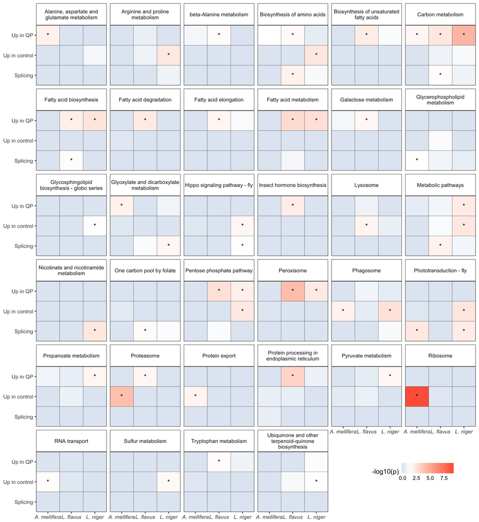

```r
kegg.plot.data <- plot.data %>% filter(grepl("KEGG", ID))
kegg.plot.data <- kegg.plot.data[kegg.plot.data$ID %in% (kegg.plot.data %>%
                                            group_by(ID) %>%
                                            summarise(min.p = min(Pvalue)) %>%
                                            filter(min.p < 0.05) %>% .$ID), ] %>%
  left_join(big.table %>% select(ID, Term), by = "ID") %>%
  distinct() %>% mutate(sig = " ", sig = replace(sig, Pvalue<0.05, "*"))

kegg.plot <- kegg.plot.data %>% ggplot(aes(x = species, y = type, fill = -log10(Pvalue+0.000000001))) +
  geom_tile(colour="black") +
  geom_text(aes(label=sig)) +
  facet_wrap(~Term, labeller = labeller(Term = label_wrap_gen(30))) +
  scale_fill_gradient2(name = "-log10(p)", low = "steelblue", mid = "white", high = "tomato", midpoint = -log10(0.05)) +
  theme_bw() + scale_x_discrete(expand=c(0,0)) + scale_y_discrete(expand=c(0,0)) +
  theme(panel.grid = element_blank(),
        strip.background = element_rect(fill = "white"),
        axis.text.x = element_text(face = "italic"),
        legend.position = c(12/14, 1/12), legend.direction = "horizontal") +
  xlab(NULL) + ylab(NULL)
ggsave(kegg.plot, file = "figures/KEGG summary fig.pdf", height = 8, width = 12)
kegg.plot
```

### Summary figure of GO results

**Figure 3**: A summary of the GO enrichment tests: GO terms with multiple red squares were significantly enriched in multiple tests. For brevity, the figure only shows GO terms for which two or more enrichment tests returned a significant result. The figure can be interpreted as for Figure S7.

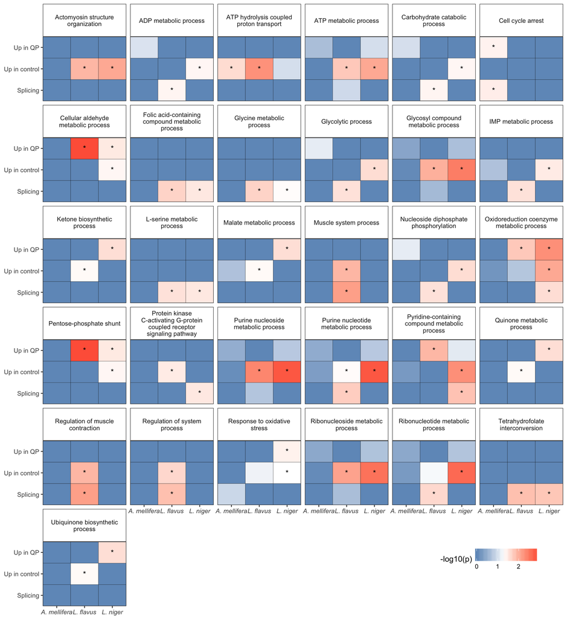

```r
go.plot.data <- plot.data %>% filter(grepl("GO", ID))
go.plot.data <- go.plot.data[go.plot.data$ID %in% (go.plot.data %>%
                                                     group_by(ID) %>%
                                                     summarise(n.sig = sum(Pvalue<0.05)) %>%
                                                     filter(n.sig >1) %>% .$ID), ] %>%
  left_join(big.table %>% select(ID, Term), by = "ID") %>% distinct() %>%
  mutate(sig = " ", sig = replace(sig, Pvalue<0.05, "*"))
go.plot.data$Term <- with(go.plot.data, paste(toupper(substr(Term, 1, 1)), substr(Term, 2, nchar(Term)), sep=""))

go.plot <- go.plot.data %>%
  filter(Term != "Purine nucleoside monophosphate metabolic process", # omit these 'child' GO terms for brevity
         Term != "Purine nucleoside diphosphate metabolic process",
         Term != "Purine nucleoside triphosphate metabolic process",
         Term != "Ribonucleoside monophosphate metabolic process",
         Term != "Ribonucleoside diphosphate metabolic process",
         Term != "Ribonucleoside triphosphate metabolic process") %>%
  ggplot(aes(x = species, y = type, fill = -log10(Pvalue + 0.000000001))) +
  geom_tile(colour="black") +
  geom_text(aes(label=sig)) +
  facet_wrap(~Term, labeller = labeller(Term = label_wrap_gen(25))) +
  scale_fill_gradient2(name = "-log10(p)", low = "steelblue", mid = "white", high = "tomato", midpoint = -log10(0.05)) +
  theme_bw() + scale_x_discrete(expand=c(0,0)) + scale_y_discrete(expand=c(0,0)) +
  theme(panel.grid = element_blank(),
        strip.background = element_rect(fill = "white"),
        axis.text.x = element_text(face = "italic"),
        legend.position = c(12/14, 1/12), legend.direction = "horizontal") +
  xlab(NULL) + ylab(NULL)
ggsave(go.plot, file = "figures/GO summary fig.pdf", height = 10, width = 13)
go.plot
```

## KEGG and GO enrichment for transcriptional modules

### Enriched KEGG and GO terms in module 1

**Table S25**: Results of KEGG and GO enrichment analysis for the genes in Module 1. The gene universe was defined as all genes for which we found an ortholog in all four species.

```r
GO.and.KEGG.enrichment(genes.in.module(1), gene.universe.modules, ontology = "BP")
```

| ID | Pvalue | OddsRatio | ExpCount | Count | Size | Term |
| --- | --- | --- | --- | --- | --- | --- |
| KEGG:03440 | 0.00028 | 15.874 | 6.389 | 13 | 14 | Homologous recombination |
| KEGG:03460 | 0.00119 | 13.377 | 5.477 | 11 | 12 | Fanconi anemia pathway |
| KEGG:03420 | 0.00453 | 6.677 | 5.933 | 11 | 13 | Nucleotide excision repair |
| KEGG:03040 | 0.00897 | 2.075 | 23.275 | 32 | 51 | Spliceosome |
| KEGG:03430 | 0.01946 | 8.443 | 3.651 | 7 | 8 | Mismatch repair |
| GO:0090304 | 0.00000 | 2.022 | 118.799 | 153 | 256 | nucleic acid metabolic process |
| GO:0033554 | 0.00029 | 3.901 | 15.778 | 26 | 34 | cellular response to stress |
| GO:0006281 | 0.00036 | 4.106 | 14.386 | 24 | 31 | DNA repair |
| GO:0044260 | 0.00050 | 1.521 | 192.120 | 219 | 414 | cellular macromolecule metabolic process |
| GO:0006396 | 0.00147 | 2.556 | 22.393 | 33 | 49 | RNA processing |
| GO:0046483 | 0.00159 | 1.488 | 153.139 | 176 | 330 | heterocycle metabolic process |
| GO:1901360 | 0.00193 | 1.475 | 154.531 | 177 | 333 | organic cyclic compound metabolic process |
| GO:0006725 | 0.00295 | 1.450 | 153.603 | 175 | 331 | cellular aromatic compound metabolic process |
| GO:0006397 | 0.00372 | 3.119 | 13.458 | 21 | 29 | mRNA processing |
| GO:0016043 | 0.00483 | 1.819 | 41.765 | 54 | 90 | cellular component organization |
| GO:0051276 | 0.00958 | Inf | 2.773 | 6 | 6 | chromosome organization |
| GO:0009968 | 0.02130 | Inf | 2.320 | 5 | 5 | negative regulation of signal transduction |
| GO:0006310 | 0.02130 | Inf | 2.320 | 5 | 5 | DNA recombination |
| GO:0006399 | 0.02270 | 2.168 | 15.778 | 22 | 34 | tRNA metabolic process |
| GO:0016192 | 0.02379 | 1.875 | 22.739 | 30 | 49 | vesicle-mediated transport |
| GO:0009987 | 0.03746 | 1.320 | 347.536 | 360 | 769 | cellular process |
| GO:0000280 | 0.04161 | 7.000 | 3.248 | 6 | 7 | nuclear division |
| GO:0061025 | 0.04161 | 7.000 | 3.248 | 6 | 7 | membrane fusion |
| GO:0071103 | 0.04608 | Inf | 1.856 | 4 | 4 | DNA conformation change |
| GO:0043161 | 0.04608 | Inf | 1.856 | 4 | 4 | proteasome-mediated ubiquitin-dependent protein catabolic process |
| GO:0098813 | 0.04608 | Inf | 1.856 | 4 | 4 | nuclear chromosome segregation |
| GO:0000070 | 0.04608 | Inf | 1.856 | 4 | 4 | mitotic sister chromatid segregation |
| GO:0000075 | 0.04608 | Inf | 1.856 | 4 | 4 | cell cycle checkpoint |
| GO:0051304 | 0.04608 | Inf | 1.856 | 4 | 4 | chromosome separation |
| GO:0019941 | 0.04718 | 1.963 | 14.850 | 20 | 32 | modification-dependent protein catabolic process |
| GO:0006807 | 0.04937 | 1.235 | 205.114 | 219 | 442 | nitrogen compound metabolic process |

### Enriched KEGG and GO terms in module 2

**Table S26**: Results of KEGG and GO enrichment analysis for the genes in Module 2. The gene universe was defined as all genes for which we found an ortholog in all four species.

```r
GO.and.KEGG.enrichment(genes.in.module(2), gene.universe.modules, ontology = "BP")
```

| ID | Pvalue | OddsRatio | ExpCount | Count | Size | Term |
| --- | --- | --- | --- | --- | --- | --- |
| KEGG:03010 | 0.00000 | 13.284 | 12.037 | 43 | 58 | Ribosome |
| KEGG:03050 | 0.00426 | 3.170 | 5.603 | 12 | 27 | Proteasome |
| KEGG:00051 | 0.00538 | 9.740 | 1.453 | 5 | 7 | Fructose and mannose metabolism |
| KEGG:00590 | 0.00759 | 15.532 | 1.038 | 4 | 5 | Arachidonic acid metabolism |
| KEGG:04150 | 0.04175 | 2.048 | 7.264 | 12 | 35 | mTOR signaling pathway |
| GO:0006518 | 0.00000 | 5.801 | 16.624 | 46 | 87 | peptide metabolic process |
| GO:0043604 | 0.00000 | 5.789 | 16.242 | 45 | 85 | amide biosynthetic process |
| GO:0006412 | 0.00000 | 5.370 | 15.548 | 42 | 82 | translation |
| GO:1901566 | 0.00000 | 3.395 | 27.134 | 56 | 142 | organonitrogen compound biosynthetic process |
| GO:0009059 | 0.00064 | 1.798 | 43.949 | 62 | 230 | macromolecule biosynthetic process |
| GO:0018193 | 0.00281 | 6.097 | 2.293 | 7 | 12 | peptidyl-amino acid modification |
| GO:0044249 | 0.01080 | 1.484 | 58.911 | 73 | 312 | cellular biosynthetic process |
| GO:0034641 | 0.02782 | 1.367 | 76.433 | 89 | 400 | cellular nitrogen compound metabolic process |
| GO:0071704 | 0.02957 | 1.362 | 120.382 | 133 | 630 | organic substance metabolic process |
| GO:0006457 | 0.03428 | 2.443 | 4.777 | 9 | 25 | protein folding |
| GO:0044267 | 0.03616 | 1.674 | 15.210 | 22 | 93 | cellular protein metabolic process |
| GO:0006414 | 0.03637 | Inf | 0.382 | 2 | 2 | translational elongation |
| GO:0044205 | 0.03637 | Inf | 0.382 | 2 | 2 | ‘de novo’ UMP biosynthetic process |
| GO:0018095 | 0.03637 | Inf | 0.382 | 2 | 2 | protein polyglutamylation |
| GO:0044712 | 0.03981 | 2.752 | 3.439 | 7 | 18 | single-organism catabolic process |
| GO:0044238 | 0.04036 | 1.327 | 112.166 | 124 | 587 | primary metabolic process |
| GO:0044272 | 0.04783 | 4.296 | 1.529 | 4 | 8 | sulfur compound biosynthetic process |

### Enriched KEGG and GO terms in module 3

**Table S27**: Results of KEGG and GO enrichment analysis for the genes in Module 3. The gene universe was defined as all genes for which we found an ortholog in all four species.

```r
GO.and.KEGG.enrichment(genes.in.module(3), gene.universe.modules, ontology = "BP")
```

| ID | Pvalue | OddsRatio | ExpCount | Count | Size | Term |
| --- | --- | --- | --- | --- | --- | --- |
| KEGG:04080 | 0.00001 | 24.165 | 0.576 | 6 | 11 | Neuroactive ligand-receptor interaction |
| KEGG:00020 | 0.00964 | 5.916 | 0.890 | 4 | 17 | Citrate cycle (TCA cycle) |
| KEGG:00130 | 0.01509 | 18.727 | 0.209 | 2 | 4 | Ubiquinone and other terpenoid-quinone biosynthesis |
| KEGG:01200 | 0.01696 | 3.351 | 2.146 | 6 | 41 | Carbon metabolism |
| KEGG:04013 | 0.01961 | 3.720 | 1.623 | 5 | 31 | MAPK signaling pathway - fly |
| KEGG:00350 | 0.02431 | 12.473 | 0.262 | 2 | 5 | Tyrosine metabolism |
| GO:0023052 | 0.00000 | 4.609 | 11.210 | 31 | 154 | signaling |
| GO:0044763 | 0.00000 | 3.199 | 29.517 | 50 | 414 | single-organism cellular process |
| GO:0050896 | 0.00000 | 3.298 | 14.195 | 31 | 195 | response to stimulus |
| GO:0050789 | 0.00000 | 3.052 | 19.727 | 38 | 271 | regulation of biological process |
| GO:0035556 | 0.00001 | 4.078 | 7.061 | 20 | 97 | intracellular signal transduction |
| GO:0007265 | 0.00021 | 8.047 | 1.383 | 7 | 19 | Ras protein signal transduction |
| GO:0051056 | 0.00030 | 7.420 | 1.456 | 7 | 20 | regulation of small GTPase mediated signal transduction |
| GO:0007218 | 0.00037 | Inf | 0.218 | 3 | 3 | neuropeptide signaling pathway |
| GO:0009966 | 0.00068 | 5.280 | 2.111 | 8 | 29 | regulation of signal transduction |
| GO:0007165 | 0.00131 | 4.149 | 2.841 | 9 | 48 | signal transduction |
| GO:0035023 | 0.00146 | 8.425 | 0.946 | 5 | 13 | regulation of Rho protein signal transduction |
| GO:0007267 | 0.02266 | 6.578 | 0.655 | 3 | 9 | cell-cell signaling |
| GO:0099537 | 0.02852 | 13.038 | 0.291 | 2 | 4 | trans-synaptic signaling |
| GO:0006836 | 0.02852 | 13.038 | 0.291 | 2 | 4 | neurotransmitter transport |
| GO:0007268 | 0.02852 | 13.038 | 0.291 | 2 | 4 | chemical synaptic transmission |
| GO:0006099 | 0.03070 | 5.633 | 0.728 | 3 | 10 | tricarboxylic acid cycle |
| GO:0008219 | 0.04531 | 8.684 | 0.364 | 2 | 5 | cell death |
| GO:0006915 | 0.04531 | 8.684 | 0.364 | 2 | 5 | apoptotic process |

### Enriched KEGG and GO terms in module 4

**Table S28**: Results of KEGG and GO enrichment analysis for the genes in Module 4. The gene universe was defined as all genes for which we found an ortholog in all four species.

```r
GO.and.KEGG.enrichment(genes.in.module(4), gene.universe.modules, ontology = "BP")
```

| ID | Pvalue | OddsRatio | ExpCount | Count | Size | Term |
| --- | --- | --- | --- | --- | --- | --- |
| KEGG:04141 | 0.00000 | 4.973 | 7.152 | 22 | 59 | Protein processing in endoplasmic reticulum |
| KEGG:01200 | 0.00003 | 4.591 | 4.970 | 15 | 41 | Carbon metabolism |
| KEGG:01212 | 0.00014 | 6.929 | 2.303 | 9 | 19 | Fatty acid metabolism |
| KEGG:01100 | 0.00084 | 1.857 | 41.455 | 58 | 342 | Metabolic pathways |
| KEGG:01040 | 0.00094 | 29.875 | 0.606 | 4 | 5 | Biosynthesis of unsaturated fatty acids |
| KEGG:01230 | 0.00094 | 4.276 | 3.394 | 10 | 28 | Biosynthesis of amino acids |
| KEGG:00030 | 0.00141 | 7.548 | 1.455 | 6 | 12 | Pentose phosphate pathway |
| KEGG:04512 | 0.00540 | 9.938 | 0.848 | 4 | 7 | ECM-receptor interaction |
| KEGG:00061 | 0.00540 | 9.938 | 0.848 | 4 | 7 | Fatty acid biosynthesis |
| KEGG:00500 | 0.00978 | 7.445 | 0.970 | 4 | 8 | Starch and sucrose metabolism |
| KEGG:03050 | 0.01125 | 3.185 | 3.273 | 8 | 27 | Proteasome |
| KEGG:00260 | 0.01394 | 4.670 | 1.576 | 5 | 13 | Glycine, serine and threonine metabolism |
| KEGG:00565 | 0.01449 | 11.105 | 0.606 | 3 | 5 | Ether lipid metabolism |
| KEGG:03060 | 0.01598 | 5.950 | 1.091 | 4 | 9 | Protein export |
| KEGG:00520 | 0.02014 | 3.458 | 2.303 | 6 | 19 | Amino sugar and nucleotide sugar metabolism |
| KEGG:00062 | 0.02643 | 7.395 | 0.727 | 3 | 6 | Fatty acid elongation |
| KEGG:00280 | 0.03283 | 2.990 | 2.545 | 6 | 21 | Valine, leucine and isoleucine degradation |
| KEGG:00510 | 0.03447 | 4.241 | 1.333 | 4 | 11 | N-Glycan biosynthesis |
| GO:0043436 | 0.00000 | 6.352 | 6.248 | 23 | 63 | oxoacid metabolic process |
| GO:0044283 | 0.00000 | 8.797 | 2.538 | 12 | 26 | small molecule biosynthetic process |
| GO:1901607 | 0.00080 | 11.851 | 0.893 | 5 | 9 | alpha-amino acid biosynthetic process |
| GO:0006544 | 0.00095 | Inf | 0.298 | 3 | 3 | glycine metabolic process |
| GO:0046394 | 0.00122 | 9.919 | 0.953 | 5 | 10 | carboxylic acid biosynthetic process |
| GO:0055086 | 0.00134 | 3.024 | 5.951 | 14 | 60 | nucleobase-containing small molecule metabolic process |
| GO:0044723 | 0.00144 | 5.593 | 1.884 | 7 | 19 | single-organism carbohydrate metabolic process |
| GO:0006633 | 0.00147 | 9.471 | 0.992 | 5 | 10 | fatty acid biosynthetic process |
| GO:0032787 | 0.00225 | 8.094 | 1.067 | 5 | 11 | monocarboxylic acid metabolic process |
| GO:0044281 | 0.00245 | 3.062 | 4.970 | 12 | 60 | small molecule metabolic process |
| GO:0072524 | 0.00393 | 6.751 | 1.190 | 5 | 12 | pyridine-containing compound metabolic process |
| GO:0046496 | 0.00393 | 6.751 | 1.190 | 5 | 12 | nicotinamide nucleotide metabolic process |
| GO:0019637 | 0.00690 | 2.348 | 7.736 | 15 | 78 | organophosphate metabolic process |
| GO:0009069 | 0.00762 | 14.388 | 0.484 | 3 | 5 | serine family amino acid metabolic process |
| GO:0006098 | 0.00819 | 13.981 | 0.496 | 3 | 5 | pentose-phosphate shunt |
| GO:0006081 | 0.00819 | 13.981 | 0.496 | 3 | 5 | cellular aldehyde metabolic process |
| GO:0006487 | 0.00976 | Inf | 0.198 | 2 | 2 | protein N-linked glycosylation |
| GO:0006890 | 0.00976 | Inf | 0.198 | 2 | 2 | retrograde vesicle-mediated transport, Golgi to ER |
| GO:0034637 | 0.00976 | Inf | 0.198 | 2 | 2 | cellular carbohydrate biosynthetic process |
| GO:0006564 | 0.00976 | Inf | 0.198 | 2 | 2 | L-serine biosynthetic process |
| GO:0009186 | 0.00976 | Inf | 0.198 | 2 | 2 | deoxyribonucleoside diphosphate metabolic process |
| GO:0072350 | 0.00976 | Inf | 0.198 | 2 | 2 | tricarboxylic acid metabolic process |
| GO:0009117 | 0.01001 | 2.598 | 5.157 | 11 | 52 | nucleotide metabolic process |
| GO:0006732 | 0.01019 | 4.894 | 1.440 | 5 | 15 | coenzyme metabolic process |
| GO:1901576 | 0.01144 | 1.661 | 31.143 | 42 | 319 | organic substance biosynthetic process |
| GO:0043413 | 0.01201 | 6.248 | 0.992 | 4 | 10 | macromolecule glycosylation |
| GO:0006796 | 0.01390 | 2.130 | 8.331 | 15 | 84 | phosphate-containing compound metabolic process |
| GO:0008652 | 0.01451 | 9.490 | 0.585 | 3 | 6 | cellular amino acid biosynthetic process |
| GO:0006090 | 0.01520 | 9.311 | 0.595 | 3 | 6 | pyruvate metabolic process |
| GO:0006733 | 0.01568 | 4.279 | 1.587 | 5 | 16 | oxidoreduction coenzyme metabolic process |
| GO:0044255 | 0.01737 | 2.825 | 3.471 | 8 | 35 | cellular lipid metabolic process |
| GO:0019318 | 0.01746 | 5.350 | 1.091 | 4 | 11 | hexose metabolic process |
| GO:1901135 | 0.02290 | 2.030 | 8.034 | 14 | 81 | carbohydrate derivative metabolic process |
| GO:0009101 | 0.02422 | 4.676 | 1.190 | 4 | 12 | glycoprotein biosynthetic process |
| GO:0046148 | 0.02736 | 18.486 | 0.298 | 2 | 3 | pigment biosynthetic process |
| GO:0035384 | 0.02736 | 18.486 | 0.298 | 2 | 3 | thioester biosynthetic process |
| GO:0009133 | 0.02736 | 18.486 | 0.298 | 2 | 3 | nucleoside diphosphate biosynthetic process |
| GO:0006094 | 0.02736 | 18.486 | 0.298 | 2 | 3 | gluconeogenesis |
| GO:0006085 | 0.02736 | 18.486 | 0.298 | 2 | 3 | acetyl-CoA biosynthetic process |
| GO:0046364 | 0.02736 | 18.486 | 0.298 | 2 | 3 | monosaccharide biosynthetic process |
| GO:0033014 | 0.02736 | 18.486 | 0.298 | 2 | 3 | tetrapyrrole biosynthetic process |
| GO:0044249 | 0.03042 | 1.529 | 31.017 | 40 | 318 | cellular biosynthetic process |
| GO:0006629 | 0.03266 | 5.865 | 0.759 | 3 | 8 | lipid metabolic process |
| GO:0044710 | 0.03957 | 3.663 | 1.345 | 4 | 19 | single-organism metabolic process |
| GO:0006520 | 0.03989 | 2.741 | 2.623 | 6 | 28 | cellular amino acid metabolic process |
| GO:0044711 | 0.04270 | 2.163 | 4.794 | 9 | 54 | single-organism biosynthetic process |

### Enriched KEGG and GO terms in module 5

**Table S29**: Results of KEGG and GO enrichment analysis for the genes in Module 5. The gene universe was defined as all genes for which we found an ortholog in all four species.

```r
GO.and.KEGG.enrichment(genes.in.module(5), gene.universe.modules, ontology = "BP")
```

| ID | Pvalue | OddsRatio | ExpCount | Count | Size | Term |
| --- | --- | --- | --- | --- | --- | --- |
| KEGG:04120 | 0.00103 | 4.757 | 2.204 | 8 | 48 | Ubiquitin mediated proteolysis |
| KEGG:04142 | 0.00857 | 4.699 | 1.331 | 5 | 29 | Lysosome |
| KEGG:04144 | 0.01149 | 3.289 | 2.571 | 7 | 56 | Endocytosis |
| KEGG:00250 | 0.04847 | 7.174 | 0.367 | 2 | 8 | Alanine, aspartate and glutamate metabolism |
| GO:0071702 | 0.00018 | 4.080 | 4.366 | 13 | 94 | organic substance transport |
| GO:0045184 | 0.00038 | 3.945 | 4.069 | 12 | 86 | establishment of protein localization |
| GO:0006886 | 0.00061 | 4.660 | 2.555 | 9 | 54 | intracellular protein transport |
| GO:0070727 | 0.00119 | 4.173 | 2.792 | 9 | 59 | cellular macromolecule localization |
| GO:0031333 | 0.00220 | Inf | 0.095 | 2 | 2 | negative regulation of protein complex assembly |
| GO:0030835 | 0.00220 | Inf | 0.095 | 2 | 2 | negative regulation of actin filament depolymerization |
| GO:0030837 | 0.00220 | Inf | 0.095 | 2 | 2 | negative regulation of actin filament polymerization |
| GO:0051016 | 0.00220 | Inf | 0.095 | 2 | 2 | barbed-end actin filament capping |
| GO:0043242 | 0.00220 | Inf | 0.095 | 2 | 2 | negative regulation of protein complex disassembly |
| GO:0051649 | 0.00243 | 3.704 | 3.076 | 9 | 65 | establishment of localization in cell |
| GO:0065008 | 0.00546 | 4.422 | 1.703 | 6 | 36 | regulation of biological quality |
| GO:0043624 | 0.00639 | 41.840 | 0.142 | 2 | 3 | cellular protein complex disassembly |
| GO:1901879 | 0.00639 | 41.840 | 0.142 | 2 | 3 | regulation of protein depolymerization |
| GO:0032984 | 0.00639 | 41.840 | 0.142 | 2 | 3 | macromolecular complex disassembly |
| GO:0010639 | 0.00639 | 41.840 | 0.142 | 2 | 3 | negative regulation of organelle organization |
| GO:0007015 | 0.00686 | 10.622 | 0.426 | 3 | 9 | actin filament organization |
| GO:0032535 | 0.00686 | 10.622 | 0.426 | 3 | 9 | regulation of cellular component size |
| GO:0032956 | 0.00686 | 10.622 | 0.426 | 3 | 9 | regulation of actin cytoskeleton organization |
| GO:0008064 | 0.00686 | 10.622 | 0.426 | 3 | 9 | regulation of actin polymerization or depolymerization |
| GO:0046033 | 0.01240 | 20.900 | 0.189 | 2 | 4 | AMP metabolic process |
| GO:0044087 | 0.01260 | 7.952 | 0.520 | 3 | 11 | regulation of cellular component biogenesis |
| GO:0032271 | 0.01260 | 7.952 | 0.520 | 3 | 11 | regulation of protein polymerization |
| GO:0043623 | 0.02042 | 6.349 | 0.615 | 3 | 13 | cellular protein complex assembly |
| GO:0030029 | 0.02042 | 6.349 | 0.615 | 3 | 13 | actin filament-based process |
| GO:0033036 | 0.02133 | 3.617 | 1.654 | 5 | 40 | macromolecule localization |
| GO:0009168 | 0.02514 | 5.766 | 0.662 | 3 | 14 | purine ribonucleoside monophosphate biosynthetic process |
| GO:0051128 | 0.03039 | 5.281 | 0.710 | 3 | 15 | regulation of cellular component organization |
| GO:0045454 | 0.03039 | 5.281 | 0.710 | 3 | 15 | cell redox homeostasis |
| GO:0046129 | 0.03617 | 4.870 | 0.757 | 3 | 16 | purine ribonucleoside biosynthetic process |
| GO:0007010 | 0.03617 | 4.870 | 0.757 | 3 | 16 | cytoskeleton organization |
| GO:0048523 | 0.04248 | 4.517 | 0.804 | 3 | 17 | negative regulation of cellular process |
| GO:0009152 | 0.04248 | 4.517 | 0.804 | 3 | 17 | purine ribonucleotide biosynthetic process |
| GO:0051125 | 0.04732 | Inf | 0.047 | 1 | 1 | regulation of actin nucleation |
| GO:0015850 | 0.04732 | Inf | 0.047 | 1 | 1 | organic hydroxy compound transport |
| GO:0009607 | 0.04732 | Inf | 0.047 | 1 | 1 | response to biotic stimulus |
| GO:0030245 | 0.04732 | Inf | 0.047 | 1 | 1 | cellulose catabolic process |
| GO:0051273 | 0.04732 | Inf | 0.047 | 1 | 1 | beta-glucan metabolic process |
| GO:0051707 | 0.04732 | Inf | 0.047 | 1 | 1 | response to other organism |
| GO:0044247 | 0.04732 | Inf | 0.047 | 1 | 1 | cellular polysaccharide catabolic process |
| GO:0042742 | 0.04732 | Inf | 0.047 | 1 | 1 | defense response to bacterium |
| GO:0006892 | 0.04732 | Inf | 0.047 | 1 | 1 | post-Golgi vesicle-mediated transport |
| GO:0006895 | 0.04732 | Inf | 0.047 | 1 | 1 | Golgi to endosome transport |
| GO:0009251 | 0.04732 | Inf | 0.047 | 1 | 1 | glucan catabolic process |
| GO:0007188 | 0.04732 | Inf | 0.047 | 1 | 1 | adenylate cyclase-modulating G-protein coupled receptor signaling pathway |
| GO:0032456 | 0.04732 | Inf | 0.047 | 1 | 1 | endocytic recycling |
| GO:2000601 | 0.04732 | Inf | 0.047 | 1 | 1 | positive regulation of Arp2/3 complex-mediated actin nucleation |
| GO:0030301 | 0.04732 | Inf | 0.047 | 1 | 1 | cholesterol transport |
| GO:0071586 | 0.04732 | Inf | 0.047 | 1 | 1 | CAAX-box protein processing |
| GO:0070271 | 0.04931 | 4.212 | 0.852 | 3 | 18 | protein complex biogenesis |
| GO:0071822 | 0.04931 | 4.212 | 0.852 | 3 | 18 | protein complex subunit organization |

### Enriched KEGG and GO terms in module 6

**Table S30**: Results of KEGG and GO enrichment analysis for the genes in Module 6. The gene universe was defined as all genes for which we found an ortholog in all four species.

```r
GO.and.KEGG.enrichment(genes.in.module(6), gene.universe.modules, ontology = "BP")
```

| ID | Pvalue | OddsRatio | ExpCount | Count | Size | Term |
| --- | --- | --- | --- | --- | --- | --- |
| KEGG:04140 | 0.00898 | 4.614 | 1.343 | 5 | 43 | Regulation of autophagy |
| KEGG:03410 | 0.02970 | 9.357 | 0.281 | 2 | 9 | Base excision repair |
| GO:0007264 | 0.00057 | 4.722 | 2.539 | 9 | 62 | small GTPase mediated signal transduction |
| GO:0006913 | 0.00241 | 9.251 | 0.614 | 4 | 15 | nucleocytoplasmic transport |
| GO:0050789 | 0.00241 | 2.559 | 11.096 | 20 | 271 | regulation of biological process |
| GO:0000394 | 0.00479 | 48.977 | 0.123 | 2 | 3 | RNA splicing, via endonucleolytic cleavage and ligation |
| GO:0007165 | 0.00485 | 2.719 | 6.142 | 13 | 150 | signal transduction |
| GO:0023052 | 0.00614 | 2.631 | 6.306 | 13 | 154 | signaling |
| GO:0050896 | 0.00745 | 2.428 | 7.985 | 15 | 195 | response to stimulus |
| GO:0008033 | 0.03403 | 4.948 | 0.737 | 3 | 18 | tRNA processing |
| GO:0006420 | 0.04095 | Inf | 0.041 | 1 | 1 | arginyl-tRNA aminoacylation |
| GO:0000379 | 0.04095 | Inf | 0.041 | 1 | 1 | tRNA-type intron splice site recognition and cleavage |
| GO:0043086 | 0.04095 | Inf | 0.041 | 1 | 1 | negative regulation of catalytic activity |
| GO:0010923 | 0.04095 | Inf | 0.041 | 1 | 1 | negative regulation of phosphatase activity |
| GO:0045936 | 0.04095 | Inf | 0.041 | 1 | 1 | negative regulation of phosphate metabolic process |
| GO:0016559 | 0.04095 | Inf | 0.041 | 1 | 1 | peroxisome fission |
| GO:0048034 | 0.04095 | Inf | 0.041 | 1 | 1 | heme O biosynthetic process |
| GO:0000012 | 0.04095 | Inf | 0.041 | 1 | 1 | single strand break repair |
| GO:0051336 | 0.04095 | Inf | 0.041 | 1 | 1 | regulation of hydrolase activity |
| GO:0006384 | 0.04095 | Inf | 0.041 | 1 | 1 | transcription initiation from RNA polymerase III promoter |
| GO:0015031 | 0.04682 | 2.370 | 3.399 | 7 | 83 | protein transport |

### Enriched KEGG and GO terms in module 7

**Table S31**: Results of KEGG and GO enrichment analysis for the genes in Module 7. The gene universe was defined as all genes for which we found an ortholog in all four species.

```r
GO.and.KEGG.enrichment(genes.in.module(7), gene.universe.modules, ontology = "BP")
```

| ID | Pvalue | OddsRatio | ExpCount | Count | Size | Term |
| --- | --- | --- | --- | --- | --- | --- |
| KEGG:04320 | 0.00313 | 14.022 | 0.321 | 3 | 10 | Dorso-ventral axis formation |
| KEGG:04068 | 0.00434 | 7.427 | 0.707 | 4 | 22 | FoxO signaling pathway |
| KEGG:00511 | 0.01389 | 15.909 | 0.193 | 2 | 6 | Other glycan degradation |
| KEGG:04070 | 0.02071 | 6.082 | 0.611 | 3 | 19 | Phosphatidylinositol signaling system |
| KEGG:00562 | 0.02720 | 5.396 | 0.675 | 3 | 21 | Inositol phosphate metabolism |
| GO:0007017 | 0.02023 | 6.159 | 0.606 | 3 | 18 | microtubule-based process |
| GO:0007165 | 0.02140 | 2.439 | 5.050 | 10 | 150 | signal transduction |
| GO:0022610 | 0.02348 | 5.768 | 0.640 | 3 | 19 | biological adhesion |
| GO:0023052 | 0.02543 | 2.361 | 5.185 | 10 | 154 | signaling |
| GO:0007156 | 0.02719 | 10.057 | 0.269 | 2 | 8 | homophilic cell adhesion via plasma membrane adhesion molecules |
| GO:0098609 | 0.02719 | 10.057 | 0.269 | 2 | 8 | cell-cell adhesion |
| GO:0034214 | 0.03367 | Inf | 0.034 | 1 | 1 | protein hexamerization |
| GO:0031117 | 0.03367 | Inf | 0.034 | 1 | 1 | positive regulation of microtubule depolymerization |
| GO:0043243 | 0.03367 | Inf | 0.034 | 1 | 1 | positive regulation of protein complex disassembly |

### Enriched KEGG and GO terms in module 8

**Table S32**: Results of KEGG and GO enrichment analysis for the genes in Module 8. The gene universe was defined as all genes for which we found an ortholog in all four species.

```r
GO.and.KEGG.enrichment(genes.in.module(8), gene.universe.modules, ontology = "BP")
```

| ID | Pvalue | OddsRatio | ExpCount | Count | Size | Term |
| --- | --- | --- | --- | --- | --- | --- |
| KEGG:00190 | 0.000 | 390.754 | 1.305 | 26 | 49 | Oxidative phosphorylation |
| KEGG:01100 | 0.000 | 66.522 | 9.107 | 28 | 342 | Metabolic pathways |
| GO:0009126 | 0.00000 | 87.347 | 0.300 | 8 | 22 | purine nucleoside monophosphate metabolic process |
| GO:0046034 | 0.00000 | 117.688 | 0.205 | 7 | 15 | ATP metabolic process |
| GO:0006163 | 0.00000 | 67.683 | 0.355 | 8 | 26 | purine nucleotide metabolic process |
| GO:0042278 | 0.00000 | 67.683 | 0.355 | 8 | 26 | purine nucleoside metabolic process |
| GO:0009161 | 0.00000 | 67.683 | 0.355 | 8 | 26 | ribonucleoside monophosphate metabolic process |
| GO:0009144 | 0.00000 | 85.352 | 0.246 | 7 | 18 | purine nucleoside triphosphate metabolic process |
| GO:0009259 | 0.00000 | 55.169 | 0.409 | 8 | 30 | ribonucleotide metabolic process |
| GO:0009119 | 0.00000 | 50.476 | 0.437 | 8 | 32 | ribonucleoside metabolic process |
| GO:0009199 | 0.00000 | 72.087 | 0.273 | 7 | 20 | ribonucleoside triphosphate metabolic process |
| GO:0015986 | 0.00000 | 541.500 | 0.082 | 5 | 6 | ATP synthesis coupled proton transport |
| GO:1901657 | 0.00000 | 48.411 | 0.450 | 8 | 33 | glycosyl compound metabolic process |
| GO:0009168 | 0.00000 | 89.667 | 0.191 | 6 | 14 | purine ribonucleoside monophosphate biosynthetic process |
| GO:0009206 | 0.00000 | 180.167 | 0.109 | 5 | 8 | purine ribonucleoside triphosphate biosynthetic process |
| GO:0046129 | 0.00000 | 71.600 | 0.218 | 6 | 16 | purine ribonucleoside biosynthetic process |
| GO:0009152 | 0.00000 | 65.030 | 0.232 | 6 | 17 | purine ribonucleotide biosynthetic process |
| GO:0009124 | 0.00000 | 54.923 | 0.259 | 6 | 19 | nucleoside monophosphate biosynthetic process |
| GO:0009142 | 0.00000 | 107.900 | 0.136 | 5 | 10 | nucleoside triphosphate biosynthetic process |
| GO:0072522 | 0.00000 | 50.952 | 0.273 | 6 | 20 | purine-containing compound biosynthetic process |
| GO:0006753 | 0.00000 | 26.387 | 0.723 | 8 | 53 | nucleoside phosphate metabolic process |
| GO:0009163 | 0.00000 | 44.500 | 0.300 | 6 | 22 | nucleoside biosynthetic process |
| GO:0046390 | 0.00000 | 44.500 | 0.300 | 6 | 22 | ribose phosphate biosynthetic process |
| GO:1902600 | 0.00000 | 76.929 | 0.164 | 5 | 12 | hydrogen ion transmembrane transport |
| GO:0098660 | 0.00000 | 76.929 | 0.164 | 5 | 12 | inorganic ion transmembrane transport |
| GO:0098655 | 0.00000 | 76.929 | 0.164 | 5 | 12 | cation transmembrane transport |
| GO:0006818 | 0.00000 | 67.250 | 0.177 | 5 | 13 | hydrogen transport |
| GO:0015672 | 0.00000 | 48.773 | 0.218 | 5 | 16 | monovalent inorganic cation transport |
| GO:0009165 | 0.00000 | 25.143 | 0.464 | 6 | 34 | nucleotide biosynthetic process |
| GO:0006793 | 0.00000 | 14.946 | 1.160 | 8 | 85 | phosphorus metabolic process |
| GO:0055085 | 0.00001 | 18.865 | 0.587 | 6 | 43 | transmembrane transport |
| GO:0044281 | 0.00002 | 10.456 | 1.979 | 9 | 145 | small molecule metabolic process |
| GO:0006811 | 0.00003 | 21.180 | 0.409 | 5 | 30 | ion transport |
| GO:0015980 | 0.00004 | 32.485 | 0.218 | 4 | 16 | energy derivation by oxidation of organic compounds |
| GO:1902578 | 0.00020 | 13.050 | 0.614 | 5 | 45 | single-organism localization |
| GO:0044711 | 0.00045 | 8.719 | 1.133 | 6 | 83 | single-organism biosynthetic process |
| GO:0042773 | 0.00052 | 166.615 | 0.041 | 2 | 3 | ATP synthesis coupled electron transport |
| GO:1901564 | 0.00138 | 5.740 | 2.566 | 8 | 188 | organonitrogen compound metabolic process |
| GO:0015991 | 0.00465 | 27.641 | 0.109 | 2 | 8 | ATP hydrolysis coupled proton transport |
| GO:0022904 | 0.01186 | Inf | 0.012 | 1 | 1 | respiratory electron transport chain |
| GO:0016310 | 0.01244 | 15.007 | 0.177 | 2 | 13 | phosphorylation |
| GO:0034244 | 0.01365 | Inf | 0.014 | 1 | 1 | negative regulation of transcription elongation from RNA polymerase II promoter |
| GO:0032784 | 0.01365 | Inf | 0.014 | 1 | 1 | regulation of DNA-templated transcription, elongation |
| GO:0006122 | 0.01365 | Inf | 0.014 | 1 | 1 | mitochondrial electron transport, ubiquinol to cytochrome c |
| GO:0051234 | 0.01424 | 3.752 | 2.894 | 7 | 212 | establishment of localization |
| GO:0006139 | 0.02489 | 3.325 | 4.058 | 8 | 318 | nucleobase-containing compound metabolic process |
| GO:0008152 | 0.02575 | 4.424 | 8.981 | 13 | 658 | metabolic process |
| GO:1902679 | 0.02712 | 77.357 | 0.027 | 1 | 2 | negative regulation of RNA biosynthetic process |
| GO:0044208 | 0.02712 | 77.357 | 0.027 | 1 | 2 | ‘de novo’ AMP biosynthetic process |
| GO:0045934 | 0.02712 | 77.357 | 0.027 | 1 | 2 | negative regulation of nucleobase-containing compound metabolic process |
| GO:0009890 | 0.02712 | 77.357 | 0.027 | 1 | 2 | negative regulation of biosynthetic process |
| GO:0045892 | 0.02712 | 77.357 | 0.027 | 1 | 2 | negative regulation of transcription, DNA-templated |
| GO:0010605 | 0.02712 | 77.357 | 0.027 | 1 | 2 | negative regulation of macromolecule metabolic process |
| GO:0022900 | 0.03255 | 49.136 | 0.033 | 1 | 3 | electron transport chain |
| GO:0055114 | 0.03654 | 39.556 | 0.037 | 1 | 4 | oxidation-reduction process |

### Enriched KEGG and GO terms in module 9

**Table S33**: Results of KEGG and GO enrichment analysis for the genes in Module 9. The gene universe was defined as all genes for which we found an ortholog in all four species.

```r
GO.and.KEGG.enrichment(genes.in.module(9), gene.universe.modules, ontology = "BP")
```

| ID | Pvalue | OddsRatio | ExpCount | Count | Size | Term |
| --- | --- | --- | --- | --- | --- | --- |
| KEGG:00230 | 0.00825 | 9.885 | 0.455 | 3 | 55 | Purine metabolism |
| KEGG:00430 | 0.01647 | 134.875 | 0.017 | 1 | 2 | Taurine and hypotaurine metabolism |
| KEGG:00981 | 0.04868 | 26.875 | 0.050 | 1 | 6 | Insect hormone biosynthesis |
| GO:0006275 | 0.01632 | 136.125 | 0.016 | 1 | 2 | regulation of DNA replication |
| GO:0035556 | 0.03782 | 5.298 | 0.794 | 3 | 97 | intracellular signal transduction |

## Inspect the gene list for the pheromone-sensitive module 4

**Table S34**: List of all the genes in Module 4, ranked by their within-module connectivity, *k*. The latter four columns give the Log$_2$ fold-change in expression in response to queen pheromone in each of the four species.

```r
inspect.module.genes(4) %>%
  mutate(am_fc=log2(am_fc), bt_fc=log2(bt_fc), lf_fc=log2(lf_fc), ln_fc=log2(ln_fc)) %>%
  rename(Gene=gene, Name=name) %>%
  kable.table()
```

| Gene | Name | k | am_fc | bt_fc | lf_fc | ln_fc |
| --- | --- | --- | --- | --- | --- | --- |
| GB44431 | 26S protease regulatory subunit 4 isoform 1 | 44.223556 | 0.2068368 | -0.0420157 | -0.4280960 | -0.0088204 |
| GB49337 | 26S proteasome non-ATPase regulatory subunit 13 | 42.984225 | 0.1764581 | -0.0655698 | -0.2607125 | -0.5605728 |
| GB50750 | coatomer subunit delta isoform 2 | 42.890303 | -0.0312791 | -0.0288217 | -0.0588197 | -0.0489833 |
| GB45720 | proteasome subunit alpha type-7-1-like | 41.581027 | 0.1530987 | -0.0949419 | -0.0722067 | 0.0630901 |
| GB50242 | 26S proteasome non-ATPase regulatory subunit 4 | 41.384303 | 0.2213651 | 0.0631539 | -0.1328648 | 0.5944635 |
| GB53174 | programmed cell death 6-interacting protein isoform X1 | 41.242520 | -0.0756447 | -0.0159918 | -0.0466398 | -0.0545396 |
| GB47189 | H(+)/Cl(-) exchange transporter 3-like isoform X2 | 41.034107 | 0.0346407 | -0.0154327 | -0.1018644 | -0.0454175 |
| GB50252 | GTP-binding protein SAR1b-like isoform X4 | 40.648326 | 0.3208936 | -0.0667845 | -0.0210473 | -0.2223932 |
| 102656372 | tropinone reductase 2-like | 39.868937 | 0.1120373 | 0.0340800 | 0.3238888 | 0.4926542 |
| GB53812 | prolyl endopeptidase-like isoformX1 | 39.532524 | -0.0804557 | -0.0489813 | -0.0926730 | -0.0238204 |
| GB45567 | E3 ubiquitin-protein ligase MARCH5 isoform X5 | 39.470727 | -0.0551062 | 0.0346992 | 0.4749971 | 0.0134325 |
| GB41649 | E3 ubiquitin-protein ligase MARCH6 | 39.278828 | -0.0462292 | -0.0638063 | -0.0682451 | 0.0497685 |
| GB43819 | ATPase ASNA1 homolog | 39.180343 | 0.3773737 | -0.0065874 | -0.1431066 | -0.0100659 |
| GB44941 | eukaryotic peptide chain release factor GTP-binding subunit ERF3A | 39.104220 | -0.0593707 | 0.0722754 | -0.0148940 | -0.1104174 |
| GB53690 | protein transport protein Sec31A | 38.707647 | -0.0073805 | 0.0306890 | -0.1181363 | -0.0320893 |
| GB48643 | STT3, subunit of the oligosaccharyltransferase complex, homolog B | 37.962742 | 0.1934304 | 0.0005876 | -0.1604664 | -0.0954778 |
| GB50348 | bleomycin hydrolase-like isoform X2 | 37.858985 | -0.0331317 | 0.0361318 | -0.0548069 | 0.0615163 |
| GB43706 | probable trans-2-enoyl-CoA reductase, mitochondrial-like | 37.473883 | -0.0105284 | 0.0051152 | -0.0134324 | 0.0351066 |
| GB40775 | apoptosis-inducing factor 1, mitochondrial | 36.869445 | 0.2000561 | 0.1909935 | 0.3170325 | 0.0325652 |
| 411789 | protein extra bases | 36.857043 | 0.1887237 | 0.0207032 | -0.1285144 | 0.1008955 |
| GB40483 | xyloside xylosyltransferase 1-like | 36.852931 | 0.0301872 | 0.0061033 | -0.0806551 | 0.0684976 |
| GB41617 | methylcrotonoyl-CoA carboxylase beta chain, mitochondrial-like isoform X2 | 36.788246 | 0.1487599 | -0.1687086 | -0.2389065 | -0.0591055 |
| GB50289 | signal recognition particle 54 kDa protein-like | 36.640755 | 0.0039203 | -0.0010764 | -0.0138630 | -0.0199337 |
| GB50274 | transitional endoplasmic reticulum ATPase TER94 | 36.259304 | 0.5435617 | -0.1180270 | -0.3064504 | -0.0779525 |
| GB47540 | putative leucine-rich repeat-containing protein DDB_G0290503 isoform X2 | 36.214750 | 0.2775390 | 0.0232034 | -0.1293343 | 0.0217957 |
| GB47573 | T-complex protein 1 subunit theta-like | 36.082403 | 0.1562527 | 0.0513066 | -0.0207824 | -0.0623897 |
| GB52675 | 26S proteasome non-ATPase regulatory subunit 12 | 35.929513 | 0.2312931 | 0.0482900 | -0.0951427 | 0.7829533 |
| GB42355 | asparagine–tRNA ligase, cytoplasmic-like | 35.911929 | 0.1286098 | 0.1015732 | -0.1220399 | -0.0430047 |
| GB42329 | segmentation protein cap’n’collar-like isoform X4 | 35.867197 | -0.2192666 | -0.1006952 | -0.1213930 | 0.6014040 |
| GB55494 | probable nucleolar GTP-binding protein 1-like isoform 1 | 35.759099 | 0.0447120 | 0.0957711 | 3.8215256 | -0.1220854 |

[output cut: 258 more lines]

## Inspect the gene list for the pheromone-sensitive module 9

**Table S35**: List of all the genes in Module 9, ranked by their within-module connectivity, *k*. The latter four columns give the Log$_2$ fold-change in expression in response to queen pheromone in each of the four species.

```r
inspect.module.genes(9) %>%
  mutate(am_fc=log2(am_fc), bt_fc=log2(bt_fc), lf_fc=log2(lf_fc), ln_fc=log2(ln_fc)) %>%
  rename(Gene=gene, Name=name) %>%
  kable.table()
```

| Gene | Name | k | am_fc | bt_fc | lf_fc | ln_fc |
| --- | --- | --- | --- | --- | --- | --- |
| GB49598 | RNA-binding protein Rsf1 | 3.4281703 | 0.3056885 | -0.0032899 | 0.1101417 | 0.0851146 |
| GB49355 | uncharacterized protein LOC100576266 isoform X2 | 3.2620545 | 0.3093869 | 0.0572808 | -0.1561239 | 0.1319324 |
| GB51008 | metaxin-2-like isoform 2 | 3.2002938 | 0.4439731 | -0.1469924 | 0.0424195 | 0.1446767 |
| GB52735 | DAZ-associated protein 2-like isoform X2 | 2.9721946 | 0.2871285 | 0.0231294 | 0.0623909 | -0.1752350 |
| GB55970 | proliferating cell nuclear antigen | 2.8130746 | 0.3776271 | 0.2351576 | 0.0776321 | 0.0776232 |
| 551833 | PAXIP1-associated glutamate-rich protein 1-like isoform 2 | 2.7565876 | 0.4962252 | 0.0926024 | 0.0590149 | 0.2492689 |
| GB43092 | cyclin-dependent kinase 5 | 2.5960809 | 0.3844390 | 0.0216430 | 0.0951021 | 0.1433308 |
| GB55381 | centrosomal protein of 97 kDa isoform X2 | 2.5582953 | 0.2955124 | -0.0548547 | 0.1869490 | 0.1357882 |
| GB43232 | transmembrane protein 222-like isoform 1 | 2.3398175 | 0.5861394 | 0.0458418 | 0.1933063 | 0.2422045 |
| GB50724 | peptidyl-tRNA hydrolase 2, mitochondrial-like isoform 1 | 2.2475846 | 0.7085344 | -0.0764084 | 0.0647428 | 0.1173188 |
| GB51226 | tyrosine-protein kinase CSK isoform X4 | 2.2239789 | 0.5181445 | 0.0036483 | 0.2021335 | 0.1570482 |
| GB56003 | methyltransferase-like protein 14 homolog | 2.2171705 | 0.3353470 | 0.1482768 | 0.1276493 | 0.1038143 |
| GB48128 | DNA-directed RNA polymerase III subunit RPC8-like isoform 1 | 2.1261420 | 0.7927715 | 0.1807240 | -0.1997985 | 0.1943152 |
| GB42319 | uncharacterized protein LOC409105 isoform 1 | 2.1081864 | 0.7613151 | -0.1786302 | 0.0944737 | 0.3063722 |
| GB45649 | adenosine 3’-phospho 5’-phosphosulfate transporter 1 | 2.0383947 | 0.5325883 | -0.0623392 | 0.1488054 | 0.2109308 |
| GB43086 | uncharacterized protein LOC726486 | 1.9692909 | 0.6676944 | 0.0549481 | 0.1238370 | 0.1069750 |
| GB45657 | cdc42 homolog isoform X2 | 1.9443700 | 0.4128119 | 0.1648899 | 0.1727575 | 0.0882596 |
| GB53270 | UPF0428 protein CXorf56 homolog isoformX2 | 1.9439132 | -0.0053964 | 0.0902614 | 0.0955928 | 0.1557436 |
| GB48852 | heterogeneous nuclear ribonucleoprotein H-like isoform X1 | 1.9171405 | 0.3943774 | -0.0242347 | 0.1867469 | 0.1629403 |
| GB45560 | 2-aminoethanethiol dioxygenase-like isoform X2 | 1.8928212 | 0.5646965 | 0.0858905 | 0.2044355 | 0.1964693 |
| GB53957 | U6 snRNA-associated Sm-like protein LSm1-like | 1.8732559 | 1.2758936 | 0.1485275 | 0.0654838 | 0.1025379 |
| GB55241 | myosin-9-like isoform X2 | 1.8577528 | 0.3826838 | 0.0273981 | 0.1613124 | 0.3355618 |
| GB42726 | lysosomal protein NCU-G1-A-like | 1.8538445 | 0.1961158 | -0.1161535 | 0.0827387 | 0.1842311 |
| GB52929 | soluble guanylyl cyclase alpha 1 subunit | 1.8202355 | 0.8632355 | 0.0679563 | 0.2472309 | 0.1991959 |
| GB55098 | progestin and adipoQ receptor family member 4-like isoform X3 | 1.8069386 | 1.0981696 | 0.0958375 | 0.2837369 | 0.3395738 |
| GB50885 | uncharacterized protein LOC409648 | 1.8009421 | 0.5217942 | -0.1408814 | 0.1076250 | -0.0919353 |
| GB54279 | cleavage and polyadenylation specificity factor subunit 4 | 1.7698409 | 0.3124242 | 0.3549593 | 1.6577375 | 0.2521921 |
| GB45810 | locomotion-related protein Hikaru genki isoform X4 | 1.7456427 | 0.4274473 | -0.0495554 | 0.1897961 | 0.1299238 |
| GB54147 | loss of heterozygosity 12 chromosomal region 1 protein homolog | 1.7319102 | 0.4424770 | -0.0518968 | 0.1119449 | 0.0806514 |
| GB48175 | probable cytochrome P450 305a1 | 1.7158930 | 1.5793489 | 0.0957169 | 0.0666737 | 0.2220252 |
| GB50090 | adenosine deaminase acting on RNA | 1.7017820 | 0.2845926 | -0.0201237 | 0.2675177 | 0.3162340 |
| GB55831 | aromatic-L-amino-acid decarboxylase isoform X2 | 1.6395161 | 0.7455077 | 0.7384633 | 0.0929703 | 0.2855078 |
| GB52236 | leucine-rich repeat-containing protein C10orf11 homolog isoform X1 | 1.6041255 | 0.2352825 | 0.0773345 | 0.0243112 | 0.1325469 |
| GB44143 | oxidative stress-induced growth inhibitor 1-like isoform X1 | 1.5781579 | 0.4074280 | 0.0477067 | 0.0904485 | 0.0514744 |
| GB42224 | leucine-rich repeat and calponin homology domain-containing protein 1-like isoform X2 | 1.5751039 | 0.4417497 | -0.0693594 | 1.2318066 | 0.2994614 |
| GB46734 | mitochondrial import inner membrane translocase subunit TIM14-like isoform X3 | 1.5718335 | 0.1173025 | 0.0125511 | 0.2021870 | 0.2728669 |
| GB43817 | atrial natriuretic peptide receptor 1-like | 1.5134486 | 0.4326071 | 0.1235643 | 0.1802794 | 0.0892441 |
| GB50722 | phospholipase A1 member A-like | 0.7527136 | 1.8995474 | 0.3289060 | -0.0744550 | 0.5503768 |

## R session information

This section shows the operating system and R packages used to produce this document.

**R version 3.3.2 (2016-10-31)**

**Platform:** x86_64-apple-darwin13.4.0 (64-bit)

**locale:** en_AU.UTF-8||en_AU.UTF-8||en_AU.UTF-8||C||en_AU.UTF-8||en_AU.UTF-8

**attached base packages:** *stats4*, *parallel*, *stats*, *graphics*, *grDevices*, *utils*, *datasets*, *methods* and *base*

**other attached packages:** *GO.db(v.3.4.0)*, *KEGG.db(v.3.2.3)*, *bindrcpp(v.0.2)*, *knitr(v.1.20)*, *kableExtra(v.0.8.0.0001)*, *pander(v.0.6.0)*, *sva(v.3.22.0)*, *genefilter(v.1.56.0)*, *mgcv(v.1.8-15)*, *nlme(v.3.1-128)*, *MuMIn(v.1.15.6)*, *ecodist(v.1.2.9)*, *gplots(v.3.0.1)*, *ggjoy(v.0.3.0)*, *RColorBrewer(v.1.1-2)*, *gridExtra(v.2.2.1)*, *ggdendro(v.0.1-20)*, *ggrepel(v.0.6.5)*, *ggplot2(v.2.2.1)*, *stringr(v.1.2.0)*, *tidyr(v.0.7.2)*, *dplyr(v.0.7.4)*, *reshape2(v.1.4.3)*, *RSQLite(v.1.1-2)*, *WGCNA(v.1.51)*, *fastcluster(v.1.1.22)*, *dynamicTreeCut(v.1.63-1)*, *GOstats(v.2.40.0)*, *graph(v.1.52.0)*, *Category(v.2.40.0)*, *Matrix(v.1.2-12)*, *AnnotationDbi(v.1.36.2)*, *IRanges(v.2.8.2)*, *S4Vectors(v.0.12.2)*, *Biobase(v.2.34.0)* and *BiocGenerics(v.0.20.0)*

**loaded via a namespace (and not attached):** *bitops(v.1.0-6)*, *matrixStats(v.0.52.2)*, *httr(v.1.3.1)*, *doParallel(v.1.0.10)*, *rprojroot(v.1.2)*, *tools(v.3.3.2)*, *backports(v.1.0.5)*, *R6(v.2.2.2)*, *rpart(v.4.1-10)*, *KernSmooth(v.2.23-15)*, *Hmisc(v.4.0-2)*, *DBI(v.0.5-1)*, *lazyeval(v.0.2.0)*, *colorspace(v.1.3-2)*, *nnet(v.7.3-12)*, *tidyselect(v.0.2.3)*, *compiler(v.3.3.2)*, *preprocessCore(v.1.36.0)*, *rvest(v.0.3.2)*, *htmlTable(v.1.9)*, *xml2(v.1.2.0)*, *labeling(v.0.3)*, *caTools(v.1.17.1)*, *scales(v.0.5.0)*, *checkmate(v.1.8.2)*, *readr(v.1.1.1)*, *RBGL(v.1.50.0)*, *digest(v.0.6.13)*, *foreign(v.0.8-67)*, *rmarkdown(v.1.8)*, *AnnotationForge(v.1.16.1)*, *base64enc(v.0.1-3)*, *pkgconfig(v.2.0.1)*, *htmltools(v.0.3.6)*, *highr(v.0.6)*, *dbplyr(v.1.1.0)*, *htmlwidgets(v.0.8)*, *rlang(v.0.1.4)*, *rstudioapi(v.0.7)*, *impute(v.1.48.0)*, *bindr(v.0.1)*, *gtools(v.3.5.0)*, *acepack(v.1.4.1)*, *RCurl(v.1.95-4.8)*, *magrittr(v.1.5)*, *Formula(v.1.2-1)*, *Rcpp(v.0.12.14)*, *munsell(v.0.4.3)*, *stringi(v.1.1.2)*, *yaml(v.2.1.14)*, *MASS(v.7.3-45)*, *plyr(v.1.8.4)*, *grid(v.3.3.2)*, *gdata(v.2.17.0)*, *lattice(v.0.20-34)*, *splines(v.3.3.2)*, *annotate(v.1.52.1)*, *hms(v.0.3)*, *codetools(v.0.2-15)*, *XML(v.3.98-1.5)*, *glue(v.1.2.0)*, *evaluate(v.0.10)*, *latticeExtra(v.0.6-28)*, *data.table(v.1.10.4-3)*, *foreach(v.1.4.4)*, *gtable(v.0.2.0)*, *purrr(v.0.2.4)*, *assertthat(v.0.2.0)*, *xtable(v.1.8-2)*, *viridisLite(v.0.2.0)*, *survival(v.2.40-1)*, *tibble(v.1.3.4)*, *iterators(v.1.0.9)*, *memoise(v.1.0.0)*, *cluster(v.2.0.5)* and *GSEABase(v.1.36.0)*